# All Data Analyses of AUDIO Swabian experiment: IAT & preselection

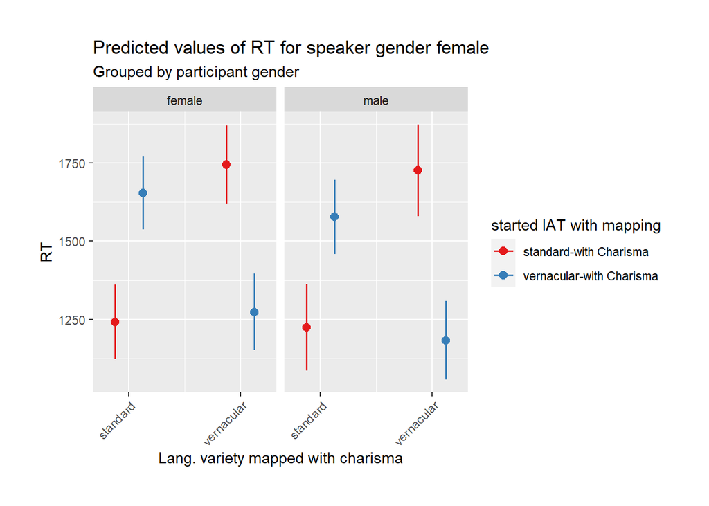

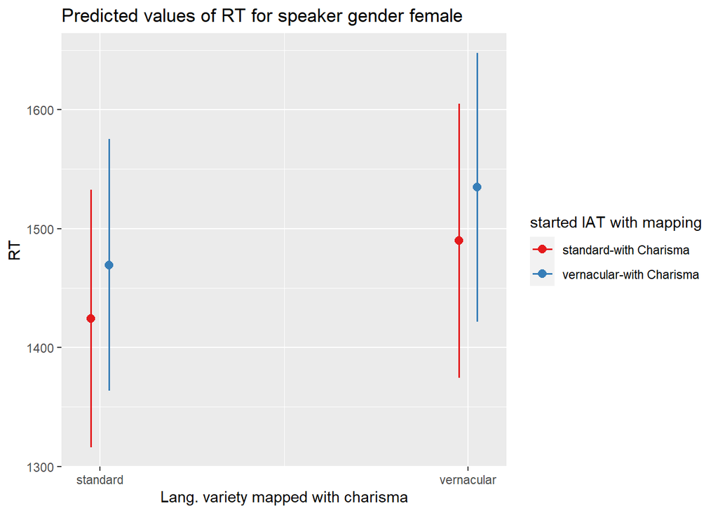

```
## Linear mixed model fit by REML. t-tests use Satterthwaite's method [
## lmerModLmerTest]
## Formula: penal_RTs ~ charisma_lang_var * start_iat * pp_gender + trialcount +
##     age + leadership_lang_var + +stim_cat + (charisma_lang_var |
##     bilendi_id) + (start_iat | stimulus_ID)
##    Data: Four_Out_male
## Control: lmerControl(optimizer = "bobyqa", optCtrl = list(maxfun = 2e+05))
##
## REML criterion at convergence: 512084.6
##
## Scaled residuals:
##     Min      1Q  Median      3Q     Max
## -5.9692 -0.5939 -0.1246  0.5089 12.7851
##
## Random effects:
##  Groups      Name                              Variance Std.Dev. Corr
##  bilendi_id  (Intercept)                       137288   370.52
##              charisma_lang_varvernacular       145677   381.68   -0.28
##  stimulus_ID (Intercept)                        10739   103.63
##              start_iatvernacular-with Charisma   1716    41.42   -0.39
##  Residual                                      366041   605.01
## Number of obs: 32603, groups:  bilendi_id, 272; stimulus_ID, 156
##
## Fixed effects:
##                                                                               Estimate
## (Intercept)                                                                  1857.0910
## charisma_lang_varvernacular                                                   659.1833
## start_iatvernacular-with Charisma                                             533.7743
## pp_gendermale                                                                  85.2991
## trialcount                                                                     -6.0880
## age                                                                            86.7733
## leadership_lang_var2                                                           94.8347
## stim_catleadership                                                            142.8508
## charisma_lang_varvernacular:start_iatvernacular-with Charisma               -1101.7708
## charisma_lang_varvernacular:pp_gendermale                                     -80.7450
## start_iatvernacular-with Charisma:pp_gendermale                               -88.1302
## charisma_lang_varvernacular:start_iatvernacular-with Charisma:pp_gendermale    64.4429
##                                                                             Std. Error
## (Intercept)                                                                    56.0918
## charisma_lang_varvernacular                                                    53.0198
```

[output cut: 75 more lines]

```
## chrsm_ln_:_  0.182 -0.662 -0.152 -0.304  0.000  0.000  0.000  0.000  0.462
## strt_tv-C:_  0.464 -0.148 -0.675 -0.738  0.000 -0.084 -0.072  0.000  0.187
## chr__:_-C:_ -0.134  0.488  0.203  0.224  0.000  0.000  0.000  0.000 -0.620
##             ch__:_ s_-C:_
## chrsm_lng_v
## strt_tvrn-C
## pp_genderml
## trialcount
## age
## ldrshp_ln_2
## stm_ctldrsh
## chrsm__:_-C
## chrsm_ln_:_
## strt_tv-C:_  0.223
## chr__:_-C:_ -0.737 -0.303
```

```
## Type III Analysis of Variance Table with Satterthwaite's method
##                                          Sum Sq   Mean Sq NumDF DenDF  F value
## charisma_lang_var                       4412759   4412759     1   268  12.0554
## start_iat                                361666    361666     1   268   0.9880
## pp_gender                                 51811     51811     1   265   0.1415
## trialcount                            361202436 361202436     1 31914 986.7812
## age                                     6137900   6137900     1   266  16.7683
## leadership_lang_var                     1645363   1645363     1   274   4.4950
## stim_cat                               19481924  19481924     1   135  53.2233
## charisma_lang_var:start_iat           117623889 117623889     1   617 321.3407
## charisma_lang_var:pp_gender              367825    367825     1   268   1.0049
## start_iat:pp_gender                      138888    138888     1   266   0.3794
## charisma_lang_var:start_iat:pp_gender    162196    162196     1   268   0.4431
##                                          Pr(>F)
## charisma_lang_var                     0.0006019 ***
## start_iat                             0.3211151
## pp_gender                             0.7070502
## trialcount                            < 2.2e-16 ***
## age                                   5.608e-05 ***
## leadership_lang_var                   0.0348930 *
## stim_cat                              2.268e-11 ***
## charisma_lang_var:start_iat           < 2.2e-16 ***
## charisma_lang_var:pp_gender           0.3170394
## start_iat:pp_gender                   0.5384350
## charisma_lang_var:start_iat:pp_gender 0.5061983
## ---
## Signif. codes:  0 '***' 0.001 '**' 0.01 '*' 0.05 '.' 0.1 ' ' 1
```

```
## Linear mixed model fit by REML. t-tests use Satterthwaite's method [
## lmerModLmerTest]
## Formula: penal_RTs ~ charisma_lang_var * pp_gender + trialcount + age +
##     leadership_lang_var + +stim_cat + (charisma_lang_var | bilendi_id) +
##     (start_iat | stimulus_ID)
##    Data: Four_Out_male
## Control: lmerControl(optimizer = "bobyqa", optCtrl = list(maxfun = 2e+05))
##
## REML criterion at convergence: 512377.3
##
## Scaled residuals:
##     Min      1Q  Median      3Q     Max
## -6.0468 -0.5927 -0.1262  0.5080 12.6994
##
## Random effects:
##  Groups      Name                              Variance Std.Dev. Corr
##  bilendi_id  (Intercept)                       174053   417.20
##              charisma_lang_varvernacular       329519   574.04   -0.51
##  stimulus_ID (Intercept)                        10767   103.76
##              start_iatvernacular-with Charisma   1710    41.35   -0.40
##  Residual                                      366459   605.36
## Number of obs: 32603, groups:  bilendi_id, 272; stimulus_ID, 156
##
## Fixed effects:
##                                            Estimate Std. Error        df
## (Intercept)                               2011.5242    48.4757  515.7751
## charisma_lang_varvernacular                 63.7705    49.4360  213.4840
## pp_gendermale                               32.5383    51.5215  253.0082
## trialcount                                  -4.9145     0.1735 4838.8035
## age                                         90.1162    21.1908  267.9395
## leadership_lang_var2                        92.2182    44.8252  275.7920
## stim_catleadership                         142.8371    19.5839  135.3101
## charisma_lang_varvernacular:pp_gendermale  -35.3327    70.9299  213.1488
##                                           t value Pr(>|t|)
## (Intercept)                                41.496  < 2e-16 ***
## charisma_lang_varvernacular                 1.290   0.1985
## pp_gendermale                               0.632   0.5283
## trialcount                                -28.331  < 2e-16 ***
## age                                         4.253 2.92e-05 ***
## leadership_lang_var2                        2.057   0.0406 *
## stim_catleadership                          7.294 2.29e-11 ***
## charisma_lang_varvernacular:pp_gendermale  -0.498   0.6189
## ---
## Signif. codes:  0 '***' 0.001 '**' 0.01 '*' 0.05 '.' 0.1 ' ' 1
##
## Correlation of Fixed Effects:
##             (Intr) chrs__ pp_gnd trlcnt age    ldr__2 stm_ct
## chrsm_lng_v -0.398
## pp_genderml -0.514  0.362
## trialcount  -0.429  0.032  0.003
## age          0.033  0.000 -0.026  0.005
## ldrshp_ln_2 -0.387  0.000 -0.010 -0.002  0.037
## stm_ctldrsh -0.296  0.000  0.000  0.001  0.000 -0.004
## chrsm_ln_:_  0.270 -0.696 -0.519 -0.005  0.000  0.000  0.000
```

```
## Type III Analysis of Variance Table with Satterthwaite's method
##                                Sum Sq   Mean Sq NumDF  DenDF  F value    Pr(>F)
## charisma_lang_var              618394    618394     1  213.7   1.6875    0.1953
## pp_gender                       40242     40242     1  267.5   0.1098    0.7406
## trialcount                  294133268 294133268     1 4838.8 802.6356 < 2.2e-16
## age                           6627290   6627290     1  267.9  18.0847 2.922e-05
## leadership_lang_var           1551014   1551014     1  275.8   4.2324    0.0406
## stim_cat                     19494360  19494360     1  135.3  53.1965 2.293e-11
## charisma_lang_var:pp_gender     90932     90932     1  213.1   0.2481    0.6189
##
## charisma_lang_var
## pp_gender
## trialcount                  ***
## age                         ***
## leadership_lang_var         *
## stim_cat                    ***
## charisma_lang_var:pp_gender
## ---
## Signif. codes:  0 '***' 0.001 '**' 0.01 '*' 0.05 '.' 0.1 ' ' 1
```

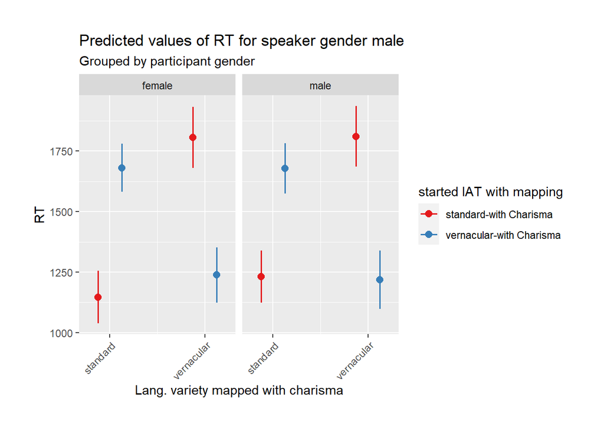

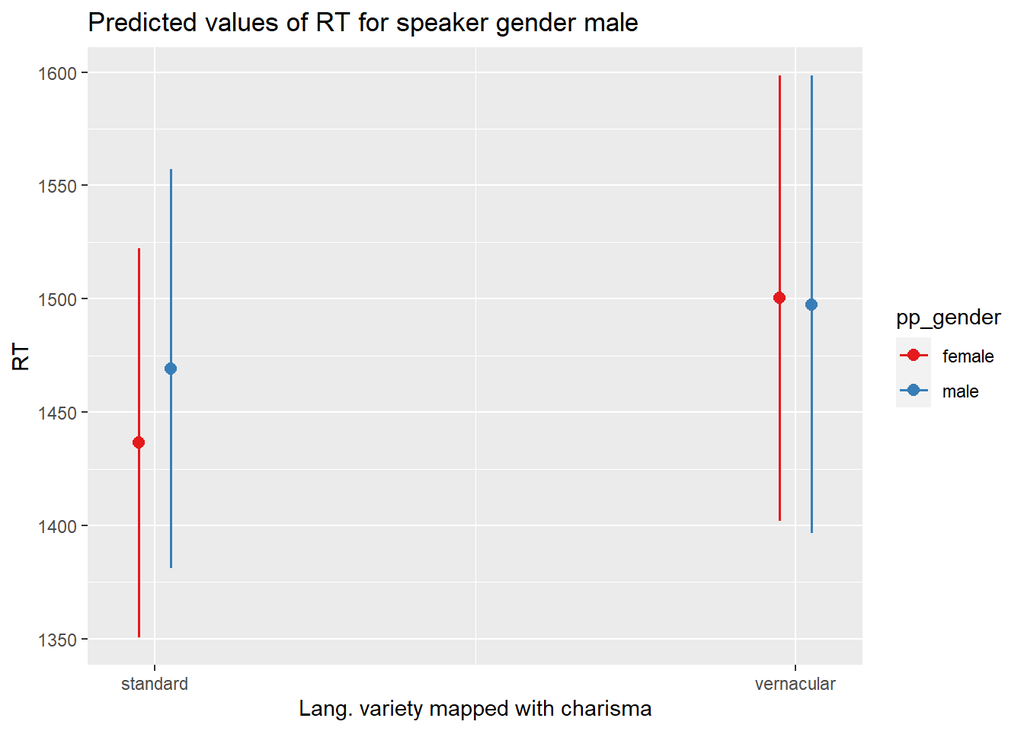

## 2.4. Language variety & political background RQ: Do variables of participants’ political background mediate how language variety impacts on reaction times? ### 2.4.1. GLMs: Max model

```
## Linear mixed model fit by REML. t-tests use Satterthwaite's method [
## lmerModLmerTest]
## Formula: penal_RTs ~ charisma_lang_var * start_iat + trialcount + stim_cat +
##     age + leadership_lang_var + populism_dim:charisma_lang_var +
##     ideology:charisma_lang_var + voting_behaviour:charisma_lang_var +
##     (charisma_lang_var | bilendi_id) + (start_iat | stimulus_ID)
##    Data: Four_Out
## Control: lmerControl(optimizer = "bobyqa", optCtrl = list(maxfun = 2e+05))
##
## REML criterion at convergence: 1003683
##
## Scaled residuals:
##    Min     1Q Median     3Q    Max
## -6.293 -0.620 -0.121  0.548 13.530
##
## Random effects:
##  Groups      Name                              Variance Std.Dev. Corr
##  bilendi_id  (Intercept)                       163919   404.87
##              charisma_lang_varvernacular       112856   335.94   -0.25
##  stimulus_ID (Intercept)                         9062    95.19
##              start_iatvernacular-with Charisma   1030    32.09   -0.35
##  Residual                                      326970   571.81
## Number of obs: 64365, groups:  bilendi_id, 537; stimulus_ID, 303
##
## Fixed effects:
##                                                                 Estimate
## (Intercept)                                                    1907.8045
## charisma_lang_varvernacular                                     506.4787
## start_iatvernacular-with Charisma                               439.3335
## trialcount                                                       -5.7761
## stim_catleadership                                              137.6693
## age                                                              77.6018
## leadership_lang_var2                                             59.4996
## charisma_lang_varvernacular:start_iatvernacular-with Charisma  -980.4612
## charisma_lang_varstandard:populism_dim                          -12.3733
## charisma_lang_varvernacular:populism_dim                         12.8578
## charisma_lang_varstandard:ideology                              -24.8952
## charisma_lang_varvernacular:ideology                            -28.9654
## charisma_lang_varstandard:voting_behaviourandere                -89.1673
## charisma_lang_varvernacular:voting_behaviourandere              -18.9680
```

[output cut: 127 more lines]

```
## charisma_lang_varvernacular:voting_behaviourDIE LINKE
## charisma_lang_varstandard:voting_behaviourFDP
## charisma_lang_varvernacular:voting_behaviourFDP
## charisma_lang_varstandard:voting_behaviourGRüNE
## charisma_lang_varvernacular:voting_behaviourGRüNE
## charisma_lang_varstandard:voting_behaviourinvalid
## charisma_lang_varvernacular:voting_behaviourinvalid
## charisma_lang_varstandard:voting_behaviourNichtwähler
## charisma_lang_varvernacular:voting_behaviourNichtwähler
## charisma_lang_varstandard:voting_behaviourno_answer
## charisma_lang_varvernacular:voting_behaviourno_answer
## charisma_lang_varstandard:voting_behaviourSPD
## charisma_lang_varvernacular:voting_behaviourSPD
## ---
## Signif. codes:  0 '***' 0.001 '**' 0.01 '*' 0.05 '.' 0.1 ' ' 1
```

```
##
## Correlation matrix not shown by default, as p = 30 > 12.
## Use print(x, correlation=TRUE)  or
##     vcov(x)        if you need it
```

```
## Type III Analysis of Variance Table with Satterthwaite's method
##                                       Sum Sq   Mean Sq NumDF DenDF   F value
## charisma_lang_var                      35105     35105     1   524    0.1074
## start_iat                             687434    687434     1   524    2.1024
## trialcount                         641970344 641970344     1 63035 1963.3937
## stim_cat                            36502013  36502013     1   263  111.6373
## age                                  6379296   6379296     1   522   19.5104
## leadership_lang_var                   935802    935802     1   532    2.8620
## charisma_lang_var:start_iat        210700482 210700482     1  1311  644.4036
## charisma_lang_var:populism_dim        771410    385705     2   522    1.1796
## charisma_lang_var:ideology            541383    270691     2   522    0.8279
## charisma_lang_var:voting_behaviour   6062233    336791    18   522    1.0300
##                                       Pr(>F)
## charisma_lang_var                    0.74330
## start_iat                            0.14766
## trialcount                         < 2.2e-16 ***
## stim_cat                           < 2.2e-16 ***
## age                                1.217e-05 ***
## leadership_lang_var                  0.09128 .
## charisma_lang_var:start_iat        < 2.2e-16 ***
## charisma_lang_var:populism_dim       0.30821
## charisma_lang_var:ideology           0.43755
## charisma_lang_var:voting_behaviour   0.42342
## ---
## Signif. codes:  0 '***' 0.001 '**' 0.01 '*' 0.05 '.' 0.1 ' ' 1
```

### 2.4.2. Populism

#### GLMs all data

*no impact of populism measure, populism_all, populism_dim* First, using variable populism_all (mean of populism questionnaire items 1-3)

```
## Linear mixed model fit by REML. t-tests use Satterthwaite's method [
## lmerModLmerTest]
## Formula:
## penal_RTs ~ charisma_lang_var * populism_all + start_iat + trialcount +
##     age + leadership_lang_var + (charisma_lang_var | bilendi_id) +
##     (start_iat | stimulus_ID)
##    Data: Four_Out
## Control: lmerControl(optimizer = "bobyqa", optCtrl = list(maxfun = 2e+05))
##
## REML criterion at convergence: 1004513
##
## Scaled residuals:
##     Min      1Q  Median      3Q     Max
## -6.3944 -0.6195 -0.1255  0.5498 13.4543
##
## Random effects:
##  Groups      Name                              Variance Std.Dev. Corr
##  bilendi_id  (Intercept)                       177992   421.89
##              charisma_lang_varvernacular       261556   511.43   -0.36
##  stimulus_ID (Intercept)                        11744   108.37
##              start_iatvernacular-with Charisma   1077    32.81   -0.05
##  Residual                                      327354   572.15
## Number of obs: 64365, groups:  bilendi_id, 537; stimulus_ID, 303
##
## Fixed effects:
##                                           Estimate Std. Error        df t value
## (Intercept)                              2022.8101    33.1269  651.4850  61.062
## charisma_lang_varvernacular                39.6539    22.5435  411.5677   1.759
## populism_all                              -12.9281    18.5101  409.5434  -0.698
## start_iatvernacular-with Charisma          99.6153    34.7606  542.4536   2.866
## trialcount                                 -4.6195     0.1158 8462.3535 -39.905
## age                                        77.9038    17.1946  531.9939   4.531
## leadership_lang_var2                       70.9889    34.9206  542.9553   2.033
## charisma_lang_varvernacular:populism_all   15.1702    22.5436  410.6855   0.673
##                                          Pr(>|t|)
## (Intercept)                               < 2e-16 ***
## charisma_lang_varvernacular               0.07932 .
## populism_all                              0.48530
## start_iatvernacular-with Charisma         0.00432 **
## trialcount                                < 2e-16 ***
## age                                      7.26e-06 ***
## leadership_lang_var2                      0.04255 *
## charisma_lang_varvernacular:populism_all  0.50137
## ---
## Signif. codes:  0 '***' 0.001 '**' 0.01 '*' 0.05 '.' 0.1 ' ' 1
##
## Correlation of Fixed Effects:
##             (Intr) chrs__ pplsm_ str_-C trlcnt age    ldr__2
## chrsm_lng_v -0.220
## populism_ll  0.001 -0.001
## strt_tvrn-C -0.526 -0.004  0.001
## trialcount  -0.350  0.037  0.000 -0.117
## age         -0.027  0.000  0.035  0.023  0.000
## ldrshp_ln_2 -0.462  0.000 -0.001  0.021  0.000  0.033
## chrsm_ln_:_  0.000  0.002 -0.371  0.000  0.000  0.000  0.000
```

```
## Type III Analysis of Variance Table with Satterthwaite's method
##                                   Sum Sq   Mean Sq NumDF  DenDF   F value
## charisma_lang_var                1012856   1012856     1  411.6    3.0941
## populism_all                       29684     29684     1  464.3    0.0907
## start_iat                        2688411   2688411     1  542.5    8.2125
## trialcount                     521292785 521292785     1 8462.4 1592.4419
## age                              6719707   6719707     1  532.0   20.5273
## leadership_lang_var              1352809   1352809     1  543.0    4.1326
## charisma_lang_var:populism_all    148237    148237     1  410.7    0.4528
##                                   Pr(>F)
## charisma_lang_var               0.079321 .
## populism_all                    0.763452
## start_iat                       0.004322 **
## trialcount                     < 2.2e-16 ***
## age                            7.264e-06 ***
## leadership_lang_var             0.042552 *
## charisma_lang_var:populism_all  0.501372
## ---
## Signif. codes:  0 '***' 0.001 '**' 0.01 '*' 0.05 '.' 0.1 ' ' 1
```

Second, using variable populism_dim (dimension 1 of Populism PCA)

```
## Linear mixed model fit by REML. t-tests use Satterthwaite's method [
## lmerModLmerTest]
## Formula:
## penal_RTs ~ charisma_lang_var * populism_dim + trialcount + start_iat +
##     age + leadership_lang_var + (charisma_lang_var | bilendi_id) +
##     (start_iat | stimulus_ID)
##    Data: Four_Out
## Control: lmerControl(optimizer = "bobyqa", optCtrl = list(maxfun = 2e+05))
##
## REML criterion at convergence: 1004512
##
## Scaled residuals:
##     Min      1Q  Median      3Q     Max
## -6.3945 -0.6195 -0.1254  0.5500 13.4546
##
## Random effects:
##  Groups      Name                              Variance Std.Dev. Corr
##  bilendi_id  (Intercept)                       177699   421.54
##              charisma_lang_varvernacular       261435   511.31   -0.36
##  stimulus_ID (Intercept)                        11744   108.37
##              start_iatvernacular-with Charisma   1077    32.81   -0.05
##  Residual                                      327355   572.15
## Number of obs: 64365, groups:  bilendi_id, 537; stimulus_ID, 303
##
## Fixed effects:
##                                           Estimate Std. Error        df t value
## (Intercept)                              2022.2775    33.1085  651.4373  61.080
## charisma_lang_varvernacular                39.6544    22.5385  411.5109   1.759
## populism_dim                              -18.7006    18.5059  410.5283  -1.011
## trialcount                                 -4.6192     0.1158 8456.0413 -39.904
## start_iatvernacular-with Charisma         100.3456    34.7518  542.5292   2.887
## age                                        77.3454    17.2104  531.9695   4.494
## leadership_lang_var2                       71.2151    34.9097  542.9550   2.040
## charisma_lang_varvernacular:populism_dim   18.1103    22.5260  410.6288   0.804
##                                          Pr(>|t|)
## (Intercept)                               < 2e-16 ***
## charisma_lang_varvernacular               0.07925 .
## populism_dim                              0.31284
## trialcount                                < 2e-16 ***
## start_iatvernacular-with Charisma         0.00404 **
## age                                      8.58e-06 ***
## leadership_lang_var2                      0.04184 *
## charisma_lang_varvernacular:populism_dim  0.42188
## ---
## Signif. codes:  0 '***' 0.001 '**' 0.01 '*' 0.05 '.' 0.1 ' ' 1
##
## Correlation of Fixed Effects:
##             (Intr) chrs__ pplsm_ trlcnt str_-C age    ldr__2
## chrsm_lng_v -0.219
## populism_dm  0.002 -0.001
## trialcount  -0.350  0.037  0.000
## strt_tvrn-C -0.526 -0.004  0.003 -0.118
## age         -0.027  0.000  0.058  0.000  0.023
## ldrshp_ln_2 -0.463  0.000 -0.006  0.000  0.021  0.033
## chrsm_ln_:_  0.000  0.002 -0.370 -0.001  0.000  0.000  0.000
```

```
## Type III Analysis of Variance Table with Satterthwaite's method
##                                   Sum Sq   Mean Sq NumDF  DenDF   F value
## charisma_lang_var                1013330   1013330     1  411.5    3.0955
## populism_dim                       96608     96608     1  464.1    0.2951
## trialcount                     521269224 521269224     1 8456.0 1592.3687
## start_iat                        2729354   2729354     1  542.5    8.3376
## age                              6611582   6611582     1  532.0   20.1970
## leadership_lang_var              1362288   1362288     1  543.0    4.1615
## charisma_lang_var:populism_dim    211595    211595     1  410.6    0.6464
##                                   Pr(>F)
## charisma_lang_var               0.079252 .
## populism_dim                    0.587221
## trialcount                     < 2.2e-16 ***
## start_iat                       0.004038 **
## age                            8.578e-06 ***
## leadership_lang_var             0.041836 *
## charisma_lang_var:populism_dim  0.421876
## ---
## Signif. codes:  0 '***' 0.001 '**' 0.01 '*' 0.05 '.' 0.1 ' ' 1
```

```
## Linear mixed model fit by REML. t-tests use Satterthwaite's method [
## lmerModLmerTest]
## Formula: penal_RTs ~ charisma_lang_var * start_iat * populism4 + trialcount +
##     age + leadership_lang_var + (charisma_lang_var | bilendi_id) +
##     (start_iat | stimulus_ID)
##    Data: Four_Out
## Control: lmerControl(optimizer = "bobyqa", optCtrl = list(maxfun = 2e+05))
##
## REML criterion at convergence: 1003981
##
## Scaled residuals:
##     Min      1Q  Median      3Q     Max
## -6.2816 -0.6200 -0.1219  0.5502 13.5464
##
## Random effects:
##  Groups      Name                              Variance Std.Dev. Corr
##  bilendi_id  (Intercept)                       162854   403.55
##              charisma_lang_varvernacular       113308   336.61   -0.24
##  stimulus_ID (Intercept)                        11733   108.32
##              start_iatvernacular-with Charisma   1060    32.55   -0.05
##  Residual                                      326951   571.80
## Number of obs: 64365, groups:  bilendi_id, 537; stimulus_ID, 303
##
## Fixed effects:
##                                                                           Estimate
## (Intercept)                                                              1977.8603
## charisma_lang_varvernacular                                               560.5160
## start_iatvernacular-with Charisma                                         438.3174
## populism4                                                                 -62.3113
## trialcount                                                                 -5.7766
## age                                                                        72.8269
## leadership_lang_var2                                                       71.0831
## charisma_lang_varvernacular:start_iatvernacular-with Charisma            -979.9759
## charisma_lang_varvernacular:populism4                                      13.4617
## start_iatvernacular-with Charisma:populism4                                64.7042
## charisma_lang_varvernacular:start_iatvernacular-with Charisma:populism4     3.7425
##                                                                         Std. Error
## (Intercept)                                                                32.2482
## charisma_lang_varvernacular                                                25.3145
## start_iatvernacular-with Charisma                                          37.4903
```

[output cut: 67 more lines]

```
## chrsm__:_-C -0.051 -0.799 -0.385 -0.001  0.609  0.000  0.000
## chrsm_ln_:4  0.001 -0.006 -0.001 -0.257  0.000  0.000  0.000  0.004
## strt_tv-C:4  0.011 -0.001 -0.003 -0.746  0.000 -0.088 -0.012  0.000    0.192
## chr__:_-C:4 -0.001  0.004  0.000  0.191  0.000  0.000  0.000 -0.001   -0.743
##             s_-C:4
## chrsm_lng_v
## strt_tvrn-C
## populism4
## trialcount
## age
## ldrshp_ln_2
## chrsm__:_-C
## chrsm_ln_:4
## strt_tv-C:4
## chr__:_-C:4 -0.258
```

```
## Type III Analysis of Variance Table with Satterthwaite's method
##                                          Sum Sq   Mean Sq NumDF DenDF   F value
## charisma_lang_var                       6982262   6982262     1   533   21.3557
## start_iat                                715672    715672     1   533    2.1889
## populism4                                525734    525734     1   530    1.6080
## trialcount                            641957800 641957800     1 63022 1963.4683
## age                                     5803076   5803076     1   531   17.7491
## leadership_lang_var                     1363920   1363920     1   542    4.1716
## charisma_lang_var:start_iat           211825773 211825773     1  1344  647.8824
## charisma_lang_var:populism4              328369    328369     1   533    1.0043
## start_iat:populism4                     1177962   1177962     1   530    3.6029
## charisma_lang_var:start_iat:populism4      4891      4891     1   533    0.0150
##                                          Pr(>F)
## charisma_lang_var                     4.791e-06 ***
## start_iat                               0.13960
## populism4                               0.20533
## trialcount                            < 2.2e-16 ***
## age                                   2.961e-05 ***
## leadership_lang_var                     0.04159 *
## charisma_lang_var:start_iat           < 2.2e-16 ***
## charisma_lang_var:populism4             0.31672
## start_iat:populism4                     0.05822 .
## charisma_lang_var:start_iat:populism4   0.90270
## ---
## Signif. codes:  0 '***' 0.001 '**' 0.01 '*' 0.05 '.' 0.1 ' ' 1
```

#### Populism subset analyes

difference between 2nd blocks (charisma_lang_var*start_iat), i.e.impact of vernacular when starting with standard-with Charisma vs. impact of standard variety when starting with vernacular-with Charisma) is significant in low populism subset but not significant in high populism subset

```
## Linear mixed model fit by REML. t-tests use Satterthwaite's method [
## lmerModLmerTest]
## Formula: penal_RTs ~ charisma_lang_var * start_iat + trialcount + age +
##     leadership_lang_var + (charisma_lang_var | bilendi_id) +
##     (start_iat | stimulus_ID)
##    Data: Four_Out_high_pop
## Control: lmerControl(optimizer = "bobyqa", optCtrl = list(maxfun = 2e+05))
##
## REML criterion at convergence: 534715
##
## Scaled residuals:
##     Min      1Q  Median      3Q     Max
## -6.3516 -0.6123 -0.1105  0.5567 13.5692
##
## Random effects:
##  Groups      Name                              Variance Std.Dev. Corr
##  stimulus_ID (Intercept)                        11423   106.88
##              start_iatvernacular-with Charisma   2523    50.23   -0.05
##  bilendi_id  (Intercept)                       195640   442.31
##              charisma_lang_varvernacular       126365   355.48   -0.16
##  Residual                                      325913   570.89
## Number of obs: 34272, groups:  stimulus_ID, 303; bilendi_id, 286
##
## Fixed effects:
##                                                                 Estimate
## (Intercept)                                                    1949.7445
## charisma_lang_varvernacular                                     549.2752
## start_iatvernacular-with Charisma                               431.0809
## trialcount                                                       -5.4238
## age                                                              60.9432
## leadership_lang_var2                                             42.9332
## charisma_lang_varvernacular:start_iatvernacular-with Charisma  -935.7622
##                                                               Std. Error
## (Intercept)                                                      47.9691
## charisma_lang_varvernacular                                      36.0411
## start_iatvernacular-with Charisma                                55.7078
## trialcount                                                        0.1786
## age                                                              26.1000
## leadership_lang_var2                                             52.8197
## charisma_lang_varvernacular:start_iatvernacular-with Charisma    54.4602
```

[output cut: 20 more lines]

```
## trialcount                                                    ***
## age                                                           *
## leadership_lang_var2
## charisma_lang_varvernacular:start_iatvernacular-with Charisma ***
## ---
## Signif. codes:  0 '***' 0.001 '**' 0.01 '*' 0.05 '.' 0.1 ' ' 1
##
## Correlation of Fixed Effects:
##             (Intr) chrs__ str_-C trlcnt age    ldr__2
## chrsm_lng_v -0.014
## strt_tvrn-C -0.511  0.241
## trialcount  -0.262 -0.446 -0.289
## age         -0.014  0.000  0.020  0.000
## ldrshp_ln_2 -0.501  0.000  0.031  0.000  0.003
## chrsm__:_-C -0.068 -0.793 -0.309  0.590  0.000  0.000
```

```
## Type III Analysis of Variance Table with Satterthwaite's method
##                                Sum Sq   Mean Sq NumDF DenDF  F value    Pr(>F)
## charisma_lang_var             4469825   4469825     1   284  13.7148 0.0002557
## start_iat                      151798    151798     1   283   0.4658 0.4955013
## trialcount                  300533567 300533567     1 33476 922.1280 < 2.2e-16
## age                           1776932   1776932     1   282   5.4522 0.0202455
## leadership_lang_var            215326    215326     1   286   0.6607 0.4169944
## charisma_lang_var:start_iat  96221810  96221810     1   667 295.2376 < 2.2e-16
##
## charisma_lang_var           ***
## start_iat
## trialcount                  ***
## age                         *
## leadership_lang_var
## charisma_lang_var:start_iat ***
## ---
## Signif. codes:  0 '***' 0.001 '**' 0.01 '*' 0.05 '.' 0.1 ' ' 1
```

```
## Note: D.f. calculations have been disabled because the number of observations exceeds 3000.
## To enable adjustments, add the argument 'pbkrtest.limit = 34272' (or larger)
## [or, globally, 'set emm_options(pbkrtest.limit = 34272)' or larger];
## but be warned that this may result in large computation time and memory use.
```

```
## Note: D.f. calculations have been disabled because the number of observations exceeds 3000.
## To enable adjustments, add the argument 'lmerTest.limit = 34272' (or larger)
## [or, globally, 'set emm_options(lmerTest.limit = 34272)' or larger];
## but be warned that this may result in large computation time and memory use.
```

```
## $emmeans
##  charisma_lang_var start_iat                emmean   SE  df asymp.LCL asymp.UCL
##  standard          standard-with Charisma     1345 40.4 Inf      1266      1424
##  vernacular        standard-with Charisma     1894 47.1 Inf      1802      1987
##  standard          vernacular-with Charisma   1776 37.9 Inf      1702      1850
##  vernacular        vernacular-with Charisma   1389 44.0 Inf      1303      1476
##
## Results are averaged over the levels of: leadership_lang_var
## Degrees-of-freedom method: asymptotic
## Confidence level used: 0.95
##
## $contrasts
##  contrast
##  (standard standard-with Charisma) - (vernacular standard-with Charisma)
##  (standard standard-with Charisma) - (standard vernacular-with Charisma)
##  (standard standard-with Charisma) - (vernacular vernacular-with Charisma)
##  (vernacular standard-with Charisma) - (standard vernacular-with Charisma)
##  (vernacular standard-with Charisma) - (vernacular vernacular-with Charisma)
##  (standard vernacular-with Charisma) - (vernacular vernacular-with Charisma)
##  estimate   SE  df z.ratio p.value
##    -549.3 36.0 Inf -15.240  <.0001
##    -431.1 55.7 Inf  -7.738  <.0001
##     -44.6 57.9 Inf  -0.771  0.8677
##     118.2 58.6 Inf   2.017  0.1815
##     504.7 64.8 Inf   7.792  <.0001
##     386.5 33.9 Inf  11.396  <.0001
##
## Results are averaged over the levels of: leadership_lang_var
## Degrees-of-freedom method: asymptotic
## P value adjustment: tukey method for comparing a family of 4 estimates
```

```
## Linear mixed model fit by REML. t-tests use Satterthwaite's method [
## lmerModLmerTest]
## Formula: penal_RTs ~ charisma_lang_var * start_iat + trialcount + age +
##     leadership_lang_var + (charisma_lang_var | bilendi_id) +
##     (start_iat | stimulus_ID)
##    Data: Four_Out_low_pop
## Control: lmerControl(optimizer = "bobyqa", optCtrl = list(maxfun = 2e+05))
##
## REML criterion at convergence: 469463.9
##
## Scaled residuals:
##     Min      1Q  Median      3Q     Max
## -4.8443 -0.6288 -0.1344  0.5461 12.3934
##
## Random effects:
##  Groups      Name                              Variance Std.Dev. Corr
##  stimulus_ID (Intercept)                        13299.6 115.3
##              start_iatvernacular-with Charisma    829.6  28.8    -0.01
##  bilendi_id  (Intercept)                       129012.9 359.2
##              charisma_lang_varvernacular        98787.6 314.3    -0.36
##  Residual                                      327264.8 572.1
## Number of obs: 30093, groups:  stimulus_ID, 303; bilendi_id, 251
##
## Fixed effects:
##                                                                Estimate
## (Intercept)                                                    2010.629
## charisma_lang_varvernacular                                     573.916
## start_iatvernacular-with Charisma                               447.593
## trialcount                                                       -6.174
## age                                                              96.522
## leadership_lang_var2                                             87.743
## charisma_lang_varvernacular:start_iatvernacular-with Charisma -1030.735
##                                                               Std. Error
## (Intercept)                                                       41.681
## charisma_lang_varvernacular                                       35.357
## start_iatvernacular-with Charisma                                 49.592
## trialcount                                                         0.191
## age                                                               21.457
## leadership_lang_var2                                              43.819
## charisma_lang_varvernacular:start_iatvernacular-with Charisma     54.255
```

[output cut: 12 more lines]

```
## trialcount                                                     < 2e-16 ***
## age                                                           1.05e-05 ***
## leadership_lang_var2                                            0.0463 *
## charisma_lang_varvernacular:start_iatvernacular-with Charisma  < 2e-16 ***
## ---
## Signif. codes:  0 '***' 0.001 '**' 0.01 '*' 0.05 '.' 0.1 ' ' 1
##
## Correlation of Fixed Effects:
##             (Intr) chrs__ str_-C trlcnt age    ldr__2
## chrsm_lng_v -0.116
## strt_tvrn-C -0.457  0.398
## trialcount  -0.323 -0.486 -0.346
## age         -0.041  0.000  0.021  0.000
## ldrshp_ln_2 -0.441  0.000  0.006  0.000  0.064
## chrsm__:_-C -0.027 -0.806 -0.496  0.633  0.000  0.000
```

```
## Type III Analysis of Variance Table with Satterthwaite's method
##                                Sum Sq   Mean Sq NumDF   DenDF   F value
## charisma_lang_var             2546445   2546445     1   248.9    7.7810
## start_iat                      807584    807584     1   247.4    2.4677
## trialcount                  342104329 342104329     1 29375.7 1045.3440
## age                           6622402   6622402     1   246.9   20.2356
## leadership_lang_var           1312206   1312206     1   253.0    4.0096
## charisma_lang_var:start_iat 118119183 118119183     1   691.7  360.9284
##                                Pr(>F)
## charisma_lang_var            0.005688 **
## start_iat                    0.117488
## trialcount                  < 2.2e-16 ***
## age                         1.055e-05 ***
## leadership_lang_var          0.046309 *
## charisma_lang_var:start_iat < 2.2e-16 ***
## ---
## Signif. codes:  0 '***' 0.001 '**' 0.01 '*' 0.05 '.' 0.1 ' ' 1
```

```
## Note: D.f. calculations have been disabled because the number of observations exceeds 3000.
## To enable adjustments, add the argument 'pbkrtest.limit = 30093' (or larger)
## [or, globally, 'set emm_options(pbkrtest.limit = 30093)' or larger];
## but be warned that this may result in large computation time and memory use.
```

```
## Note: D.f. calculations have been disabled because the number of observations exceeds 3000.
## To enable adjustments, add the argument 'lmerTest.limit = 30093' (or larger)
## [or, globally, 'set emm_options(lmerTest.limit = 30093)' or larger];
## but be warned that this may result in large computation time and memory use.
```

```
## $emmeans
##  charisma_lang_var start_iat                emmean   SE  df asymp.LCL asymp.UCL
##  standard          standard-with Charisma     1341 36.1 Inf      1271      1412
##  vernacular        standard-with Charisma     1915 38.1 Inf      1841      1990
##  standard          vernacular-with Charisma   1789 33.6 Inf      1723      1855
##  vernacular        vernacular-with Charisma   1332 35.4 Inf      1263      1402
##
## Results are averaged over the levels of: leadership_lang_var
## Degrees-of-freedom method: asymptotic
## Confidence level used: 0.95
##
## $contrasts
##  contrast
##  (standard standard-with Charisma) - (vernacular standard-with Charisma)
##  (standard standard-with Charisma) - (standard vernacular-with Charisma)
##  (standard standard-with Charisma) - (vernacular vernacular-with Charisma)
##  (vernacular standard-with Charisma) - (standard vernacular-with Charisma)
##  (vernacular standard-with Charisma) - (vernacular vernacular-with Charisma)
##  (standard vernacular-with Charisma) - (vernacular vernacular-with Charisma)
##  estimate   SE  df z.ratio p.value
##   -573.92 35.4 Inf -16.232  <.0001
##   -447.59 49.6 Inf  -9.026  <.0001
##      9.23 47.9 Inf   0.193  0.9975
##    126.32 48.1 Inf   2.626  0.0429
##    583.14 52.3 Inf  11.150  <.0001
##    456.82 33.2 Inf  13.756  <.0001
##
## Results are averaged over the levels of: leadership_lang_var
## Degrees-of-freedom method: asymptotic
## P value adjustment: tukey method for comparing a family of 4 estimates
```

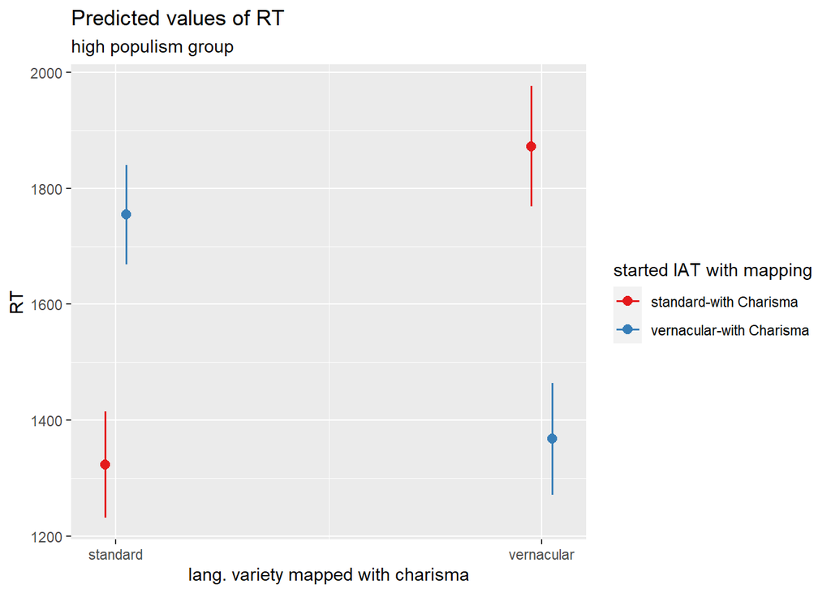

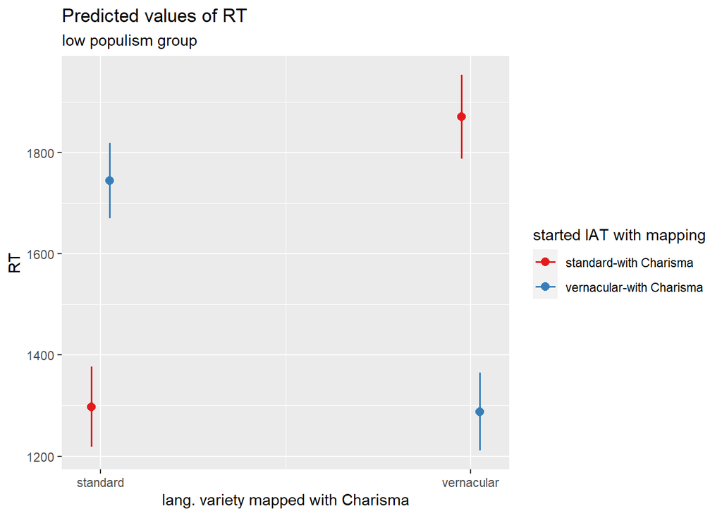

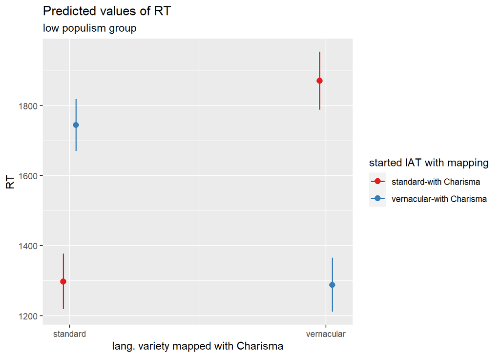

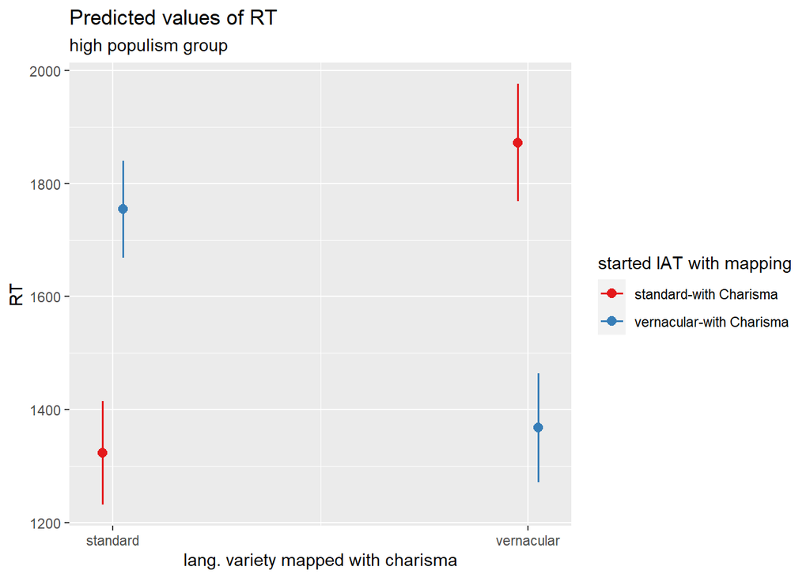

#### Populism & gender Does gender impact on how populism mediates the effect of language variety on RTs?

##### outgroup data

*no impact of stimuli speaker/participant gender in complete data set with neither populism measure* First, variable populism_all (mean of populism items 1-3)

```
## Linear mixed model fit by REML. t-tests use Satterthwaite's method [
## lmerModLmerTest]
## Formula: penal_RTs ~ charisma_lang_var * populism_all * speaker_gender +
##     start_iat + trialcount + age + +leadership_lang_var + (charisma_lang_var |
##     bilendi_id) + (start_iat | stimulus_ID)
##    Data: Four_Out
## Control: lmerControl(optimizer = "bobyqa", optCtrl = list(maxfun = 2e+05))
##
## REML criterion at convergence: 1004472
##
## Scaled residuals:
##     Min      1Q  Median      3Q     Max
## -6.3956 -0.6195 -0.1258  0.5499 13.4536
##
## Random effects:
##  Groups      Name                              Variance Std.Dev. Corr
##  bilendi_id  (Intercept)                       178461   422.45
##              charisma_lang_varvernacular       262737   512.58   -0.36
##  stimulus_ID (Intercept)                        11735   108.33
##              start_iatvernacular-with Charisma   1077    32.82   -0.05
##  Residual                                      327352   572.15
## Number of obs: 64365, groups:  bilendi_id, 537; stimulus_ID, 303
##
## Fixed effects:
##                                                              Estimate
## (Intercept)                                                 1994.3777
## charisma_lang_varvernacular                                   30.7021
## populism_all                                                 -11.7761
## speaker_gendermale                                            60.4416
## start_iatvernacular-with Charisma                             96.3662
## trialcount                                                    -4.6233
## age                                                           80.5224
## leadership_lang_var2                                          71.0703
## charisma_lang_varvernacular:populism_all                      19.7017
## charisma_lang_varvernacular:speaker_gendermale                17.9621
## populism_all:speaker_gendermale                               -4.2191
## charisma_lang_varvernacular:populism_all:speaker_gendermale  -10.5382
##                                                             Std. Error
## (Intercept)                                                    38.6246
## charisma_lang_varvernacular                                    32.1661
```

[output cut: 49 more lines]

```
## chrsm_lng_vrvrnclr:s_  0.182 -0.711  0.009 -0.355  0.000  0.004  0.000  0.000
## pplsm_ll:s_           -0.006  0.009 -0.677 -0.001 -0.003 -0.001 -0.017 -0.021
## chrsm__:_:_            0.006 -0.023  0.255  0.000  0.000  0.001  0.000  0.000
##                       chrsm_lng_vrvrnclr:p_ chrsm_lng_vrvrnclr:s_ ppl_:_
## chrsm_lng_v
## populism_ll
## spkr_gndrml
## strt_tvrn-C
## trialcount
## age
## ldrshp_ln_2
## chrsm_lng_vrvrnclr:p_
## chrsm_lng_vrvrnclr:s_ -0.025
## pplsm_ll:s_            0.255                 0.000
## chrsm__:_:_           -0.677                 0.000                -0.376
```

```
## Type III Analysis of Variance Table with Satterthwaite's method
##                                                  Sum Sq   Mean Sq NumDF  DenDF
## charisma_lang_var                               1008680   1008680     1  410.3
## populism_all                                      46083     46083     1  464.6
## speaker_gender                                  1108261   1108261     1  575.7
## start_iat                                       2521757   2521757     1  540.9
## trialcount                                    521664942 521664942     1 8490.2
## age                                             7147530   7147530     1  529.9
## leadership_lang_var                             1357761   1357761     1  541.6
## charisma_lang_var:populism_all                   132527    132527     1  409.4
## charisma_lang_var:speaker_gender                  51734     51734     1  409.4
## populism_all:speaker_gender                       23325     23325     1  464.5
## charisma_lang_var:populism_all:speaker_gender     17664     17664     1  409.4
##                                                 F value    Pr(>F)
## charisma_lang_var                                3.0813  0.079942 .
## populism_all                                     0.1408  0.707682
## speaker_gender                                   3.3855  0.066285 .
## start_iat                                        7.7035  0.005702 **
## trialcount                                    1593.5926 < 2.2e-16 ***
## age                                             21.8344 3.774e-06 ***
## leadership_lang_var                              4.1477  0.042177 *
## charisma_lang_var:populism_all                   0.4048  0.524952
## charisma_lang_var:speaker_gender                 0.1580  0.691176
## populism_all:speaker_gender                      0.0713  0.789639
## charisma_lang_var:populism_all:speaker_gender    0.0540  0.816426
## ---
## Signif. codes:  0 '***' 0.001 '**' 0.01 '*' 0.05 '.' 0.1 ' ' 1
```

Second, variable populism_dim (first PC dimension reduction)

```
## Linear mixed model fit by REML. t-tests use Satterthwaite's method [
## lmerModLmerTest]
## Formula: penal_RTs ~ charisma_lang_var * populism_dim * speaker_gender +
##     start_iat + trialcount + age + +leadership_lang_var + (charisma_lang_var |
##     bilendi_id) + (start_iat | stimulus_ID)
##    Data: Four_Out
## Control: lmerControl(optimizer = "bobyqa", optCtrl = list(maxfun = 2e+05))
##
## REML criterion at convergence: 1004471
##
## Scaled residuals:
##     Min      1Q  Median      3Q     Max
## -6.3957 -0.6195 -0.1256  0.5500 13.4541
##
## Random effects:
##  Groups      Name                              Variance Std.Dev. Corr
##  bilendi_id  (Intercept)                       177981   421.88
##              charisma_lang_varvernacular       262638   512.48   -0.36
##  stimulus_ID (Intercept)                        11735   108.33
##              start_iatvernacular-with Charisma   1077    32.82   -0.05
##  Residual                                      327352   572.15
## Number of obs: 64365, groups:  bilendi_id, 537; stimulus_ID, 303
##
## Fixed effects:
##                                                              Estimate
## (Intercept)                                                 1993.5262
## charisma_lang_varvernacular                                   30.8382
## populism_dim                                                  -9.5116
## speaker_gendermale                                            60.8821
## start_iatvernacular-with Charisma                             97.5625
## trialcount                                                    -4.6232
## age                                                           79.9594
## leadership_lang_var2                                          71.7610
## charisma_lang_varvernacular:populism_dim                      21.7520
## charisma_lang_varvernacular:speaker_gendermale                17.6620
## populism_dim:speaker_gendermale                              -22.1211
## charisma_lang_varvernacular:populism_dim:speaker_gendermale   -8.7703
##                                                             Std. Error
## (Intercept)                                                    38.5852
## charisma_lang_varvernacular                                    32.1630
```

[output cut: 49 more lines]

```
## chrsm_lng_vrvrnclr:s_  0.181 -0.711  0.010 -0.354  0.000  0.004  0.000  0.000
## pplsm_dm:s_           -0.002  0.009 -0.672 -0.002 -0.012 -0.002 -0.006 -0.022
## chrsm__:_:_            0.005 -0.025  0.252  0.000 -0.001  0.006  0.000  0.000
##                       chrsm_lng_vrvrnclr:p_ chrsm_lng_vrvrnclr:s_ ppl_:_
## chrsm_lng_v
## populism_dm
## spkr_gndrml
## strt_tvrn-C
## trialcount
## age
## ldrshp_ln_2
## chrsm_lng_vrvrnclr:p_
## chrsm_lng_vrvrnclr:s_ -0.026
## pplsm_dm:s_            0.252                 0.001
## chrsm__:_:_           -0.672                -0.001                -0.375
```

```
## Type III Analysis of Variance Table with Satterthwaite's method
##                                                  Sum Sq   Mean Sq NumDF  DenDF
## charisma_lang_var                               1008119   1008119     1  410.2
## populism_dim                                     145986    145986     1  464.2
## speaker_gender                                  1118209   1118209     1  574.8
## start_iat                                       2587990   2587990     1  541.0
## trialcount                                    521653892 521653892     1 8487.2
## age                                             7044508   7044508     1  529.9
## leadership_lang_var                             1386299   1386299     1  541.6
## charisma_lang_var:populism_dim                   191684    191684     1  409.4
## charisma_lang_var:speaker_gender                  50027     50027     1  409.4
## populism_dim:speaker_gender                      181902    181902     1  463.7
## charisma_lang_var:populism_dim:speaker_gender     12221     12221     1  409.4
##                                                 F value    Pr(>F)
## charisma_lang_var                                3.0796  0.080025 .
## populism_dim                                     0.4460  0.504591
## speaker_gender                                   3.4159  0.065084 .
## start_iat                                        7.9058  0.005106 **
## trialcount                                    1593.5585 < 2.2e-16 ***
## age                                             21.5197 4.418e-06 ***
## leadership_lang_var                              4.2349  0.040079 *
## charisma_lang_var:populism_dim                   0.5856  0.444582
## charisma_lang_var:speaker_gender                 0.1528  0.696056
## populism_dim:speaker_gender                      0.5557  0.456384
## charisma_lang_var:populism_dim:speaker_gender    0.0373  0.846887
## ---
## Signif. codes:  0 '***' 0.001 '**' 0.01 '*' 0.05 '.' 0.1 ' ' 1
```

##### Subset analyses

###### low populism & speaker gender

no impact of gender stimuli speaker in populism subset (low) & populism_all/ populism_dim

```
## Linear mixed model fit by REML. t-tests use Satterthwaite's method [
## lmerModLmerTest]
## Formula: penal_RTs ~ charisma_lang_var * populism_all * speaker_gender +
##     start_iat + trialcount + age + pp_gender + leadership_lang_var +
##     (charisma_lang_var | bilendi_id) + (start_iat | stimulus_ID)
##    Data: Four_Out_low_pop
## Control: lmerControl(optimizer = "bobyqa", optCtrl = list(maxfun = 2e+05))
##
## REML criterion at convergence: 469653.8
##
## Scaled residuals:
##     Min      1Q  Median      3Q     Max
## -4.9122 -0.6278 -0.1382  0.5464 12.4006
##
## Random effects:
##  Groups      Name                              Variance Std.Dev. Corr
##  stimulus_ID (Intercept)                        13322.6 115.42
##              start_iatvernacular-with Charisma    904.7  30.08   -0.03
##  bilendi_id  (Intercept)                       156930.4 396.14
##              charisma_lang_varvernacular       266478.4 516.22   -0.55
##  Residual                                      327689.8 572.44
## Number of obs: 30093, groups:  stimulus_ID, 303; bilendi_id, 251
##
## Fixed effects:
##                                                              Estimate
## (Intercept)                                                 2167.3595
## charisma_lang_varvernacular                                    6.4828
## populism_all                                                 -39.7752
## speaker_gendermale                                            54.9527
## start_iatvernacular-with Charisma                             -0.2239
## trialcount                                                    -4.9734
## age                                                           94.1380
## pp_genderfemale                                              -61.2578
## pp_gendermale                                               -109.2994
## leadership_lang_var2                                          86.3108
## charisma_lang_varvernacular:populism_all                      27.0222
## charisma_lang_varvernacular:speaker_gendermale                38.6683
## populism_all:speaker_gendermale                              -45.4736
## charisma_lang_varvernacular:populism_all:speaker_gendermale  -26.2757
##                                                             Std. Error
```

[output cut: 31 more lines]

```
## charisma_lang_varvernacular                                    0.890
## populism_all                                                   0.261
## speaker_gendermale                                             0.304
## start_iatvernacular-with Charisma                              0.996
## trialcount                                                   < 2e-16 ***
## age                                                         1.63e-05 ***
## pp_genderfemale                                                0.857
## pp_gendermale                                                  0.749
## leadership_lang_var2                                           0.051 .
## charisma_lang_varvernacular:populism_all                       0.548
## charisma_lang_varvernacular:speaker_gendermale                 0.563
## populism_all:speaker_gendermale                                0.381
## charisma_lang_varvernacular:populism_all:speaker_gendermale    0.696
## ---
## Signif. codes:  0 '***' 0.001 '**' 0.01 '*' 0.05 '.' 0.1 ' ' 1
```

```
##
## Correlation matrix not shown by default, as p = 14 > 12.
## Use print(x, correlation=TRUE)  or
##     vcov(x)        if you need it
```

```
## Type III Analysis of Variance Table with Satterthwaite's method
##                                                  Sum Sq   Mean Sq NumDF  DenDF
## charisma_lang_var                                195882    195882     1  184.7
## populism_all                                    2017691   2017691     1  233.1
## speaker_gender                                   875837    875837     1  278.3
## start_iat                                             9         9     1  243.6
## trialcount                                    280704731 280704731     1 3919.5
## age                                             6343005   6343005     1  242.1
## pp_gender                                        398680    199340     2  242.0
## leadership_lang_var                             1260506   1260506     1  247.7
## charisma_lang_var:populism_all                    56105     56105     1  184.3
## charisma_lang_var:speaker_gender                 110000    110000     1  184.3
## populism_all:speaker_gender                      594168    594168     1  231.6
## charisma_lang_var:populism_all:speaker_gender     50203     50203     1  184.5
##                                                F value    Pr(>F)
## charisma_lang_var                               0.5978   0.44042
## populism_all                                    6.1573   0.01379 *
## speaker_gender                                  2.6728   0.10321
## start_iat                                       0.0000   0.99584
## trialcount                                    856.6172 < 2.2e-16 ***
## age                                            19.3567 1.626e-05 ***
## pp_gender                                       0.6083   0.54509
## leadership_lang_var                             3.8466   0.05097 .
## charisma_lang_var:populism_all                  0.1712   0.67952
## charisma_lang_var:speaker_gender                0.3357   0.56304
## populism_all:speaker_gender                     1.8132   0.17944
## charisma_lang_var:populism_all:speaker_gender   0.1532   0.69594
## ---
## Signif. codes:  0 '***' 0.001 '**' 0.01 '*' 0.05 '.' 0.1 ' ' 1
```

```
## Linear mixed model fit by REML. t-tests use Satterthwaite's method [
## lmerModLmerTest]
## Formula: penal_RTs ~ charisma_lang_var * populism_dim * speaker_gender +
##     start_iat + trialcount + age + pp_gender + leadership_lang_var +
##     (charisma_lang_var | bilendi_id) + (start_iat | stimulus_ID)
##    Data: Four_Out_low_pop
## Control: lmerControl(optimizer = "bobyqa", optCtrl = list(maxfun = 2e+05))
##
## REML criterion at convergence: 469654.5
##
## Scaled residuals:
##     Min      1Q  Median      3Q     Max
## -4.9131 -0.6276 -0.1378  0.5460 12.4024
##
## Random effects:
##  Groups      Name                              Variance Std.Dev. Corr
##  stimulus_ID (Intercept)                        13323   115.43
##              start_iatvernacular-with Charisma    904    30.07   -0.03
##  bilendi_id  (Intercept)                       156680   395.83
##              charisma_lang_varvernacular       266253   516.00   -0.54
##  Residual                                      327689   572.44
## Number of obs: 30093, groups:  stimulus_ID, 303; bilendi_id, 251
##
## Fixed effects:
##                                                             Estimate Std. Error
## (Intercept)                                                 2162.096    341.540
## charisma_lang_varvernacular                                    7.130     46.878
## populism_dim                                                 -42.839     34.969
## speaker_gendermale                                            54.305     53.188
## start_iatvernacular-with Charisma                              2.362     43.039
## trialcount                                                    -4.974      0.170
## age                                                           92.377     21.582
## pp_genderfemale                                              -59.374    340.725
## pp_gendermale                                               -103.941    341.525
## leadership_lang_var2                                          87.478     44.017
## charisma_lang_varvernacular:populism_dim                      35.230     44.678
## charisma_lang_varvernacular:speaker_gendermale                38.104     66.710
## populism_dim:speaker_gendermale                              -36.036     51.722
## charisma_lang_varvernacular:populism_dim:speaker_gendermale  -35.560     67.210
##                                                                   df t value
```

[output cut: 16 more lines]

```
## charisma_lang_varvernacular                                    0.879
## populism_dim                                                   0.223
## speaker_gendermale                                             0.309
## start_iatvernacular-with Charisma                              0.956
## trialcount                                                   < 2e-16 ***
## age                                                         2.69e-05 ***
## pp_genderfemale                                                0.862
## pp_gendermale                                                  0.761
## leadership_lang_var2                                           0.048 *
## charisma_lang_varvernacular:populism_dim                       0.431
## charisma_lang_varvernacular:speaker_gendermale                 0.569
## populism_dim:speaker_gendermale                                0.487
## charisma_lang_varvernacular:populism_dim:speaker_gendermale    0.597
## ---
## Signif. codes:  0 '***' 0.001 '**' 0.01 '*' 0.05 '.' 0.1 ' ' 1
```

```
##
## Correlation matrix not shown by default, as p = 14 > 12.
## Use print(x, correlation=TRUE)  or
##     vcov(x)        if you need it
```

```
## Type III Analysis of Variance Table with Satterthwaite's method
##                                                  Sum Sq   Mean Sq NumDF  DenDF
## charisma_lang_var                                201650    201650     1  184.7
## populism_dim                                    1764302   1764302     1  232.5
## speaker_gender                                   850824    850824     1  277.2
## start_iat                                           987       987     1  243.7
## trialcount                                    280669997 280669997     1 3933.9
## age                                             6003345   6003345     1  242.1
## pp_gender                                        347708    173854     2  242.0
## leadership_lang_var                             1294266   1294266     1  247.7
## charisma_lang_var:populism_dim                    88477     88477     1  184.4
## charisma_lang_var:speaker_gender                 106909    106909     1  184.4
## populism_dim:speaker_gender                      497575    497575     1  230.9
## charisma_lang_var:populism_dim:speaker_gender     91728     91728     1  184.8
##                                                F value    Pr(>F)
## charisma_lang_var                               0.6154   0.43378
## populism_dim                                    5.3841   0.02119 *
## speaker_gender                                  2.5964   0.10824
## start_iat                                       0.0030   0.95627
## trialcount                                    856.5132 < 2.2e-16 ***
## age                                            18.3202 2.692e-05 ***
## pp_gender                                       0.5305   0.58897
## leadership_lang_var                             3.9497   0.04798 *
## charisma_lang_var:populism_dim                  0.2700   0.60395
## charisma_lang_var:speaker_gender                0.3263   0.56857
## populism_dim:speaker_gender                     1.5184   0.21911
## charisma_lang_var:populism_dim:speaker_gender   0.2799   0.59739
## ---
## Signif. codes:  0 '***' 0.001 '**' 0.01 '*' 0.05 '.' 0.1 ' ' 1
```

###### low populism & participant gender

no impact of participant gender in populism subset (low) & populism_all/ populism_dim

```
## fixed-effect model matrix is rank deficient so dropping 2 columns / coefficients
## fixed-effect model matrix is rank deficient so dropping 2 columns / coefficients
```

```
## Linear mixed model fit by REML. t-tests use Satterthwaite's method [
## lmerModLmerTest]
## Formula:
## penal_RTs ~ charisma_lang_var * populism_all * pp_gender + start_iat +
##     trialcount + age + speaker_gender + leadership_lang_var +
##     (charisma_lang_var | bilendi_id) + (start_iat | stimulus_ID)
##    Data: Four_Out_low_pop
## Control: lmerControl(optimizer = "bobyqa", optCtrl = list(maxfun = 2e+05))
##
## REML criterion at convergence: 469636.1
##
## Scaled residuals:
##     Min      1Q  Median      3Q     Max
## -4.9129 -0.6277 -0.1374  0.5461 12.3992
##
## Random effects:
##  Groups      Name                              Variance Std.Dev. Corr
##  stimulus_ID (Intercept)                        13324.7 115.43
##              start_iatvernacular-with Charisma    906.7  30.11   -0.03
##  bilendi_id  (Intercept)                       156007.8 394.98
##              charisma_lang_varvernacular       262171.7 512.03   -0.54
##  Residual                                      327692.3 572.44
## Number of obs: 30093, groups:  stimulus_ID, 303; bilendi_id, 251
##
## Fixed effects:
##                                                           Estimate Std. Error
## (Intercept)                                              2482.4077   406.4446
## charisma_lang_varvernacular                              -657.4672   524.6602
## populism_all                                              -83.1511    35.8088
## pp_genderfemale                                          -416.5938   406.7755
## pp_gendermale                                            -424.6346   407.9565
## start_iatvernacular-with Charisma                          -0.9170    42.9333
## trialcount                                                 -4.9691     0.1697
## age                                                        94.1999    21.4645
## speaker_gendermale                                         72.7573    45.3247
## leadership_lang_var2                                       94.6995    44.0149
## charisma_lang_varvernacular:populism_all                   43.3162    46.2800
## charisma_lang_varvernacular:pp_genderfemale               738.3922   526.6184
## charisma_lang_varvernacular:pp_gendermale                 638.9670   528.2324
## populism_all:pp_genderfemale                               57.3382    52.9125
```

[output cut: 20 more lines]

```
## populism_all                                               0.0216 *
## pp_genderfemale                                            0.3075
## pp_gendermale                                              0.2997
## start_iatvernacular-with Charisma                          0.9830
## trialcount                                                < 2e-16 ***
## age                                                      1.70e-05 ***
## speaker_gendermale                                         0.1095
## leadership_lang_var2                                       0.0324 *
## charisma_lang_varvernacular:populism_all                   0.3505
## charisma_lang_varvernacular:pp_genderfemale                0.1626
## charisma_lang_varvernacular:pp_gendermale                  0.2280
## populism_all:pp_genderfemale                               0.2804
## charisma_lang_varvernacular:populism_all:pp_genderfemale   0.2426
## ---
## Signif. codes:  0 '***' 0.001 '**' 0.01 '*' 0.05 '.' 0.1 ' ' 1
```

```
##
## Correlation matrix not shown by default, as p = 15 > 12.
## Use print(x, correlation=TRUE)  or
##     vcov(x)        if you need it
```

```
## fit warnings:
## fixed-effect model matrix is rank deficient so dropping 2 columns / coefficients
```

```
## Type III Analysis of Variance Table with Satterthwaite's method
##                                             Sum Sq   Mean Sq NumDF  DenDF
## charisma_lang_var                           259119    259119     1  183.4
## populism_all                               1816520   1816520     1  231.0
## pp_gender                                   550500    275250     2  230.8
## start_iat                                      150       150     1  243.7
## trialcount                               281009060 281009060     1 3820.5
## age                                        6311380   6311380     1  242.1
## speaker_gender                              844404    844404     1  290.9
## leadership_lang_var                        1516917   1516917     1  247.8
## charisma_lang_var:populism_all                2674      2674     1  183.1
## charisma_lang_var:pp_gender                1214984    607492     2  183.2
## populism_all:pp_gender                       47966     47966     1  230.7
## charisma_lang_var:populism_all:pp_gender    450337    450337     1  183.0
##                                           F value    Pr(>F)
## charisma_lang_var                          0.7907   0.37504
## populism_all                               5.5434   0.01939 *
## pp_gender                                  0.8400   0.43304
## start_iat                                  0.0005   0.98298
## trialcount                               857.5395 < 2.2e-16 ***
## age                                       19.2601 1.704e-05 ***
## speaker_gender                             2.5768   0.10952
## leadership_lang_var                        4.6291   0.03240 *
## charisma_lang_var:populism_all             0.0082   0.92812
## charisma_lang_var:pp_gender                1.8538   0.15956
## populism_all:pp_gender                     0.1464   0.70238
## charisma_lang_var:populism_all:pp_gender   1.3743   0.24260
## ---
## Signif. codes:  0 '***' 0.001 '**' 0.01 '*' 0.05 '.' 0.1 ' ' 1
```

```
## fixed-effect model matrix is rank deficient so dropping 2 columns / coefficients
## fixed-effect model matrix is rank deficient so dropping 2 columns / coefficients
```

```
## Linear mixed model fit by REML. t-tests use Satterthwaite's method [
## lmerModLmerTest]
## Formula:
## penal_RTs ~ charisma_lang_var * populism_dim * pp_gender + start_iat +
##     trialcount + age + speaker_gender + leadership_lang_var +
##     (charisma_lang_var | bilendi_id) + (start_iat | stimulus_ID)
##    Data: Four_Out_low_pop
## Control: lmerControl(optimizer = "bobyqa", optCtrl = list(maxfun = 2e+05))
##
## REML criterion at convergence: 469637.9
##
## Scaled residuals:
##     Min      1Q  Median      3Q     Max
## -4.9138 -0.6274 -0.1373  0.5458 12.4019
##
## Random effects:
##  Groups      Name                              Variance Std.Dev. Corr
##  stimulus_ID (Intercept)                        13324.7 115.43
##              start_iatvernacular-with Charisma    905.3  30.09   -0.03
##  bilendi_id  (Intercept)                       157062.6 396.31
##              charisma_lang_varvernacular       263394.8 513.22   -0.54
##  Residual                                      327690.3 572.44
## Number of obs: 30093, groups:  stimulus_ID, 303; bilendi_id, 251
##
## Fixed effects:
##                                                           Estimate Std. Error
## (Intercept)                                              2459.6846   407.3301
## charisma_lang_varvernacular                              -641.7186   525.2957
## populism_dim                                              -66.1767    34.9242
## pp_genderfemale                                          -387.9176   407.6452
## pp_gendermale                                            -391.8954   408.5660
## start_iatvernacular-with Charisma                          -2.7049    43.0096
## trialcount                                                 -4.9721     0.1698
## age                                                        91.8282    21.6608
## speaker_gendermale                                         70.6690    45.3572
## leadership_lang_var2                                       92.5559    44.2863
## charisma_lang_varvernacular:populism_dim                   30.3404    45.0322
## charisma_lang_varvernacular:pp_genderfemale               716.9405   527.2425
## charisma_lang_varvernacular:pp_gendermale                 618.6398   528.5548
## populism_dim:pp_genderfemale                               23.8719    53.2303
```

[output cut: 20 more lines]

```
## populism_dim                                               0.0601 .
## pp_genderfemale                                            0.3429
## pp_gendermale                                              0.3391
## start_iatvernacular-with Charisma                          0.9499
## trialcount                                                < 2e-16 ***
## age                                                      3.19e-05 ***
## speaker_gendermale                                         0.1203
## leadership_lang_var2                                       0.0376 *
## charisma_lang_varvernacular:populism_dim                   0.5013
## charisma_lang_varvernacular:pp_genderfemale                0.1756
## charisma_lang_varvernacular:pp_gendermale                  0.2433
## populism_dim:pp_genderfemale                               0.6545
## charisma_lang_varvernacular:populism_dim:pp_genderfemale   0.5348
## ---
## Signif. codes:  0 '***' 0.001 '**' 0.01 '*' 0.05 '.' 0.1 ' ' 1
```

```
##
## Correlation matrix not shown by default, as p = 15 > 12.
## Use print(x, correlation=TRUE)  or
##     vcov(x)        if you need it
```

```
## fit warnings:
## fixed-effect model matrix is rank deficient so dropping 2 columns / coefficients
```

```
## Type III Analysis of Variance Table with Satterthwaite's method
##                                             Sum Sq   Mean Sq NumDF  DenDF
## charisma_lang_var                           309732    309732     1  183.7
## populism_dim                               1580835   1580835     1  231.8
## pp_gender                                   468217    234109     2  231.2
## start_iat                                     1296      1296     1  243.6
## trialcount                               281100186 281100186     1 3848.4
## age                                        5889352   5889352     1  242.1
## speaker_gender                              795481    795481     1  290.8
## leadership_lang_var                        1431310   1431310     1  247.7
## charisma_lang_var:populism_dim               22292     22292     1  183.3
## charisma_lang_var:pp_gender                1197497    598749     2  183.4
## populism_dim:pp_gender                        1009      1009     1  231.4
## charisma_lang_var:populism_dim:pp_gender    126723    126723     1  183.3
##                                           F value    Pr(>F)
## charisma_lang_var                          0.9452   0.33222
## populism_dim                               4.8242   0.02905 *
## pp_gender                                  0.7144   0.49055
## start_iat                                  0.0040   0.94991
## trialcount                               857.8228 < 2.2e-16 ***
## age                                       17.9723  3.19e-05 ***
## speaker_gender                             2.4275   0.12031
## leadership_lang_var                        4.3679   0.03764 *
## charisma_lang_var:populism_dim             0.0680   0.79452
## charisma_lang_var:pp_gender                1.8272   0.16378
## populism_dim:pp_gender                     0.0031   0.95581
## charisma_lang_var:populism_dim:pp_gender   0.3867   0.53480
## ---
## Signif. codes:  0 '***' 0.001 '**' 0.01 '*' 0.05 '.' 0.1 ' ' 1
```

###### high populism & speaker gender

no impact of gender stimuli speaker in populism subset (high) & populism_all/ populism_dim

```
## Linear mixed model fit by REML. t-tests use Satterthwaite's method [
## lmerModLmerTest]
## Formula: penal_RTs ~ charisma_lang_var * populism_all * speaker_gender +
##     start_iat + trialcount + age + pp_gender + leadership_lang_var +
##     (charisma_lang_var | bilendi_id) + (start_iat | stimulus_ID)
##    Data: Four_Out_high_pop
## Control: lmerControl(optimizer = "bobyqa", optCtrl = list(maxfun = 2e+05))
##
## REML criterion at convergence: 534889.5
##
## Scaled residuals:
##     Min      1Q  Median      3Q     Max
## -6.4418 -0.6102 -0.1166  0.5583 13.4815
##
## Random effects:
##  Groups      Name                              Variance Std.Dev. Corr
##  stimulus_ID (Intercept)                        11444   106.98
##              start_iatvernacular-with Charisma   2498    49.98   -0.05
##  bilendi_id  (Intercept)                       203604   451.22
##              charisma_lang_varvernacular       264806   514.59   -0.24
##  Residual                                      326275   571.21
## Number of obs: 34272, groups:  stimulus_ID, 303; bilendi_id, 286
##
## Fixed effects:
##                                                              Estimate
## (Intercept)                                                 1928.6172
## charisma_lang_varvernacular                                   55.1131
## populism_all                                                   0.5461
## speaker_gendermale                                            78.3342
## start_iatvernacular-with Charisma                            172.0802
## trialcount                                                    -4.3308
## age                                                           62.7750
## pp_gendermale                                                -16.6694
## leadership_lang_var2                                          38.7391
## charisma_lang_varvernacular:populism_all                     -18.8884
## charisma_lang_varvernacular:speaker_gendermale                -2.6024
## populism_all:speaker_gendermale                                6.8754
## charisma_lang_varvernacular:populism_all:speaker_gendermale   42.9399
##                                                             Std. Error
## (Intercept)                                                    60.0439
```

[output cut: 27 more lines]

```
## (Intercept)                                                   <2e-16 ***
## charisma_lang_varvernacular                                   0.2193
## populism_all                                                  0.9885
## speaker_gendermale                                            0.1643
## start_iatvernacular-with Charisma                             0.0014 **
## trialcount                                                    <2e-16 ***
## age                                                           0.0205 *
## pp_gendermale                                                 0.7542
## leadership_lang_var2                                          0.4681
## charisma_lang_varvernacular:populism_all                      0.6610
## charisma_lang_varvernacular:speaker_gendermale                0.9667
## populism_all:speaker_gendermale                               0.8999
## charisma_lang_varvernacular:populism_all:speaker_gendermale   0.4908
## ---
## Signif. codes:  0 '***' 0.001 '**' 0.01 '*' 0.05 '.' 0.1 ' ' 1
```

```
##
## Correlation matrix not shown by default, as p = 13 > 12.
## Use print(x, correlation=TRUE)  or
##     vcov(x)        if you need it
```

```
## Type III Analysis of Variance Table with Satterthwaite's method
##                                                  Sum Sq   Mean Sq NumDF  DenDF
## charisma_lang_var                                976079    976079     1  223.2
## populism_all                                      11327     11327     1  239.7
## speaker_gender                                   590826    590826     1  261.8
## start_iat                                       3397154   3397154     1  287.5
## trialcount                                    242647774 242647774     1 4659.7
## age                                             1770816   1770816     1  278.0
## pp_gender                                         32059     32059     1  278.0
## leadership_lang_var                              172208    172208     1  281.9
## charisma_lang_var:populism_all                     2248      2248     1  222.8
## charisma_lang_var:speaker_gender                    571       571     1  222.8
## populism_all:speaker_gender                       84492     84492     1  236.2
## charisma_lang_var:populism_all:speaker_gender    155432    155432     1  222.9
##                                                F value    Pr(>F)
## charisma_lang_var                               2.9916  0.085081 .
## populism_all                                    0.0347  0.852351
## speaker_gender                                  1.8108  0.179574
## start_iat                                      10.4119  0.001397 **
## trialcount                                    743.6906 < 2.2e-16 ***
## age                                             5.4274  0.020540 *
## pp_gender                                       0.0983  0.754167
## leadership_lang_var                             0.5278  0.468136
## charisma_lang_var:populism_all                  0.0069  0.933925
## charisma_lang_var:speaker_gender                0.0018  0.966657
## populism_all:speaker_gender                     0.2590  0.611312
## charisma_lang_var:populism_all:speaker_gender   0.4764  0.490783
## ---
## Signif. codes:  0 '***' 0.001 '**' 0.01 '*' 0.05 '.' 0.1 ' ' 1
```

```
## Linear mixed model fit by REML. t-tests use Satterthwaite's method [
## lmerModLmerTest]
## Formula: penal_RTs ~ charisma_lang_var * populism_dim * speaker_gender +
##     start_iat + trialcount + age + pp_gender + leadership_lang_var +
##     (charisma_lang_var | bilendi_id) + (start_iat | stimulus_ID)
##    Data: Four_Out_high_pop
## Control: lmerControl(optimizer = "bobyqa", optCtrl = list(maxfun = 2e+05))
##
## REML criterion at convergence: 534888.6
##
## Scaled residuals:
##     Min      1Q  Median      3Q     Max
## -6.4420 -0.6100 -0.1163  0.5583 13.4814
##
## Random effects:
##  Groups      Name                              Variance Std.Dev. Corr
##  stimulus_ID (Intercept)                        11444   106.98
##              start_iatvernacular-with Charisma   2498    49.98   -0.05
##  bilendi_id  (Intercept)                       203003   450.56
##              charisma_lang_varvernacular       264457   514.25   -0.23
##  Residual                                      326276   571.21
## Number of obs: 34272, groups:  stimulus_ID, 303; bilendi_id, 286
##
## Fixed effects:
##                                                              Estimate
## (Intercept)                                                 1928.7286
## charisma_lang_varvernacular                                   55.0324
## populism_dim                                                  15.6774
## speaker_gendermale                                            78.1799
## start_iatvernacular-with Charisma                            170.6662
## trialcount                                                    -4.3303
## age                                                           66.4591
## pp_gendermale                                                -14.5846
## leadership_lang_var2                                          35.7621
## charisma_lang_varvernacular:populism_dim                     -19.3495
## charisma_lang_varvernacular:speaker_gendermale                -2.3592
## populism_dim:speaker_gendermale                              -53.9617
## charisma_lang_varvernacular:populism_dim:speaker_gendermale   54.4559
##                                                             Std. Error
## (Intercept)                                                    59.9916
```

[output cut: 27 more lines]

```
## (Intercept)                                                  < 2e-16 ***
## charisma_lang_varvernacular                                  0.21960
## populism_dim                                                 0.67346
## speaker_gendermale                                           0.16449
## start_iatvernacular-with Charisma                            0.00151 **
## trialcount                                                   < 2e-16 ***
## age                                                          0.01316 *
## pp_gendermale                                                0.78389
## leadership_lang_var2                                         0.50159
## charisma_lang_varvernacular:populism_dim                     0.64802
## charisma_lang_varvernacular:speaker_gendermale               0.96975
## populism_dim:speaker_gendermale                              0.32075
## charisma_lang_varvernacular:populism_dim:speaker_gendermale  0.38227
## ---
## Signif. codes:  0 '***' 0.001 '**' 0.01 '*' 0.05 '.' 0.1 ' ' 1
```

```
##
## Correlation matrix not shown by default, as p = 13 > 12.
## Use print(x, correlation=TRUE)  or
##     vcov(x)        if you need it
```

```
## Type III Analysis of Variance Table with Satterthwaite's method
##                                                  Sum Sq   Mean Sq NumDF  DenDF
## charisma_lang_var                                979226    979226     1  223.1
## populism_dim                                      22361     22361     1  238.2
## speaker_gender                                   591122    591122     1  261.7
## start_iat                                       3347605   3347605     1  287.6
## trialcount                                    242654073 242654073     1 4651.2
## age                                             2031681   2031681     1  278.0
## pp_gender                                         24587     24587     1  278.0
## leadership_lang_var                              147714    147714     1  281.9
## charisma_lang_var:populism_dim                    20942     20942     1  222.7
## charisma_lang_var:speaker_gender                    470       470     1  222.7
## populism_dim:speaker_gender                       75997     75997     1  234.7
## charisma_lang_var:populism_dim:speaker_gender    250061    250061     1  222.8
##                                                F value    Pr(>F)
## charisma_lang_var                               3.0012  0.084583 .
## populism_dim                                    0.0685  0.793711
## speaker_gender                                  1.8117  0.179466
## start_iat                                      10.2601  0.001512 **
## trialcount                                    743.7089 < 2.2e-16 ***
## age                                             6.2269  0.013163 *
## pp_gender                                       0.0754  0.783893
## leadership_lang_var                             0.4527  0.501594
## charisma_lang_var:populism_dim                  0.0642  0.800232
## charisma_lang_var:speaker_gender                0.0014  0.969745
## populism_dim:speaker_gender                     0.2329  0.629816
## charisma_lang_var:populism_dim:speaker_gender   0.7664  0.382272
## ---
## Signif. codes:  0 '***' 0.001 '**' 0.01 '*' 0.05 '.' 0.1 ' ' 1
```

###### high populism & participant gender

no impact of participant gender in populism subset (high) & populism_all/ populism_dim

```
## Linear mixed model fit by REML. t-tests use Satterthwaite's method [
## lmerModLmerTest]
## Formula:
## penal_RTs ~ charisma_lang_var * populism_all * pp_gender + start_iat +
##     trialcount + age + speaker_gender + leadership_lang_var +
##     (charisma_lang_var | bilendi_id) + (start_iat | stimulus_ID)
##    Data: Four_Out_high_pop
## Control: lmerControl(optimizer = "bobyqa", optCtrl = list(maxfun = 2e+05))
##
## REML criterion at convergence: 534887.2
##
## Scaled residuals:
##     Min      1Q  Median      3Q     Max
## -6.4410 -0.6102 -0.1156  0.5585 13.4818
##
## Random effects:
##  Groups      Name                              Variance Std.Dev. Corr
##  stimulus_ID (Intercept)                        11443   106.97
##              start_iatvernacular-with Charisma   2498    49.98   -0.05
##  bilendi_id  (Intercept)                       203298   450.89
##              charisma_lang_varvernacular       263339   513.17   -0.24
##  Residual                                      326274   571.20
## Number of obs: 34272, groups:  stimulus_ID, 303; bilendi_id, 286
##
## Fixed effects:
##                                                         Estimate Std. Error
## (Intercept)                                            1931.0194    60.0929
## charisma_lang_varvernacular                              66.2263    43.1555
## populism_all                                             17.0314    41.8798
## pp_gendermale                                           -14.3354    54.8810
## start_iatvernacular-with Charisma                       173.9152    53.3894
## trialcount                                               -4.3335     0.1588
## age                                                      61.2375    26.9189
## speaker_gendermale                                       76.4543    54.4794
## leadership_lang_var2                                     34.5433    53.4229
## charisma_lang_varvernacular:populism_all                 53.7428    47.0177
## charisma_lang_varvernacular:pp_gendermale               -15.7823    62.5257
## populism_all:pp_gendermale                              -23.8029    55.5920
## charisma_lang_varvernacular:populism_all:pp_gendermale  -91.4853    62.9096
##                                                               df t value
```

[output cut: 14 more lines]

```
## (Intercept)                                             < 2e-16 ***
## charisma_lang_varvernacular                             0.12630
## populism_all                                            0.68459
## pp_gendermale                                           0.79415
## start_iatvernacular-with Charisma                       0.00126 **
## trialcount                                              < 2e-16 ***
## age                                                     0.02367 *
## speaker_gendermale                                      0.16151
## leadership_lang_var2                                    0.51842
## charisma_lang_varvernacular:populism_all                0.25425
## charisma_lang_varvernacular:pp_gendermale               0.80095
## populism_all:pp_gendermale                              0.66889
## charisma_lang_varvernacular:populism_all:pp_gendermale  0.14728
## ---
## Signif. codes:  0 '***' 0.001 '**' 0.01 '*' 0.05 '.' 0.1 ' ' 1
```

```
##
## Correlation matrix not shown by default, as p = 13 > 12.
## Use print(x, correlation=TRUE)  or
##     vcov(x)        if you need it
```

```
## Type III Analysis of Variance Table with Satterthwaite's method
##                                             Sum Sq   Mean Sq NumDF  DenDF
## charisma_lang_var                          1135287   1135287     1  223.4
## populism_all                                 33561     33561     1  239.1
## pp_gender                                    51504     51504     1  236.5
## start_iat                                  3462161   3462161     1  287.4
## trialcount                               242885350 242885350     1 4673.5
## age                                        1688514   1688514     1  278.0
## speaker_gender                              642572    642572     1  310.8
## leadership_lang_var                         136413    136413     1  281.9
## charisma_lang_var:populism_all               21132     21132     1  223.1
## charisma_lang_var:pp_gender                  20788     20788     1  223.2
## populism_all:pp_gender                      491680    491680     1  237.9
## charisma_lang_var:populism_all:pp_gender    690002    690002     1  223.5
##                                           F value    Pr(>F)
## charisma_lang_var                          3.4796  0.063443 .
## populism_all                               0.1029  0.748703
## pp_gender                                  0.1579  0.691496
## start_iat                                 10.6112  0.001259 **
## trialcount                               744.4221 < 2.2e-16 ***
## age                                        5.1751  0.023674 *
## speaker_gender                             1.9694  0.161507
## leadership_lang_var                        0.4181  0.518417
## charisma_lang_var:populism_all             0.0648  0.799348
## charisma_lang_var:pp_gender                0.0637  0.800955
## populism_all:pp_gender                     1.5070  0.220818
## charisma_lang_var:populism_all:pp_gender   2.1148  0.147284
## ---
## Signif. codes:  0 '***' 0.001 '**' 0.01 '*' 0.05 '.' 0.1 ' ' 1
```

```
## Linear mixed model fit by REML. t-tests use Satterthwaite's method [
## lmerModLmerTest]
## Formula:
## penal_RTs ~ charisma_lang_var * populism_dim * pp_gender + start_iat +
##     trialcount + age + speaker_gender + leadership_lang_var +
##     (charisma_lang_var | bilendi_id) + (start_iat | stimulus_ID)
##    Data: Four_Out_high_pop
## Control: lmerControl(optimizer = "bobyqa", optCtrl = list(maxfun = 2e+05))
##
## REML criterion at convergence: 534887.2
##
## Scaled residuals:
##     Min      1Q  Median      3Q     Max
## -6.4420 -0.6103 -0.1159  0.5581 13.4812
##
## Random effects:
##  Groups      Name                              Variance Std.Dev. Corr
##  stimulus_ID (Intercept)                        11443   106.97
##              start_iatvernacular-with Charisma   2498    49.98   -0.05
##  bilendi_id  (Intercept)                       202612   450.12
##              charisma_lang_varvernacular       264337   514.14   -0.24
##  Residual                                      326275   571.21
## Number of obs: 34272, groups:  stimulus_ID, 303; bilendi_id, 286
##
## Fixed effects:
##                                                         Estimate Std. Error
## (Intercept)                                            1934.7352    60.0812
## charisma_lang_varvernacular                              64.1600    43.1959
## populism_dim                                             20.2241    38.9489
## pp_gendermale                                           -10.1445    54.7799
## start_iatvernacular-with Charisma                       172.3925    53.1612
## trialcount                                               -4.3313     0.1588
## age                                                      61.9797    26.6871
## speaker_gendermale                                       74.2059    54.3856
## leadership_lang_var2                                     30.5985    53.2198
## charisma_lang_varvernacular:populism_dim                 36.4448    44.1413
## charisma_lang_varvernacular:pp_gendermale               -15.5120    62.6591
## populism_dim:pp_gendermale                              -58.9330    54.9020
## charisma_lang_varvernacular:populism_dim:pp_gendermale  -59.2076    62.5147
##                                                               df t value
```

[output cut: 14 more lines]

```
## (Intercept)                                             < 2e-16 ***
## charisma_lang_varvernacular                             0.13887
## populism_dim                                            0.60405
## pp_gendermale                                           0.85323
## start_iatvernacular-with Charisma                       0.00132 **
## trialcount                                              < 2e-16 ***
## age                                                     0.02093 *
## speaker_gendermale                                      0.17342
## leadership_lang_var2                                    0.56579
## charisma_lang_varvernacular:populism_dim                0.40989
## charisma_lang_varvernacular:pp_gendermale               0.80470
## populism_dim:pp_gendermale                              0.28412
## charisma_lang_varvernacular:populism_dim:pp_gendermale  0.34461
## ---
## Signif. codes:  0 '***' 0.001 '**' 0.01 '*' 0.05 '.' 0.1 ' ' 1
```

```
##
## Correlation matrix not shown by default, as p = 13 > 12.
## Use print(x, correlation=TRUE)  or
##     vcov(x)        if you need it
```

```
## Type III Analysis of Variance Table with Satterthwaite's method
##                                             Sum Sq   Mean Sq NumDF  DenDF
## charisma_lang_var                          1056706   1056706     1  223.2
## populism_dim                                 14126     14126     1  237.3
## pp_gender                                    33566     33566     1  236.2
## start_iat                                  3431088   3431088     1  287.4
## trialcount                               242680176 242680176     1 4663.8
## age                                        1759874   1759874     1  278.0
## speaker_gender                              607425    607425     1  310.9
## leadership_lang_var                         107854    107854     1  281.9
## charisma_lang_var:populism_dim               15634     15634     1  222.8
## charisma_lang_var:pp_gender                  19997     19997     1  222.9
## populism_dim:pp_gender                      817758    817758     1  237.1
## charisma_lang_var:populism_dim:pp_gender    292667    292667     1  222.9
##                                           F value    Pr(>F)
## charisma_lang_var                          3.2387  0.073268 .
## populism_dim                               0.0433  0.835348
## pp_gender                                  0.1029  0.748689
## start_iat                                 10.5159  0.001323 **
## trialcount                               743.7898 < 2.2e-16 ***
## age                                        5.3938  0.020930 *
## speaker_gender                             1.8617  0.173416
## leadership_lang_var                        0.3306  0.565787
## charisma_lang_var:populism_dim             0.0479  0.826927
## charisma_lang_var:pp_gender                0.0613  0.804701
## populism_dim:pp_gender                     2.5063  0.114722
## charisma_lang_var:populism_dim:pp_gender   0.8970  0.344614
## ---
## Signif. codes:  0 '***' 0.001 '**' 0.01 '*' 0.05 '.' 0.1 ' ' 1
```

#### Populism & region

##### general GLMs

Simple effects: Sachsen as well as Brandenburg diff. to ref.level (BaWü) in Standard variety & populism scale

```
## Linear mixed model fit by REML. t-tests use Satterthwaite's method [
## lmerModLmerTest]
## Formula: penal_RTs ~ charisma_lang_var:populism_all:bundesland + trialcount +
##     age + leadership_lang_var + start_iat + (charisma_lang_var |
##     bilendi_id) + (populism_all | stimulus_ID)
##    Data: Four_Out
## Control: lmerControl(optimizer = "bobyqa", optCtrl = list(maxfun = 2e+05))
##
## REML criterion at convergence: 1004139
##
## Scaled residuals:
##     Min      1Q  Median      3Q     Max
## -6.4162 -0.6182 -0.1263  0.5500 13.4829
##
## Random effects:
##  Groups      Name                        Variance Std.Dev. Corr
##  bilendi_id  (Intercept)                 172925.5 415.84
##              charisma_lang_varvernacular 267106.1 516.82   -0.36
##  stimulus_ID (Intercept)                  11853.9 108.88
##              populism_all                   492.5  22.19   -0.15
##  Residual                                327106.1 571.93
## Number of obs: 64365, groups:  bilendi_id, 537; stimulus_ID, 303
##
## Fixed effects:
##                                                                            Estimate
## (Intercept)                                                               2035.6782
## trialcount                                                                  -4.6670
## age                                                                         73.3506
## leadership_lang_var2                                                        70.8164
## start_iatvernacular-with Charisma                                           98.9487
## charisma_lang_varstandard:populism_all:bundeslandBaden-Württemberg         -83.4300
## charisma_lang_varvernacular:populism_all:bundeslandBaden-Württemberg         7.0660
## charisma_lang_varstandard:populism_all:bundeslandBayern                     46.5421
## charisma_lang_varvernacular:populism_all:bundeslandBayern                   22.8136
## charisma_lang_varstandard:populism_all:bundeslandBerlin                     63.6003
## charisma_lang_varvernacular:populism_all:bundeslandBerlin                    1.9064
## charisma_lang_varstandard:populism_all:bundeslandBrandenburg               448.8048
## charisma_lang_varvernacular:populism_all:bundeslandBrandenburg             252.7010
## charisma_lang_varstandard:populism_all:bundeslandBremen                    -62.9357
## charisma_lang_varvernacular:populism_all:bundeslandBremen                  -25.9237
```

[output cut: 199 more lines]

```
## charisma_lang_varvernacular:populism_all:bundeslandNordrhein-Westfalen    .
## charisma_lang_varstandard:populism_all:bundeslandRheinland-Pfalz
## charisma_lang_varvernacular:populism_all:bundeslandRheinland-Pfalz
## charisma_lang_varstandard:populism_all:bundeslandSaarland
## charisma_lang_varvernacular:populism_all:bundeslandSaarland
## charisma_lang_varstandard:populism_all:bundeslandSachsen                  *
## charisma_lang_varvernacular:populism_all:bundeslandSachsen
## charisma_lang_varstandard:populism_all:bundeslandSachsen-Anhalt
## charisma_lang_varvernacular:populism_all:bundeslandSachsen-Anhalt
## charisma_lang_varstandard:populism_all:bundeslandSchleswig-Holstein       .
## charisma_lang_varvernacular:populism_all:bundeslandSchleswig-Holstein
## charisma_lang_varstandard:populism_all:bundeslandThüringen
## charisma_lang_varvernacular:populism_all:bundeslandThüringen
## ---
## Signif. codes:  0 '***' 0.001 '**' 0.01 '*' 0.05 '.' 0.1 ' ' 1
```

```
##
## Correlation matrix not shown by default, as p = 37 > 12.
## Use print(x, correlation=TRUE)  or
##     vcov(x)        if you need it
```

```
## fit warnings:
## Some predictor variables are on very different scales: consider rescaling
```

```
## Type III Analysis of Variance Table with Satterthwaite's method
##                                              Sum Sq   Mean Sq NumDF  DenDF
## trialcount                                527098098 527098098     1 8906.9
## age                                         5886279   5886279     1  517.2
## leadership_lang_var                         1348483   1348483     1  527.7
## start_iat                                   2652317   2652317     1  524.9
## charisma_lang_var:populism_all:bundesland  13837471    432421    32  356.6
##                                             F value    Pr(>F)
## trialcount                                1611.3977 < 2.2e-16 ***
## age                                         17.9950 2.625e-05 ***
## leadership_lang_var                          4.1225  0.042818 *
## start_iat                                    8.1084  0.004579 **
## charisma_lang_var:populism_all:bundesland    1.3220  0.118599
## ---
## Signif. codes:  0 '***' 0.001 '**' 0.01 '*' 0.05 '.' 0.1 ' ' 1
```

```
## Linear mixed model fit by REML. t-tests use Satterthwaite's method [
## lmerModLmerTest]
## Formula: penal_RTs ~ charisma_lang_var:populism_dim:bundesland + trialcount +
##     age + leadership_lang_var + start_iat + (charisma_lang_var |
##     bilendi_id) + (populism_all | stimulus_ID)
##    Data: Four_Out
## Control: lmerControl(optimizer = "bobyqa", optCtrl = list(maxfun = 2e+05))
##
## REML criterion at convergence: 1004137
##
## Scaled residuals:
##     Min      1Q  Median      3Q     Max
## -6.4158 -0.6186 -0.1265  0.5501 13.4826
##
## Random effects:
##  Groups      Name                        Variance Std.Dev. Corr
##  bilendi_id  (Intercept)                 172523.8 415.36
##              charisma_lang_varvernacular 266285.9 516.03   -0.35
##  stimulus_ID (Intercept)                  11855.6 108.88
##              populism_all                   491.8  22.18   -0.15
##  Residual                                327106.9 571.93
## Number of obs: 64365, groups:  bilendi_id, 537; stimulus_ID, 303
##
## Fixed effects:
##                                                                            Estimate
## (Intercept)                                                               2035.3717
## trialcount                                                                  -4.6668
## age                                                                         72.3548
## leadership_lang_var2                                                        68.4911
## start_iatvernacular-with Charisma                                          105.9618
## charisma_lang_varstandard:populism_dim:bundeslandBaden-Württemberg        -101.2159
## charisma_lang_varvernacular:populism_dim:bundeslandBaden-Württemberg        10.2299
## charisma_lang_varstandard:populism_dim:bundeslandBayern                     41.3396
## charisma_lang_varvernacular:populism_dim:bundeslandBayern                   20.4087
## charisma_lang_varstandard:populism_dim:bundeslandBerlin                     81.8899
## charisma_lang_varvernacular:populism_dim:bundeslandBerlin                   -1.3506
## charisma_lang_varstandard:populism_dim:bundeslandBrandenburg               483.9570
## charisma_lang_varvernacular:populism_dim:bundeslandBrandenburg             230.3885
## charisma_lang_varstandard:populism_dim:bundeslandBremen                    -60.6231
## charisma_lang_varvernacular:populism_dim:bundeslandBremen                  -32.2845
```

[output cut: 199 more lines]

```
## charisma_lang_varvernacular:populism_dim:bundeslandNordrhein-Westfalen
## charisma_lang_varstandard:populism_dim:bundeslandRheinland-Pfalz
## charisma_lang_varvernacular:populism_dim:bundeslandRheinland-Pfalz
## charisma_lang_varstandard:populism_dim:bundeslandSaarland
## charisma_lang_varvernacular:populism_dim:bundeslandSaarland               .
## charisma_lang_varstandard:populism_dim:bundeslandSachsen                  *
## charisma_lang_varvernacular:populism_dim:bundeslandSachsen
## charisma_lang_varstandard:populism_dim:bundeslandSachsen-Anhalt
## charisma_lang_varvernacular:populism_dim:bundeslandSachsen-Anhalt
## charisma_lang_varstandard:populism_dim:bundeslandSchleswig-Holstein
## charisma_lang_varvernacular:populism_dim:bundeslandSchleswig-Holstein
## charisma_lang_varstandard:populism_dim:bundeslandThüringen
## charisma_lang_varvernacular:populism_dim:bundeslandThüringen
## ---
## Signif. codes:  0 '***' 0.001 '**' 0.01 '*' 0.05 '.' 0.1 ' ' 1
```

```
##
## Correlation matrix not shown by default, as p = 37 > 12.
## Use print(x, correlation=TRUE)  or
##     vcov(x)        if you need it
```

```
## fit warnings:
## Some predictor variables are on very different scales: consider rescaling
```

```
## Type III Analysis of Variance Table with Satterthwaite's method
##                                              Sum Sq   Mean Sq NumDF  DenDF
## trialcount                                527196679 527196679     1 8890.5
## age                                         5648770   5648770     1  517.2
## leadership_lang_var                         1260907   1260907     1  527.6
## start_iat                                   3029157   3029157     1  525.0
## charisma_lang_var:populism_dim:bundesland  14043874    438871    32  360.6
##                                             F value    Pr(>F)
## trialcount                                1611.6952 < 2.2e-16 ***
## age                                         17.2689 3.797e-05 ***
## leadership_lang_var                          3.8547  0.050131 .
## start_iat                                    9.2604  0.002459 **
## charisma_lang_var:populism_dim:bundesland    1.3417  0.106743
## ---
## Signif. codes:  0 '***' 0.001 '**' 0.01 '*' 0.05 '.' 0.1 ' ' 1
```

```
## # Predicted values of penal_RTs
##
## # charisma_lang_var = standard
## #        bundesland = Baden-Württemberg
##
## populism_all | Predicted
## ------------------------
##        -2.43 |   1699.25
##        -1.32 |   1607.08
##        -0.22 |   1514.91
##         1.99 |   1330.56
##
## # charisma_lang_var = vernacular
## #        bundesland = Baden-Württemberg
##
## populism_all | Predicted
## ------------------------
##        -2.43 |   1479.55
##        -1.32 |   1487.36
##        -0.22 |   1495.16
##         1.99 |   1510.78
##
## # charisma_lang_var = standard
## #        bundesland = Bayern
##
## populism_all | Predicted
## ------------------------
##        -2.43 |   1383.71
##        -1.32 |   1435.13
##        -0.22 |   1486.55
##         1.99 |   1589.39
##
## # charisma_lang_var = vernacular
## #        bundesland = Bayern
##
## populism_all | Predicted
## ------------------------
##        -2.43 |   1441.32
##        -1.32 |   1466.52
##        -0.22 |   1491.73
```

[output cut: 274 more lines]

```
##
## populism_all | Predicted
## ------------------------
##        -2.43 |   1182.01
##        -1.32 |   1325.22
##        -0.22 |   1468.43
##         1.99 |   1754.85
##
## Adjusted for:
## *          trialcount =                 115.49
## *                 age =                   0.00
## * leadership_lang_var =                      1
## *           start_iat = standard-with Charisma
## *          bilendi_id =   0 (population-level)
## *         stimulus_ID =   0 (population-level)
```

```
##
## Not all rows are shown in the ouput. Use `print(..., n = Inf)` to show
##   all rows.
```

```
##        x             predicted             group                   facet
##  Min.   :-2.4277   Min.   :-220.9   standard  :208   Baden-Württemberg: 26
##  1st Qu.:-1.3229   1st Qu.:1432.1   vernacular:208   Bayern           : 26
##  Median :-0.2182   Median :1495.1                    Berlin           : 26
##  Mean   :-0.2182   Mean   :1487.0                    Brandenburg      : 26
##  3rd Qu.: 0.8866   3rd Qu.:1557.7                    Bremen           : 26
##  Max.   : 1.9914   Max.   :2905.6                    Hamburg          : 26
##                                                      (Other)          :260
```

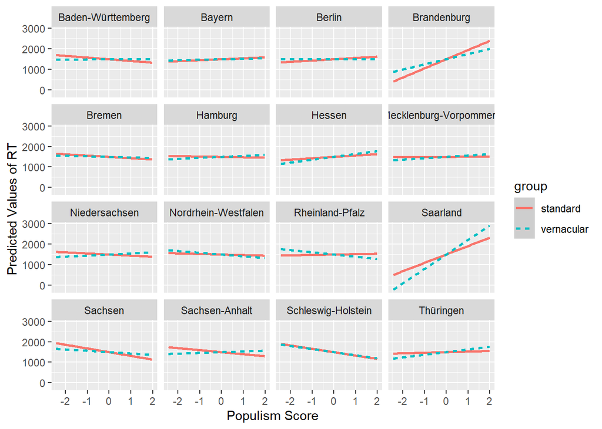

##### subset analyses - low populism

```
## fixed-effect model matrix is rank deficient so dropping 1 column / coefficient
## fixed-effect model matrix is rank deficient so dropping 1 column / coefficient
```

```
## Linear mixed model fit by REML. t-tests use Satterthwaite's method [
## lmerModLmerTest]
## Formula: penal_RTs ~ charisma_lang_var:bundesland + trialcount + age +
##     leadership_lang_var + start_iat + (charisma_lang_var | bilendi_id) +
##     (populism_all | stimulus_ID)
##    Data: Four_Out_low_pop
## Control: lmerControl(optimizer = "bobyqa", optCtrl = list(maxfun = 2e+05))
##
## REML criterion at convergence: 469350.4
##
## Scaled residuals:
##     Min      1Q  Median      3Q     Max
## -4.9202 -0.6277 -0.1368  0.5458 12.3313
##
## Random effects:
##  Groups      Name                        Variance Std.Dev. Corr
##  stimulus_ID (Intercept)                  13459.7 116.02
##              populism_all                   820.9  28.65   -0.31
##  bilendi_id  (Intercept)                 158181.0 397.72
##              charisma_lang_varvernacular 274821.4 524.23   -0.54
##  Residual                                327051.0 571.88
## Number of obs: 30093, groups:  stimulus_ID, 303; bilendi_id, 251
##
## Fixed effects:
##                                                               Estimate
## (Intercept)                                                  1931.9101
## trialcount                                                     -5.0493
## age                                                            86.5239
## leadership_lang_var2                                           95.9704
## start_iatvernacular-with Charisma                             -11.6918
## charisma_lang_varstandard:bundeslandBaden-Württemberg         334.1683
## charisma_lang_varvernacular:bundeslandBaden-Württemberg       153.0489
## charisma_lang_varstandard:bundeslandBayern                     76.8018
## charisma_lang_varvernacular:bundeslandBayern                  218.3789
## charisma_lang_varstandard:bundeslandBerlin                     15.3545
## charisma_lang_varvernacular:bundeslandBerlin                  135.7185
## charisma_lang_varstandard:bundeslandBrandenburg              -135.8466
## charisma_lang_varvernacular:bundeslandBrandenburg            -116.4400
## charisma_lang_varstandard:bundeslandBremen                    426.0399
## charisma_lang_varvernacular:bundeslandBremen                  295.4191
```

[output cut: 119 more lines]

```
## charisma_lang_varstandard:bundeslandNordrhein-Westfalen      0.210246
## charisma_lang_varvernacular:bundeslandNordrhein-Westfalen    0.105985
## charisma_lang_varstandard:bundeslandRheinland-Pfalz          0.822223
## charisma_lang_varvernacular:bundeslandRheinland-Pfalz        0.500649
## charisma_lang_varstandard:bundeslandSaarland                 0.765898
## charisma_lang_varvernacular:bundeslandSaarland               0.635442
## charisma_lang_varstandard:bundeslandSachsen                  0.310187
## charisma_lang_varvernacular:bundeslandSachsen                0.313174
## charisma_lang_varstandard:bundeslandSachsen-Anhalt           0.825401
## charisma_lang_varvernacular:bundeslandSachsen-Anhalt         0.841546
## charisma_lang_varstandard:bundeslandSchleswig-Holstein       0.128244
## charisma_lang_varvernacular:bundeslandSchleswig-Holstein     0.297545
## charisma_lang_varstandard:bundeslandThüringen                0.231469
## ---
## Signif. codes:  0 '***' 0.001 '**' 0.01 '*' 0.05 '.' 0.1 ' ' 1
```

```
##
## Correlation matrix not shown by default, as p = 36 > 12.
## Use print(x, correlation=TRUE)  or
##     vcov(x)        if you need it
```

```
## fit warnings:
## fixed-effect model matrix is rank deficient so dropping 1 column / coefficient
```

```
## Type III Analysis of Variance Table with Satterthwaite's method
##                                 Sum Sq   Mean Sq NumDF  DenDF  F value
## trialcount                   284632538 284632538     1 4256.3 870.3002
## age                            5081429   5081429     1  231.5  15.5371
## leadership_lang_var            1536476   1536476     1  237.1   4.6980
## start_iat                        22960     22960     1  232.3   0.0702
## charisma_lang_var:bundesland   8608894    277706    31  183.2   0.8491
##                                 Pr(>F)
## trialcount                   < 2.2e-16 ***
## age                          0.0001072 ***
## leadership_lang_var          0.0311941 *
## start_iat                    0.7912778
## charisma_lang_var:bundesland 0.6973773
## ---
## Signif. codes:  0 '***' 0.001 '**' 0.01 '*' 0.05 '.' 0.1 ' ' 1
```

```
## fixed-effect model matrix is rank deficient so dropping 1 column / coefficient
## fixed-effect model matrix is rank deficient so dropping 1 column / coefficient
```

```
## Linear mixed model fit by REML. t-tests use Satterthwaite's method [
## lmerModLmerTest]
## Formula: penal_RTs ~ charisma_lang_var:bundesland + trialcount + age +
##     leadership_lang_var + start_iat + (charisma_lang_var | bilendi_id) +
##     (populism_all | stimulus_ID)
##    Data: Four_Out_high_pop
## Control: lmerControl(optimizer = "bobyqa", optCtrl = list(maxfun = 2e+05))
##
## REML criterion at convergence: 534568.1
##
## Scaled residuals:
##     Min      1Q  Median      3Q     Max
## -6.4553 -0.6099 -0.1156  0.5566 13.5242
##
## Random effects:
##  Groups      Name                        Variance Std.Dev. Corr
##  stimulus_ID (Intercept)                  11930.7 109.2
##              populism_all                   640.2  25.3    0.26
##  bilendi_id  (Intercept)                 199485.5 446.6
##              charisma_lang_varvernacular 267651.5 517.4    -0.24
##  Residual                                326213.9 571.2
## Number of obs: 34272, groups:  stimulus_ID, 303; bilendi_id, 286
##
## Fixed effects:
##                                                               Estimate
## (Intercept)                                                  1938.5062
## trialcount                                                     -4.3719
## age                                                            73.1868
## leadership_lang_var2                                           46.5604
## start_iatvernacular-with Charisma                             150.8669
## charisma_lang_varstandard:bundeslandBaden-Württemberg          64.8681
## charisma_lang_varvernacular:bundeslandBaden-Württemberg        25.4789
## charisma_lang_varstandard:bundeslandBayern                     49.9118
## charisma_lang_varvernacular:bundeslandBayern                  181.6488
## charisma_lang_varstandard:bundeslandBerlin                    -12.5533
## charisma_lang_varvernacular:bundeslandBerlin                  -96.9260
## charisma_lang_varstandard:bundeslandBrandenburg               556.4935
## charisma_lang_varvernacular:bundeslandBrandenburg             433.1142
## charisma_lang_varstandard:bundeslandBremen                     47.4011
## charisma_lang_varvernacular:bundeslandBremen                 -125.6451
```

[output cut: 119 more lines]

```
## charisma_lang_varstandard:bundeslandNordrhein-Westfalen       0.76770
## charisma_lang_varvernacular:bundeslandNordrhein-Westfalen     0.59414
## charisma_lang_varstandard:bundeslandRheinland-Pfalz           0.87008
## charisma_lang_varvernacular:bundeslandRheinland-Pfalz         0.98790
## charisma_lang_varstandard:bundeslandSaarland                  0.31540
## charisma_lang_varvernacular:bundeslandSaarland                0.31183
## charisma_lang_varstandard:bundeslandSachsen                   0.69467
## charisma_lang_varvernacular:bundeslandSachsen                 0.86026
## charisma_lang_varstandard:bundeslandSachsen-Anhalt            0.45588
## charisma_lang_varvernacular:bundeslandSachsen-Anhalt          0.67752
## charisma_lang_varstandard:bundeslandSchleswig-Holstein        0.45679
## charisma_lang_varvernacular:bundeslandSchleswig-Holstein      0.98527
## charisma_lang_varstandard:bundeslandThüringen                 0.92418
## ---
## Signif. codes:  0 '***' 0.001 '**' 0.01 '*' 0.05 '.' 0.1 ' ' 1
```

```
##
## Correlation matrix not shown by default, as p = 36 > 12.
## Use print(x, correlation=TRUE)  or
##     vcov(x)        if you need it
```

```
## fit warnings:
## fixed-effect model matrix is rank deficient so dropping 1 column / coefficient
```

```
## Type III Analysis of Variance Table with Satterthwaite's method
##                                 Sum Sq   Mean Sq NumDF  DenDF  F value
## trialcount                   243778969 243778969     1 4975.6 747.2978
## age                            2321332   2321332     1  267.2   7.1160
## leadership_lang_var             249666    249666     1  270.8   0.7653
## start_iat                      2532775   2532775     1  273.8   7.7642
## charisma_lang_var:bundesland  11640435    375498    31  219.0   1.1511
##                                 Pr(>F)
## trialcount                   < 2.2e-16 ***
## age                           0.008107 **
## leadership_lang_var           0.382437
## start_iat                     0.005702 **
## charisma_lang_var:bundesland  0.276197
## ---
## Signif. codes:  0 '***' 0.001 '**' 0.01 '*' 0.05 '.' 0.1 ' ' 1
```

### 2.4.3. Political ideology

#### General

```
## Linear mixed model fit by REML. t-tests use Satterthwaite's method [
## lmerModLmerTest]
## Formula: penal_RTs ~ charisma_lang_var * start_iat * ideology + trialcount +
##     age + leadership_lang_var + (charisma_lang_var | bilendi_id) +
##     (start_iat | stimulus_ID)
##    Data: Four_Out
## Control: lmerControl(optimizer = "bobyqa", optCtrl = list(maxfun = 2e+05))
##
## REML criterion at convergence: 1003962
##
## Scaled residuals:
##     Min      1Q  Median      3Q     Max
## -6.2927 -0.6203 -0.1218  0.5497 13.5404
##
## Random effects:
##  Groups      Name                              Variance Std.Dev. Corr
##  bilendi_id  (Intercept)                       163947   404.90
##              charisma_lang_varvernacular       109369   330.71   -0.25
##  stimulus_ID (Intercept)                        11740   108.35
##              start_iatvernacular-with Charisma   1067    32.66   -0.05
##  Residual                                      326949   571.79
## Number of obs: 64365, groups:  bilendi_id, 537; stimulus_ID, 303
##
## Fixed effects:
##                                                                          Estimate
## (Intercept)                                                             1980.0523
## charisma_lang_varvernacular                                              562.0531
## start_iatvernacular-with Charisma                                        438.0111
## ideology                                                                 -40.9904
## trialcount                                                                -5.7766
## age                                                                       77.7932
## leadership_lang_var2                                                      66.3162
## charisma_lang_varvernacular:start_iatvernacular-with Charisma           -981.2255
## charisma_lang_varvernacular:ideology                                     -96.2982
## start_iatvernacular-with Charisma:ideology                                26.7892
## charisma_lang_varvernacular:start_iatvernacular-with Charisma:ideology   123.4940
##                                                                        Std. Error
## (Intercept)                                                               32.3167
## charisma_lang_varvernacular                                               24.9996
## start_iatvernacular-with Charisma                                         37.6027
```

[output cut: 67 more lines]

```
## chrsm__:_-C -0.045 -0.800 -0.399 -0.003  0.616  0.000  0.000
## chrsm_lng_:  0.004 -0.014 -0.003 -0.276  0.000  0.000  0.000  0.009
## strt_tvr-C:  0.018 -0.003 -0.004 -0.775  0.000 -0.039 -0.015  0.001    0.214
## chrs__:_-C: -0.003  0.011  0.001  0.214  0.000  0.000  0.000 -0.003   -0.775
##             st_-C:
## chrsm_lng_v
## strt_tvrn-C
## ideology
## trialcount
## age
## ldrshp_ln_2
## chrsm__:_-C
## chrsm_lng_:
## strt_tvr-C:
## chrs__:_-C: -0.276
```

```
## Type III Analysis of Variance Table with Satterthwaite's method
##                                         Sum Sq   Mean Sq NumDF DenDF   F value
## charisma_lang_var                      7397171   7397171     1   533   22.6248
## start_iat                               750258    750258     1   533    2.2947
## ideology                               2119541   2119541     1   530    6.4828
## trialcount                           641950122 641950122     1 63022 1963.4544
## age                                    6763839   6763839     1   531   20.6877
## leadership_lang_var                    1190242   1190242     1   542    3.6404
## charisma_lang_var:start_iat          216657604 216657604     1  1376  662.6642
## charisma_lang_var:ideology             1673657   1673657     1   533    5.1190
## start_iat:ideology                     2062198   2062198     1   530    6.3074
## charisma_lang_var:start_iat:ideology   5345388   5345388     1   533   16.3493
##                                         Pr(>F)
## charisma_lang_var                    2.539e-06 ***
## start_iat                              0.13041
## ideology                               0.01117 *
## trialcount                           < 2.2e-16 ***
## age                                  6.704e-06 ***
## leadership_lang_var                    0.05692 .
## charisma_lang_var:start_iat          < 2.2e-16 ***
## charisma_lang_var:ideology             0.02407 *
## start_iat:ideology                     0.01232 *
## charisma_lang_var:start_iat:ideology 6.046e-05 ***
## ---
## Signif. codes:  0 '***' 0.001 '**' 0.01 '*' 0.05 '.' 0.1 ' ' 1
```

```
## Note: D.f. calculations have been disabled because the number of observations exceeds 3000.
## To enable adjustments, add the argument 'pbkrtest.limit = 64365' (or larger)
## [or, globally, 'set emm_options(pbkrtest.limit = 64365)' or larger];
## but be warned that this may result in large computation time and memory use.
```

```
## Note: D.f. calculations have been disabled because the number of observations exceeds 3000.
## To enable adjustments, add the argument 'lmerTest.limit = 64365' (or larger)
## [or, globally, 'set emm_options(lmerTest.limit = 64365)' or larger];
## but be warned that this may result in large computation time and memory use.
```

```
## start_iat = standard-with Charisma:
##  charisma_lang_var ideology.trend   SE  df asymp.LCL asymp.UCL
##  standard                   -41.0 28.1 Inf     -96.1      14.1
##  vernacular                -137.3 31.4 Inf    -198.7     -75.8
##
## start_iat = vernacular-with Charisma:
##  charisma_lang_var ideology.trend   SE  df asymp.LCL asymp.UCL
##  standard                   -14.2 22.9 Inf     -59.1      30.7
##  vernacular                  13.0 25.6 Inf     -37.1      63.1
##
## Results are averaged over the levels of: leadership_lang_var
## Degrees-of-freedom method: asymptotic
## Confidence level used: 0.95
```

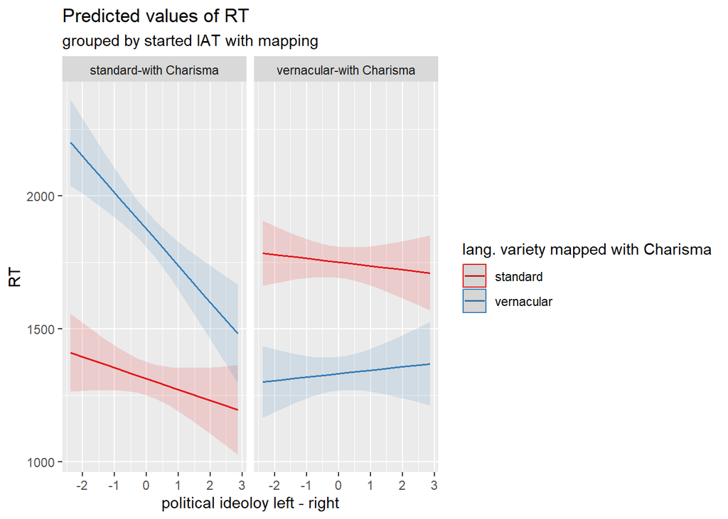

#### Political ideology & gender

```
## Linear mixed model fit by REML. t-tests use Satterthwaite's method [
## lmerModLmerTest]
## Formula:
## penal_RTs ~ charisma_lang_var * ideology * speaker_gender + start_iat +
##     trialcount + age + pp_gender + leadership_lang_var + (charisma_lang_var |
##     bilendi_id) + (start_iat | stimulus_ID)
##    Data: Four_Out
## Control: lmerControl(optimizer = "bobyqa", optCtrl = list(maxfun = 2e+05))
##
## REML criterion at convergence: 1004446
##
## Scaled residuals:
##     Min      1Q  Median      3Q     Max
## -6.3980 -0.6193 -0.1257  0.5502 13.4532
##
## Random effects:
##  Groups      Name                              Variance Std.Dev. Corr
##  bilendi_id  (Intercept)                       179124   423.23
##              charisma_lang_varvernacular       262423   512.27   -0.37
##  stimulus_ID (Intercept)                        11735   108.33
##              start_iatvernacular-with Charisma   1076    32.81   -0.05
##  Residual                                      327353   572.15
## Number of obs: 64365, groups:  bilendi_id, 537; stimulus_ID, 303
##
## Fixed effects:
##                                                          Estimate Std. Error
## (Intercept)                                             2007.5357   400.4266
## charisma_lang_varvernacular                               30.1150    32.1560
## ideology                                                 -37.2121    28.5472
## speaker_gendermale                                        57.7665    39.4437
## start_iatvernacular-with Charisma                         91.2400    34.7437
## trialcount                                                -4.6210     0.1158
## age                                                       81.1841    17.2233
## pp_genderfemale                                           -6.5027   400.1923
## pp_gendermale                                             -9.1250   400.6737
## leadership_lang_var2                                      68.0799    34.9215
## charisma_lang_varvernacular:ideology                      -2.8352    34.3723
## charisma_lang_varvernacular:speaker_gendermale            17.8277    45.1663
## ideology:speaker_gendermale                               20.6873    37.5789
## charisma_lang_varvernacular:ideology:speaker_gendermale  -23.5231    45.5642
```

[output cut: 17 more lines]

```
## charisma_lang_varvernacular                              0.34955
## ideology                                                 0.19313
## speaker_gendermale                                       0.14369
## start_iatvernacular-with Charisma                        0.00888 **
## trialcount                                               < 2e-16 ***
## age                                                     3.12e-06 ***
## pp_genderfemale                                          0.98704
## pp_gendermale                                            0.98184
## leadership_lang_var2                                     0.05175 .
## charisma_lang_varvernacular:ideology                     0.93430
## charisma_lang_varvernacular:speaker_gendermale           0.69326
## ideology:speaker_gendermale                              0.58228
## charisma_lang_varvernacular:ideology:speaker_gendermale  0.60595
## ---
## Signif. codes:  0 '***' 0.001 '**' 0.01 '*' 0.05 '.' 0.1 ' ' 1
```

```
##
## Correlation matrix not shown by default, as p = 14 > 12.
## Use print(x, correlation=TRUE)  or
##     vcov(x)        if you need it
```

```
## Type III Analysis of Variance Table with Satterthwaite's method
##                                              Sum Sq   Mean Sq NumDF  DenDF
## charisma_lang_var                            976451    976451     1  409.7
## ideology                                    1171584   1171584     1  469.9
## speaker_gender                              1021968   1021968     1  578.0
## start_iat                                   2257539   2257539     1  538.4
## trialcount                                521175693 521175693     1 8477.4
## age                                         7273244   7273244     1  527.9
## pp_gender                                      1958       979     2  527.9
## leadership_lang_var                         1244139   1244139     1  539.6
## charisma_lang_var:ideology                   134397    134397     1  408.9
## charisma_lang_var:speaker_gender              51001     51001     1  408.9
## ideology:speaker_gender                       20403     20403     1  466.8
## charisma_lang_var:ideology:speaker_gender     87248     87248     1  409.0
##                                             F value    Pr(>F)
## charisma_lang_var                            2.9829  0.084904 .
## ideology                                     3.5790  0.059130 .
## speaker_gender                               3.1219  0.077774 .
## start_iat                                    6.8963  0.008883 **
## trialcount                                1592.0893 < 2.2e-16 ***
## age                                         22.2183 3.117e-06 ***
## pp_gender                                    0.0030  0.997014
## leadership_lang_var                          3.8006  0.051752 .
## charisma_lang_var:ideology                   0.4106  0.522046
## charisma_lang_var:speaker_gender             0.1558  0.693260
## ideology:speaker_gender                      0.0623  0.802967
## charisma_lang_var:ideology:speaker_gender    0.2665  0.605950
## ---
## Signif. codes:  0 '***' 0.001 '**' 0.01 '*' 0.05 '.' 0.1 ' ' 1
```

### 2.4.4. Voting behaviour

Simple effects in contrasts lang. variety level vernacular and Grün vs. LINKE, CDU/CSU vs. LINKE, AfD vs.LINKe approaching significance

```
## Linear mixed model fit by REML. t-tests use Satterthwaite's method [
## lmerModLmerTest]
## Formula: penal_RTs ~ charisma_lang_var * start_iat * voting_behaviour +
##     trialcount + age + leadership_lang_var + (charisma_lang_var |
##     bilendi_id) + (start_iat | stimulus_ID)
##    Data: Four_Out
## Control: lmerControl(optimizer = "bobyqa", optCtrl = list(maxfun = 2e+05))
##
## REML criterion at convergence: 1003587
##
## Scaled residuals:
##     Min      1Q  Median      3Q     Max
## -6.2849 -0.6198 -0.1215  0.5499 13.5396
##
## Random effects:
##  Groups      Name                              Variance Std.Dev. Corr
##  bilendi_id  (Intercept)                       164969   406.16
##              charisma_lang_varvernacular       112062   334.76   -0.25
##  stimulus_ID (Intercept)                        11728   108.30
##              start_iatvernacular-with Charisma   1063    32.61   -0.05
##  Residual                                      326950   571.80
## Number of obs: 64365, groups:  bilendi_id, 537; stimulus_ID, 303
##
## Fixed effects:
##                                                                                             Estimate
## (Intercept)                                                                                1917.5984
## charisma_lang_varvernacular                                                                 514.9922
## start_iatvernacular-with Charisma                                                           532.5818
## voting_behaviourandere                                                                      -50.2317
## voting_behaviourCDU/CSU                                                                      40.4447
## voting_behaviourDIE LINKE                                                                   -16.7092
## voting_behaviourFDP                                                                         -29.5237
## voting_behaviourGRüNE                                                                       155.7652
## voting_behaviourinvalid                                                                      35.9411
## voting_behaviourNichtwähler                                                                  51.0425
## voting_behaviourno_answer                                                                   111.8960
## voting_behaviourSPD                                                                         150.1658
## trialcount                                                                                   -5.7766
## age                                                                                          76.9345
## leadership_lang_var2                                                                         64.4530
```

[output cut: 235 more lines]

```
## start_iatvernacular-with Charisma:voting_behaviourinvalid
## start_iatvernacular-with Charisma:voting_behaviourNichtwähler
## start_iatvernacular-with Charisma:voting_behaviourno_answer
## start_iatvernacular-with Charisma:voting_behaviourSPD
## charisma_lang_varvernacular:start_iatvernacular-with Charisma:voting_behaviourandere
## charisma_lang_varvernacular:start_iatvernacular-with Charisma:voting_behaviourCDU/CSU
## charisma_lang_varvernacular:start_iatvernacular-with Charisma:voting_behaviourDIE LINKE   .
## charisma_lang_varvernacular:start_iatvernacular-with Charisma:voting_behaviourFDP
## charisma_lang_varvernacular:start_iatvernacular-with Charisma:voting_behaviourGRüNE
## charisma_lang_varvernacular:start_iatvernacular-with Charisma:voting_behaviourinvalid
## charisma_lang_varvernacular:start_iatvernacular-with Charisma:voting_behaviourNichtwähler
## charisma_lang_varvernacular:start_iatvernacular-with Charisma:voting_behaviourno_answer
## charisma_lang_varvernacular:start_iatvernacular-with Charisma:voting_behaviourSPD
## ---
## Signif. codes:  0 '***' 0.001 '**' 0.01 '*' 0.05 '.' 0.1 ' ' 1
```

```
##
## Correlation matrix not shown by default, as p = 43 > 12.
## Use print(x, correlation=TRUE)  or
##     vcov(x)        if you need it
```

```
## Linear mixed model fit by REML. t-tests use Satterthwaite's method [
## lmerModLmerTest]
## Formula: penal_RTs ~ charisma_lang_var * voting_behaviour * start_iat +
##     trialcount + age + leadership_lang_var + (charisma_lang_var |
##     bilendi_id) + (start_iat | stimulus_ID)
##    Data: Four_Out
## Control: lmerControl(optimizer = "bobyqa", optCtrl = list(maxfun = 2e+05))
##
## REML criterion at convergence: 1003587
##
## Scaled residuals:
##     Min      1Q  Median      3Q     Max
## -6.2849 -0.6198 -0.1215  0.5499 13.5396
##
## Random effects:
##  Groups      Name                              Variance Std.Dev. Corr
##  bilendi_id  (Intercept)                       164968   406.16
##              charisma_lang_varvernacular       112061   334.76   -0.25
##  stimulus_ID (Intercept)                        11728   108.30
##              start_iatvernacular-with Charisma   1063    32.61   -0.05
##  Residual                                      326950   571.80
## Number of obs: 64365, groups:  bilendi_id, 537; stimulus_ID, 303
##
## Fixed effects:
##                                                                                             Estimate
## (Intercept)                                                                                1888.0744
## charisma_lang_varvernacular                                                                 456.2769
## voting_behaviourAfD                                                                          29.5239
## voting_behaviourandere                                                                      -20.7077
## voting_behaviourCDU/CSU                                                                      69.9687
## voting_behaviourDIE LINKE                                                                    12.8149
## voting_behaviourGRüNE                                                                       185.2891
## voting_behaviourinvalid                                                                      65.4650
## voting_behaviourNichtwähler                                                                  80.5663
## voting_behaviourno_answer                                                                   141.4198
## voting_behaviourSPD                                                                         179.6897
## start_iatvernacular-with Charisma                                                           456.2582
## trialcount                                                                                   -5.7766
## age                                                                                          76.9343
## leadership_lang_var2                                                                         64.4533
```

[output cut: 235 more lines]

```
## voting_behaviourinvalid:start_iatvernacular-with Charisma
## voting_behaviourNichtwähler:start_iatvernacular-with Charisma
## voting_behaviourno_answer:start_iatvernacular-with Charisma
## voting_behaviourSPD:start_iatvernacular-with Charisma
## charisma_lang_varvernacular:voting_behaviourAfD:start_iatvernacular-with Charisma
## charisma_lang_varvernacular:voting_behaviourandere:start_iatvernacular-with Charisma
## charisma_lang_varvernacular:voting_behaviourCDU/CSU:start_iatvernacular-with Charisma
## charisma_lang_varvernacular:voting_behaviourDIE LINKE:start_iatvernacular-with Charisma
## charisma_lang_varvernacular:voting_behaviourGRüNE:start_iatvernacular-with Charisma
## charisma_lang_varvernacular:voting_behaviourinvalid:start_iatvernacular-with Charisma
## charisma_lang_varvernacular:voting_behaviourNichtwähler:start_iatvernacular-with Charisma
## charisma_lang_varvernacular:voting_behaviourno_answer:start_iatvernacular-with Charisma
## charisma_lang_varvernacular:voting_behaviourSPD:start_iatvernacular-with Charisma
## ---
## Signif. codes:  0 '***' 0.001 '**' 0.01 '*' 0.05 '.' 0.1 ' ' 1
```

```
##
## Correlation matrix not shown by default, as p = 43 > 12.
## Use print(x, correlation=TRUE)  or
##     vcov(x)        if you need it
```

```
## Linear mixed model fit by REML. t-tests use Satterthwaite's method [
## lmerModLmerTest]
## Formula: penal_RTs ~ charisma_lang_var * voting_behaviour * start_iat +
##     trialcount + age + leadership_lang_var + (charisma_lang_var |
##     bilendi_id) + (start_iat | stimulus_ID)
##    Data: Four_Out
## Control: lmerControl(optimizer = "bobyqa", optCtrl = list(maxfun = 2e+05))
##
## REML criterion at convergence: 1003587
##
## Scaled residuals:
##     Min      1Q  Median      3Q     Max
## -6.2849 -0.6198 -0.1215  0.5499 13.5396
##
## Random effects:
##  Groups      Name                              Variance Std.Dev. Corr
##  bilendi_id  (Intercept)                       164969   406.16
##              charisma_lang_varvernacular       112062   334.76   -0.25
##  stimulus_ID (Intercept)                        11728   108.30
##              start_iatvernacular-with Charisma   1063    32.61   -0.05
##  Residual                                      326950   571.80
## Number of obs: 64365, groups:  bilendi_id, 537; stimulus_ID, 303
##
## Fixed effects:
##                                                                                             Estimate
## (Intercept)                                                                                2073.3637
## charisma_lang_varvernacular                                                                 530.1243
## voting_behaviourFDP                                                                        -185.2889
## voting_behaviourAfD                                                                        -155.7652
## voting_behaviourandere                                                                     -205.9969
## voting_behaviourCDU/CSU                                                                    -115.3205
## voting_behaviourDIE LINKE                                                                  -172.4744
## voting_behaviourinvalid                                                                    -119.8240
## voting_behaviourNichtwähler                                                                -104.7227
## voting_behaviourno_answer                                                                   -43.8692
## voting_behaviourSPD                                                                          -5.5994
## start_iatvernacular-with Charisma                                                           408.8388
## trialcount                                                                                   -5.7766
## age                                                                                          76.9345
## leadership_lang_var2                                                                         64.4530
```

[output cut: 235 more lines]

```
## voting_behaviourinvalid:start_iatvernacular-with Charisma
## voting_behaviourNichtwähler:start_iatvernacular-with Charisma
## voting_behaviourno_answer:start_iatvernacular-with Charisma
## voting_behaviourSPD:start_iatvernacular-with Charisma
## charisma_lang_varvernacular:voting_behaviourFDP:start_iatvernacular-with Charisma
## charisma_lang_varvernacular:voting_behaviourAfD:start_iatvernacular-with Charisma
## charisma_lang_varvernacular:voting_behaviourandere:start_iatvernacular-with Charisma
## charisma_lang_varvernacular:voting_behaviourCDU/CSU:start_iatvernacular-with Charisma
## charisma_lang_varvernacular:voting_behaviourDIE LINKE:start_iatvernacular-with Charisma   *
## charisma_lang_varvernacular:voting_behaviourinvalid:start_iatvernacular-with Charisma
## charisma_lang_varvernacular:voting_behaviourNichtwähler:start_iatvernacular-with Charisma
## charisma_lang_varvernacular:voting_behaviourno_answer:start_iatvernacular-with Charisma   .
## charisma_lang_varvernacular:voting_behaviourSPD:start_iatvernacular-with Charisma
## ---
## Signif. codes:  0 '***' 0.001 '**' 0.01 '*' 0.05 '.' 0.1 ' ' 1
```

```
##
## Correlation matrix not shown by default, as p = 43 > 12.
## Use print(x, correlation=TRUE)  or
##     vcov(x)        if you need it
```

```
## Linear mixed model fit by REML. t-tests use Satterthwaite's method [
## lmerModLmerTest]
## Formula: penal_RTs ~ charisma_lang_var * voting_behaviour * start_iat +
##     trialcount + age + leadership_lang_var + (charisma_lang_var |
##     bilendi_id) + (start_iat | stimulus_ID)
##    Data: Four_Out
## Control: lmerControl(optimizer = "bobyqa", optCtrl = list(maxfun = 2e+05))
##
## REML criterion at convergence: 1003587
##
## Scaled residuals:
##     Min      1Q  Median      3Q     Max
## -6.2849 -0.6198 -0.1215  0.5499 13.5396
##
## Random effects:
##  Groups      Name                              Variance Std.Dev. Corr
##  bilendi_id  (Intercept)                       164969   406.16
##              charisma_lang_varvernacular       112062   334.76   -0.25
##  stimulus_ID (Intercept)                        11728   108.30
##              start_iatvernacular-with Charisma   1063    32.61   -0.05
##  Residual                                      326950   571.80
## Number of obs: 64365, groups:  bilendi_id, 537; stimulus_ID, 303
##
## Fixed effects:
##                                                                                             Estimate
## (Intercept)                                                                                1958.0431
## charisma_lang_varvernacular                                                                 488.6001
## voting_behaviourGRüNE                                                                       115.3205
## voting_behaviourFDP                                                                         -69.9684
## voting_behaviourAfD                                                                         -40.4447
## voting_behaviourandere                                                                      -90.6764
## voting_behaviourDIE LINKE                                                                   -57.1539
## voting_behaviourinvalid                                                                      -4.5035
## voting_behaviourNichtwähler                                                                  10.5978
## voting_behaviourno_answer                                                                    71.4513
## voting_behaviourSPD                                                                         109.7211
## start_iatvernacular-with Charisma                                                           378.8278
## trialcount                                                                                   -5.7766
## age                                                                                          76.9345
## leadership_lang_var2                                                                         64.4530
```

[output cut: 235 more lines]

```
## voting_behaviourinvalid:start_iatvernacular-with Charisma
## voting_behaviourNichtwähler:start_iatvernacular-with Charisma
## voting_behaviourno_answer:start_iatvernacular-with Charisma
## voting_behaviourSPD:start_iatvernacular-with Charisma
## charisma_lang_varvernacular:voting_behaviourGRüNE:start_iatvernacular-with Charisma
## charisma_lang_varvernacular:voting_behaviourFDP:start_iatvernacular-with Charisma
## charisma_lang_varvernacular:voting_behaviourAfD:start_iatvernacular-with Charisma
## charisma_lang_varvernacular:voting_behaviourandere:start_iatvernacular-with Charisma
## charisma_lang_varvernacular:voting_behaviourDIE LINKE:start_iatvernacular-with Charisma   *
## charisma_lang_varvernacular:voting_behaviourinvalid:start_iatvernacular-with Charisma
## charisma_lang_varvernacular:voting_behaviourNichtwähler:start_iatvernacular-with Charisma
## charisma_lang_varvernacular:voting_behaviourno_answer:start_iatvernacular-with Charisma   .
## charisma_lang_varvernacular:voting_behaviourSPD:start_iatvernacular-with Charisma
## ---
## Signif. codes:  0 '***' 0.001 '**' 0.01 '*' 0.05 '.' 0.1 ' ' 1
```

```
##
## Correlation matrix not shown by default, as p = 43 > 12.
## Use print(x, correlation=TRUE)  or
##     vcov(x)        if you need it
```

```
## Linear mixed model fit by REML. t-tests use Satterthwaite's method [
## lmerModLmerTest]
## Formula: penal_RTs ~ charisma_lang_var * voting_behaviour * start_iat +
##     trialcount + age + leadership_lang_var + (charisma_lang_var |
##     bilendi_id) + (start_iat | stimulus_ID)
##    Data: Four_Out
## Control: lmerControl(optimizer = "bobyqa", optCtrl = list(maxfun = 2e+05))
##
## REML criterion at convergence: 1003587
##
## Scaled residuals:
##     Min      1Q  Median      3Q     Max
## -6.2849 -0.6198 -0.1215  0.5499 13.5396
##
## Random effects:
##  Groups      Name                              Variance Std.Dev. Corr
##  bilendi_id  (Intercept)                       164969   406.16
##              charisma_lang_varvernacular       112062   334.76   -0.25
##  stimulus_ID (Intercept)                        11728   108.30
##              start_iatvernacular-with Charisma   1063    32.61   -0.05
##  Residual                                      326950   571.80
## Number of obs: 64365, groups:  bilendi_id, 537; stimulus_ID, 303
##
## Fixed effects:
##                                                                                             Estimate
## (Intercept)                                                                                1900.8893
## charisma_lang_varvernacular                                                                 808.5989
## voting_behaviourCDU/CSU                                                                      57.1539
## voting_behaviourGRüNE                                                                       172.4745
## voting_behaviourFDP                                                                         -12.8142
## voting_behaviourAfD                                                                          16.7092
## voting_behaviourandere                                                                      -33.5224
## voting_behaviourinvalid                                                                      52.6506
## voting_behaviourNichtwähler                                                                  67.7518
## voting_behaviourno_answer                                                                   128.6053
## voting_behaviourSPD                                                                         166.8751
## start_iatvernacular-with Charisma                                                           459.4898
## trialcount                                                                                   -5.7766
## age                                                                                          76.9347
## leadership_lang_var2                                                                         64.4527
```

[output cut: 235 more lines]

```
## voting_behaviourinvalid:start_iatvernacular-with Charisma
## voting_behaviourNichtwähler:start_iatvernacular-with Charisma
## voting_behaviourno_answer:start_iatvernacular-with Charisma
## voting_behaviourSPD:start_iatvernacular-with Charisma
## charisma_lang_varvernacular:voting_behaviourCDU/CSU:start_iatvernacular-with Charisma     *
## charisma_lang_varvernacular:voting_behaviourGRüNE:start_iatvernacular-with Charisma       *
## charisma_lang_varvernacular:voting_behaviourFDP:start_iatvernacular-with Charisma
## charisma_lang_varvernacular:voting_behaviourAfD:start_iatvernacular-with Charisma         .
## charisma_lang_varvernacular:voting_behaviourandere:start_iatvernacular-with Charisma
## charisma_lang_varvernacular:voting_behaviourinvalid:start_iatvernacular-with Charisma     **
## charisma_lang_varvernacular:voting_behaviourNichtwähler:start_iatvernacular-with Charisma .
## charisma_lang_varvernacular:voting_behaviourno_answer:start_iatvernacular-with Charisma
## charisma_lang_varvernacular:voting_behaviourSPD:start_iatvernacular-with Charisma
## ---
## Signif. codes:  0 '***' 0.001 '**' 0.01 '*' 0.05 '.' 0.1 ' ' 1
```

```
##
## Correlation matrix not shown by default, as p = 43 > 12.
## Use print(x, correlation=TRUE)  or
##     vcov(x)        if you need it
```

```
## Type III Analysis of Variance Table with Satterthwaite's method
##                                                 Sum Sq   Mean Sq NumDF DenDF
## charisma_lang_var                              6337964   6337964     1   517
## voting_behaviour                               4727911    525323     9   514
## start_iat                                        39357     39357     1   517
## trialcount                                   641964584 641964584     1 63022
## age                                            6072893   6072893     1   515
## leadership_lang_var                            1081480   1081480     1   525
## charisma_lang_var:voting_behaviour             4074619    452735     9   517
## charisma_lang_var:start_iat                  164237084 164237084     1  1034
## voting_behaviour:start_iat                     2924896    324988     9   514
## charisma_lang_var:voting_behaviour:start_iat   4087356    454151     9   517
##                                                F value    Pr(>F)
## charisma_lang_var                              19.3851 1.299e-05 ***
## voting_behaviour                                1.6067   0.11016
## start_iat                                       0.1204   0.72877
## trialcount                                   1963.4919 < 2.2e-16 ***
## age                                            18.5744 1.958e-05 ***
## leadership_lang_var                             3.3078   0.06952 .
## charisma_lang_var:voting_behaviour              1.3847   0.19181
## charisma_lang_var:start_iat                   502.3302 < 2.2e-16 ***
## voting_behaviour:start_iat                      0.9940   0.44383
## charisma_lang_var:voting_behaviour:start_iat    1.3891   0.18983
## ---
## Signif. codes:  0 '***' 0.001 '**' 0.01 '*' 0.05 '.' 0.1 ' ' 1
```

```
## Note: D.f. calculations have been disabled because the number of observations exceeds 3000.
## To enable adjustments, add the argument 'pbkrtest.limit = 64365' (or larger)
## [or, globally, 'set emm_options(pbkrtest.limit = 64365)' or larger];
## but be warned that this may result in large computation time and memory use.
```

```
## Note: D.f. calculations have been disabled because the number of observations exceeds 3000.
## To enable adjustments, add the argument 'lmerTest.limit = 64365' (or larger)
## [or, globally, 'set emm_options(lmerTest.limit = 64365)' or larger];
## but be warned that this may result in large computation time and memory use.
```

```
## $emmeans
##  charisma_lang_var start_iat                voting_behaviour emmean    SE  df
##  standard          standard-with Charisma   DIE LINKE          1266 111.3 Inf
##  vernacular        standard-with Charisma   DIE LINKE          2075 124.3 Inf
##  standard          vernacular-with Charisma DIE LINKE          1725  86.6 Inf
##  vernacular        vernacular-with Charisma DIE LINKE          1310  96.8 Inf
##  standard          standard-with Charisma   CDU/CSU            1323  62.2 Inf
##  vernacular        standard-with Charisma   CDU/CSU            1812  69.3 Inf
##  standard          vernacular-with Charisma CDU/CSU            1702  56.2 Inf
##  vernacular        vernacular-with Charisma CDU/CSU            1290  62.6 Inf
##  standard          standard-with Charisma   GRüNE              1438  62.9 Inf
##  vernacular        standard-with Charisma   GRüNE              1969  70.2 Inf
##  standard          vernacular-with Charisma GRüNE              1847  57.0 Inf
##  vernacular        vernacular-with Charisma GRüNE              1453  63.6 Inf
##  standard          standard-with Charisma   FDP                1253 104.5 Inf
##  vernacular        standard-with Charisma   FDP                1709 116.6 Inf
##  standard          vernacular-with Charisma FDP                1709  95.3 Inf
##  vernacular        vernacular-with Charisma FDP                1204 106.5 Inf
##  standard          standard-with Charisma   AfD                1283  86.7 Inf
##  vernacular        standard-with Charisma   AfD                1798  96.9 Inf
##  standard          vernacular-with Charisma AfD                1815  67.7 Inf
##  vernacular        vernacular-with Charisma AfD                1363  75.6 Inf
##  standard          standard-with Charisma   andere             1232  86.7 Inf
##  vernacular        standard-with Charisma   andere             1822  96.9 Inf
##  standard          vernacular-with Charisma andere             1797  95.3 Inf
##  vernacular        vernacular-with Charisma andere             1395 106.5 Inf
##  standard          standard-with Charisma   invalid            1319 146.5 Inf
##  vernacular        standard-with Charisma   invalid            1780 163.8 Inf
##  standard          vernacular-with Charisma invalid            1849 185.7 Inf
##  vernacular        vernacular-with Charisma invalid            1693 207.6 Inf
##  standard          standard-with Charisma   Nichtwähler        1334  97.8 Inf
##  vernacular        standard-with Charisma   Nichtwähler        1830 109.3 Inf
##  standard          vernacular-with Charisma Nichtwähler        1966 114.9 Inf
##  vernacular        vernacular-with Charisma Nichtwähler        1526 128.5 Inf
##  standard          standard-with Charisma   no_answer          1395  88.6 Inf
##  vernacular        standard-with Charisma   no_answer          2043  99.0 Inf
##  standard          vernacular-with Charisma no_answer          1807  83.5 Inf
##  vernacular        vernacular-with Charisma no_answer          1319  93.3 Inf
##  standard          standard-with Charisma   SPD                1433  72.4 Inf
##  vernacular        standard-with Charisma   SPD                2092  80.9 Inf
```

[output cut: 1600 more lines]

```
##   426.8914 113.3 Inf   3.769  0.0747
##  -114.2292 117.4 Inf  -0.973  1.0000
##  -773.2665 123.4 Inf  -6.265  <.0001
##  -446.4505 115.8 Inf  -3.854  0.0561
##   -61.3671 120.1 Inf  -0.511  1.0000
##  -659.0373  62.2 Inf -10.599  <.0001
##  -332.2213  99.4 Inf  -3.343  0.2561
##    52.8621 104.3 Inf   0.507  1.0000
##   326.8160 105.1 Inf   3.109  0.4265
##   711.8994 111.0 Inf   6.414  <.0001
##   385.0835  58.1 Inf   6.628  <.0001
##
## Results are averaged over the levels of: leadership_lang_var
## Degrees-of-freedom method: asymptotic
## P value adjustment: tukey method for comparing a family of 40 estimates
```

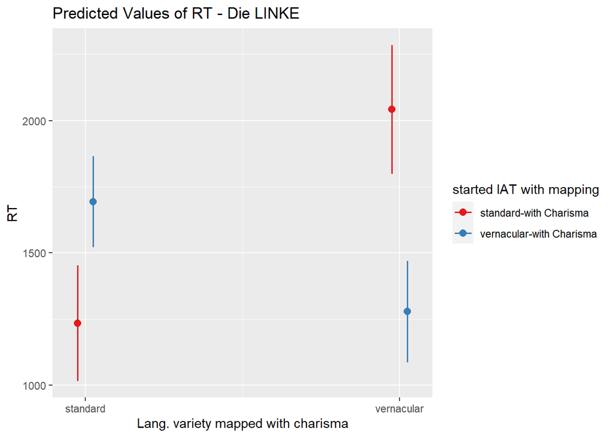

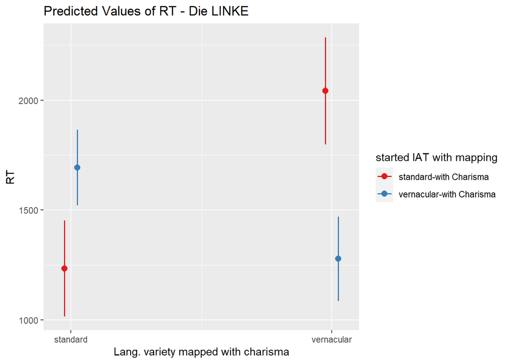

```
## Linear mixed model fit by REML. t-tests use Satterthwaite's method [
## lmerModLmerTest]
## Formula: penal_RTs ~ charisma_lang_var * voting_behaviour * start_iat +
##     trialcount + age + leadership_lang_var + (charisma_lang_var |
##     bilendi_id) + (start_iat | stimulus_ID)
##    Data: Four_Out
## Control: lmerControl(optimizer = "bobyqa", optCtrl = list(maxfun = 2e+05))
##
## REML criterion at convergence: 1003587
##
## Scaled residuals:
##     Min      1Q  Median      3Q     Max
## -6.2849 -0.6198 -0.1215  0.5499 13.5396
##
## Random effects:
##  Groups      Name                              Variance Std.Dev. Corr
##  bilendi_id  (Intercept)                       164969   406.16
##              charisma_lang_varvernacular       112062   334.76   -0.25
##  stimulus_ID (Intercept)                        11728   108.30
##              start_iatvernacular-with Charisma   1063    32.61   -0.05
##  Residual                                      326950   571.80
## Number of obs: 64365, groups:  bilendi_id, 537; stimulus_ID, 303
##
## Fixed effects:
##                                                                                             Estimate
## (Intercept)                                                                                2067.7642
## charisma_lang_varvernacular                                                                 659.0373
## voting_behaviourDIE LINKE                                                                  -166.8749
## voting_behaviourCDU/CSU                                                                    -109.7211
## voting_behaviourGRüNE                                                                         5.5994
## voting_behaviourFDP                                                                        -179.6895
## voting_behaviourAfD                                                                        -150.1658
## voting_behaviourandere                                                                     -200.3974
## voting_behaviourinvalid                                                                    -114.2246
## voting_behaviourNichtwähler                                                                 -99.1233
## voting_behaviourno_answer                                                                   -38.2698
## start_iatvernacular-with Charisma                                                           332.2214
## trialcount                                                                                   -5.7766
## age                                                                                          76.9345
## leadership_lang_var2                                                                         64.4530
```

[output cut: 235 more lines]

```
## voting_behaviourandere:start_iatvernacular-with Charisma
## voting_behaviourinvalid:start_iatvernacular-with Charisma
## voting_behaviourNichtwähler:start_iatvernacular-with Charisma                             .
## voting_behaviourno_answer:start_iatvernacular-with Charisma
## charisma_lang_varvernacular:voting_behaviourDIE LINKE:start_iatvernacular-with Charisma
## charisma_lang_varvernacular:voting_behaviourCDU/CSU:start_iatvernacular-with Charisma
## charisma_lang_varvernacular:voting_behaviourGRüNE:start_iatvernacular-with Charisma
## charisma_lang_varvernacular:voting_behaviourFDP:start_iatvernacular-with Charisma
## charisma_lang_varvernacular:voting_behaviourAfD:start_iatvernacular-with Charisma
## charisma_lang_varvernacular:voting_behaviourandere:start_iatvernacular-with Charisma
## charisma_lang_varvernacular:voting_behaviourinvalid:start_iatvernacular-with Charisma     *
## charisma_lang_varvernacular:voting_behaviourNichtwähler:start_iatvernacular-with Charisma
## charisma_lang_varvernacular:voting_behaviourno_answer:start_iatvernacular-with Charisma
## ---
## Signif. codes:  0 '***' 0.001 '**' 0.01 '*' 0.05 '.' 0.1 ' ' 1
```

```
##
## Correlation matrix not shown by default, as p = 43 > 12.
## Use print(x, correlation=TRUE)  or
##     vcov(x)        if you need it
```

```
## Linear mixed model fit by REML. t-tests use Satterthwaite's method [
## lmerModLmerTest]
## Formula: penal_RTs ~ charisma_lang_var * voting_behaviour * start_iat +
##     trialcount + age + leadership_lang_var + (charisma_lang_var |
##     bilendi_id) + (start_iat | stimulus_ID)
##    Data: Four_Out
## Control: lmerControl(optimizer = "bobyqa", optCtrl = list(maxfun = 2e+05))
##
## REML criterion at convergence: 1003587
##
## Scaled residuals:
##     Min      1Q  Median      3Q     Max
## -6.2849 -0.6198 -0.1215  0.5499 13.5396
##
## Random effects:
##  Groups      Name                              Variance Std.Dev. Corr
##  bilendi_id  (Intercept)                       164969   406.16
##              charisma_lang_varvernacular       112062   334.76   -0.25
##  stimulus_ID (Intercept)                        11728   108.30
##              start_iatvernacular-with Charisma   1063    32.61   -0.05
##  Residual                                      326950   571.80
## Number of obs: 64365, groups:  bilendi_id, 537; stimulus_ID, 303
##
## Fixed effects:
##                                                                                           Estimate
## (Intercept)                                                                              1968.6410
## charisma_lang_varvernacular                                                               496.4483
## voting_behaviourSPD                                                                        99.1233
## voting_behaviourDIE LINKE                                                                 -67.7517
## voting_behaviourCDU/CSU                                                                   -10.5979
## voting_behaviourGRüNE                                                                     104.7227
## voting_behaviourFDP                                                                       -80.5661
## voting_behaviourAfD                                                                       -51.0425
## voting_behaviourandere                                                                   -101.2742
## voting_behaviourinvalid                                                                   -15.1013
## voting_behaviourno_answer                                                                  60.8535
## start_iatvernacular-with Charisma                                                         631.8751
## trialcount                                                                                 -5.7766
## age                                                                                        76.9346
## leadership_lang_var2                                                                       64.4529
```

[output cut: 235 more lines]

```
## voting_behaviourAfD:start_iatvernacular-with Charisma
## voting_behaviourandere:start_iatvernacular-with Charisma
## voting_behaviourinvalid:start_iatvernacular-with Charisma
## voting_behaviourno_answer:start_iatvernacular-with Charisma
## charisma_lang_varvernacular:voting_behaviourSPD:start_iatvernacular-with Charisma
## charisma_lang_varvernacular:voting_behaviourDIE LINKE:start_iatvernacular-with Charisma .
## charisma_lang_varvernacular:voting_behaviourCDU/CSU:start_iatvernacular-with Charisma
## charisma_lang_varvernacular:voting_behaviourGRüNE:start_iatvernacular-with Charisma
## charisma_lang_varvernacular:voting_behaviourFDP:start_iatvernacular-with Charisma
## charisma_lang_varvernacular:voting_behaviourAfD:start_iatvernacular-with Charisma
## charisma_lang_varvernacular:voting_behaviourandere:start_iatvernacular-with Charisma
## charisma_lang_varvernacular:voting_behaviourinvalid:start_iatvernacular-with Charisma
## charisma_lang_varvernacular:voting_behaviourno_answer:start_iatvernacular-with Charisma
## ---
## Signif. codes:  0 '***' 0.001 '**' 0.01 '*' 0.05 '.' 0.1 ' ' 1
```

```
##
## Correlation matrix not shown by default, as p = 43 > 12.
## Use print(x, correlation=TRUE)  or
##     vcov(x)        if you need it
```

## 2.5. Impact of language variety & SES

RQ: Do variables of participants’ SES mediate how language variety impacts on reaction times?

### 2.5.1. Max.model

simple effects for charisma_lang_varvernacular:education Realschulabschluss, Mittlere Reife, Fachschulreife oder Abschluss der polytechnischen Oberschule 10. Klasse, as well as Azubi/SchülerIn

```
## Linear mixed model fit by REML. t-tests use Satterthwaite's method [
## lmerModLmerTest]
## Formula: penal_RTs ~ charisma_lang_var * start_iat + trialcount + stim_cat +
##     leadership_lang_var + sum_education:charisma_lang_var + employment_status:charisma_lang_var +
##     sum_training:charisma_lang_var + monthly_income:charisma_lang_var +
##     (charisma_lang_var | bilendi_id) + (1 | stimulus_ID)
##    Data: Four_Out
## Control: lmerControl(optimizer = "bobyqa", optCtrl = list(maxfun = 2e+05))
##
## REML criterion at convergence: 1001372
##
## Scaled residuals:
##     Min      1Q  Median      3Q     Max
## -6.3104 -0.6211 -0.1205  0.5494 13.5596
##
## Random effects:
##  Groups      Name                        Variance Std.Dev. Corr
##  bilendi_id  (Intercept)                 163899   404.84
##              charisma_lang_varvernacular 114857   338.91   -0.23
##  stimulus_ID (Intercept)                   8211    90.62
##  Residual                                327314   572.11
## Number of obs: 64245, groups:  bilendi_id, 536; stimulus_ID, 303
##
## Fixed effects:
##                                                                                                 Estimate
## (Intercept)                                                                                    1222.6899
## charisma_lang_varvernacular                                                                     573.1707
## start_iatvernacular-with Charisma                                                               427.0484
## trialcount                                                                                       -5.7845
## stim_catleadership                                                                              134.8090
## leadership_lang_var2                                                                             59.5504
## charisma_lang_varvernacular:start_iatvernacular-with Charisma                                  -973.1311
## charisma_lang_varstandard:sum_educationlow                                                     -185.1432
## charisma_lang_varvernacular:sum_educationlow                                                   -149.5863
## charisma_lang_varstandard:sum_educationmiddle                                                   -81.3407
## charisma_lang_varvernacular:sum_educationmiddle                                                 -55.7869
## charisma_lang_varstandard:sum_educationother                                                    294.2279
## charisma_lang_varvernacular:sum_educationother                                                 -227.4003
## charisma_lang_varstandard:sum_educationstill at school                                         -113.3901
## charisma_lang_varvernacular:sum_educationstill at school                                         -5.2570
```

[output cut: 379 more lines]

```
## charisma_lang_varvernacular:monthly_income500 bis unter 750 Euro
## charisma_lang_varstandard:monthly_income5000 bis unter 7500 Euro
## charisma_lang_varvernacular:monthly_income5000 bis unter 7500 Euro
## charisma_lang_varstandard:monthly_income750 bis unter 1000 Euro
## charisma_lang_varvernacular:monthly_income750 bis unter 1000 Euro
## charisma_lang_varstandard:monthly_income7500 bis unter 10000 Euro
## charisma_lang_varvernacular:monthly_income7500 bis unter 10000 Euro
## charisma_lang_varstandard:monthly_incomemöchte Frage nicht beantworten
## charisma_lang_varvernacular:monthly_incomemöchte Frage nicht beantworten
## charisma_lang_varstandard:monthly_incomeunter 500 Euro
## charisma_lang_varvernacular:monthly_incomeunter 500 Euro
## charisma_lang_varstandard:monthly_incomeweiß nicht
## charisma_lang_varvernacular:monthly_incomeweiß nicht
## ---
## Signif. codes:  0 '***' 0.001 '**' 0.01 '*' 0.05 '.' 0.1 ' ' 1
```

```
##
## Correlation matrix not shown by default, as p = 67 > 12.
## Use print(x, correlation=TRUE)  or
##     vcov(x)        if you need it
```

```
## Type III Analysis of Variance Table with Satterthwaite's method
##                                        Sum Sq   Mean Sq NumDF DenDF   F value
## charisma_lang_var                       18369     18369     1   504    0.0561
## start_iat                              877014    877014     1   502    2.6794
## trialcount                          642938727 642938727     1 62953 1964.2881
## stim_cat                             34859211  34859211     1   264  106.5009
## leadership_lang_var                    914974    914974     1   512    2.7954
## charisma_lang_var:start_iat         198044768 198044768     1  1199  605.0607
## charisma_lang_var:sum_education       2514039    314255     8   503    0.9601
## charisma_lang_var:employment_status  11158644    557932    20   503    1.7046
## charisma_lang_var:sum_training         243335     60834     4   503    0.1859
## charisma_lang_var:monthly_income      8551979    305428    28   503    0.9331
##                                      Pr(>F)
## charisma_lang_var                   0.81283
## start_iat                           0.10228
## trialcount                          < 2e-16 ***
## stim_cat                            < 2e-16 ***
## leadership_lang_var                 0.09515 .
## charisma_lang_var:start_iat         < 2e-16 ***
## charisma_lang_var:sum_education     0.46654
## charisma_lang_var:employment_status 0.02918 *
## charisma_lang_var:sum_training      0.94575
## charisma_lang_var:monthly_income    0.56622
## ---
## Signif. codes:  0 '***' 0.001 '**' 0.01 '*' 0.05 '.' 0.1 ' ' 1
```

### 2.5.2. Focus income

```
## fixed-effect model matrix is rank deficient so dropping 2 columns / coefficients
## fixed-effect model matrix is rank deficient so dropping 2 columns / coefficients
```

```
## Linear mixed model fit by REML. t-tests use Satterthwaite's method [
## lmerModLmerTest]
## Formula: penal_RTs ~ charisma_lang_var * start_iat * monthly_income +
##     trialcount + stim_cat + age + leadership_lang_var + (charisma_lang_var |
##     bilendi_id) + (start_iat | stimulus_ID)
##    Data: Four_Out
## Control: lmerControl(optimizer = "bobyqa", optCtrl = list(maxfun = 2e+05))
##
## REML criterion at convergence: 1003257
##
## Scaled residuals:
##     Min      1Q  Median      3Q     Max
## -6.3015 -0.6205 -0.1217  0.5479 13.5363
##
## Random effects:
##  Groups      Name                              Variance Std.Dev. Corr
##  bilendi_id  (Intercept)                       160589   400.74
##              charisma_lang_varvernacular       115311   339.57   -0.23
##  stimulus_ID (Intercept)                         9061    95.19
##              start_iatvernacular-with Charisma   1022    31.96   -0.35
##  Residual                                      326971   571.81
## Number of obs: 64365, groups:  bilendi_id, 537; stimulus_ID, 303
##
## Fixed effects:
##                                                                                                              Estimate
## (Intercept)                                                                                                 1826.4786
## charisma_lang_varvernacular                                                                                  538.3289
## start_iatvernacular-with Charisma                                                                            409.9918
## monthly_income10000 Euro und mehr                                                                           -316.9151
## monthly_income1250 bis unter 1500 Euro                                                                        42.1962
## monthly_income1500 bis unter 2000 Euro                                                                        91.5377
## monthly_income2000 bis unter 2500 Euro                                                                       103.4535
## monthly_income2500 bis unter 3000 Euro                                                                       307.5470
## monthly_income3000 bis unter 4000 Euro                                                                       -46.0986
## monthly_income4000 bis unter 5000 Euro                                                                        -9.2675
## monthly_income500 bis unter 750 Euro                                                                         172.3749
## monthly_income5000 bis unter 7500 Euro                                                                       -60.3034
## monthly_income750 bis unter 1000 Euro                                                                       -141.9758
## monthly_income7500 bis unter 10000 Euro                                                                      -53.4293
## monthly_incomemöchte Frage nicht beantworten                                                                 363.4836
```

[output cut: 349 more lines]

```
## charisma_lang_varvernacular:start_iatvernacular-with Charisma:monthly_income10000 Euro und mehr
## charisma_lang_varvernacular:start_iatvernacular-with Charisma:monthly_income1250 bis unter 1500 Euro
## charisma_lang_varvernacular:start_iatvernacular-with Charisma:monthly_income1500 bis unter 2000 Euro
## charisma_lang_varvernacular:start_iatvernacular-with Charisma:monthly_income2000 bis unter 2500 Euro
## charisma_lang_varvernacular:start_iatvernacular-with Charisma:monthly_income2500 bis unter 3000 Euro
## charisma_lang_varvernacular:start_iatvernacular-with Charisma:monthly_income3000 bis unter 4000 Euro
## charisma_lang_varvernacular:start_iatvernacular-with Charisma:monthly_income4000 bis unter 5000 Euro
## charisma_lang_varvernacular:start_iatvernacular-with Charisma:monthly_income500 bis unter 750 Euro
## charisma_lang_varvernacular:start_iatvernacular-with Charisma:monthly_income5000 bis unter 7500 Euro
## charisma_lang_varvernacular:start_iatvernacular-with Charisma:monthly_income750 bis unter 1000 Euro
## charisma_lang_varvernacular:start_iatvernacular-with Charisma:monthly_income7500 bis unter 10000 Euro
## charisma_lang_varvernacular:start_iatvernacular-with Charisma:monthly_incomemöchte Frage nicht beantworten
## charisma_lang_varvernacular:start_iatvernacular-with Charisma:monthly_incomeunter 500 Euro
## ---
## Signif. codes:  0 '***' 0.001 '**' 0.01 '*' 0.05 '.' 0.1 ' ' 1
```

```
##
## Correlation matrix not shown by default, as p = 62 > 12.
## Use print(x, correlation=TRUE)  or
##     vcov(x)        if you need it
```

```
## fit warnings:
## fixed-effect model matrix is rank deficient so dropping 2 columns / coefficients
```

```
## Missing cells for: start_iatvernacular-with Charisma:monthly_incomeweiß nicht, charisma_lang_varstandard:start_iatvernacular-with Charisma:monthly_incomeweiß nicht, charisma_lang_varvernacular:start_iatvernacular-with Charisma:monthly_incomeweiß nicht.
## Interpret type III hypotheses with care.
```

```
## Type III Analysis of Variance Table with Satterthwaite's method
##                                               Sum Sq   Mean Sq NumDF DenDF
## charisma_lang_var                            1953831   1953831     1   508
## start_iat                                      42284     42284     1   507
## monthly_income                               5916051    422575    14   505
## trialcount                                 641944459 641944459     1 63036
## stim_cat                                    36499921  36499921     1   263
## age                                          6039845   6039845     1   506
## leadership_lang_var                          1137373   1137373     1   515
## charisma_lang_var:start_iat                114395048 114395048     1   790
## charisma_lang_var:monthly_income             2615937    186853    14   508
## start_iat:monthly_income                     5197392    399799    13   505
## charisma_lang_var:start_iat:monthly_income   3103634    238741    13   508
##                                              F value    Pr(>F)
## charisma_lang_var                             5.9755   0.01484 *
## start_iat                                     0.1293   0.71929
## monthly_income                                1.2924   0.20738
## trialcount                                 1963.3066 < 2.2e-16 ***
## stim_cat                                    111.6304 < 2.2e-16 ***
## age                                          18.4721 2.069e-05 ***
## leadership_lang_var                           3.4785   0.06274 .
## charisma_lang_var:start_iat                 349.8629 < 2.2e-16 ***
## charisma_lang_var:monthly_income              0.5715   0.88767
## start_iat:monthly_income                      1.2227   0.25898
## charisma_lang_var:start_iat:monthly_income    0.7302   0.73375
## ---
## Signif. codes:  0 '***' 0.001 '**' 0.01 '*' 0.05 '.' 0.1 ' ' 1
```

### 2.5.2. Focus education

```
## [1] Abitur bzw. erweiterte Oberschule mit Abschluss 12. Klasse (Hochschulreife)
## [2] Fachhochschulreife (Abschluss einer Fachoberschule etc.)
## [3] Realschulabschluss, Mittlere Reife, Fachschulreife oder Abschluss der polytechnischen Oberschule 10. Klasse
## [4] Hauptschulabschluss, Volksschulabschluss, Abschluss der polytechnischen Oberschule 8. oder 9. Klasse
## [5] Schule beendet ohne Abschluss
## [6] andere
## [7] bin noch Schüler/in
## 7 Levels: Abitur bzw. erweiterte Oberschule mit Abschluss 12. Klasse (Hochschulreife) ...
```

```
## fixed-effect model matrix is rank deficient so dropping 4 columns / coefficients
## fixed-effect model matrix is rank deficient so dropping 4 columns / coefficients
```

```
## Linear mixed model fit by REML. t-tests use Satterthwaite's method [
## lmerModLmerTest]
## Formula: penal_RTs ~ charisma_lang_var * start_iat * education + trialcount +
##     stim_cat + age + leadership_lang_var + (charisma_lang_var |
##     bilendi_id) + (start_iat | stimulus_ID)
##    Data: Four_Out
## Control: lmerControl(optimizer = "bobyqa", optCtrl = list(maxfun = 2e+05))
##
## REML criterion at convergence: 1003668
##
## Scaled residuals:
##     Min      1Q  Median      3Q     Max
## -6.2987 -0.6203 -0.1216  0.5483 13.5237
##
## Random effects:
##  Groups      Name                              Variance Std.Dev. Corr
##  bilendi_id  (Intercept)                       162546   403.17
##              charisma_lang_varvernacular       112997   336.15   -0.23
##  stimulus_ID (Intercept)                         9061    95.19
##              start_iatvernacular-with Charisma   1031    32.11   -0.35
##  Residual                                      326969   571.81
## Number of obs: 64365, groups:  bilendi_id, 537; stimulus_ID, 303
##
## Fixed effects:
##                                                                                                                                                                                      Estimate
## (Intercept)                                                                                                                                                                         1945.9350
## charisma_lang_varvernacular                                                                                                                                                          526.1328
## start_iatvernacular-with Charisma                                                                                                                                                    372.1490
## educationandere                                                                                                                                                                      654.5394
## educationbin noch Schüler/in                                                                                                                                                          35.7703
## educationFachhochschulreife (Abschluss einer Fachoberschule etc.)                                                                                                                    -59.2175
## educationHauptschulabschluss, Volksschulabschluss, Abschluss der polytechnischen Oberschule 8. oder 9. Klasse                                                                       -112.6644
## educationRealschulabschluss, Mittlere Reife, Fachschulreife oder Abschluss der polytechnischen Oberschule 10. Klasse                                                                -169.5674
## educationSchule beendet ohne Abschluss                                                                                                                                              -470.4749
## trialcount                                                                                                                                                                            -5.7760
## stim_catleadership                                                                                                                                                                   137.6602
## age                                                                                                                                                                                   87.8305
## leadership_lang_var2                                                                                                                                                                  67.4594
## charisma_lang_varvernacular:start_iatvernacular-with Charisma                                                                                                                       -956.6612
## charisma_lang_varvernacular:educationandere                                                                                                                                         -561.5880
```

[output cut: 145 more lines]

```
## charisma_lang_varvernacular:educationbin noch Schüler/in
## charisma_lang_varvernacular:educationFachhochschulreife (Abschluss einer Fachoberschule etc.)                                                                                      .
## charisma_lang_varvernacular:educationHauptschulabschluss, Volksschulabschluss, Abschluss der polytechnischen Oberschule 8. oder 9. Klasse
## charisma_lang_varvernacular:educationRealschulabschluss, Mittlere Reife, Fachschulreife oder Abschluss der polytechnischen Oberschule 10. Klasse
## charisma_lang_varvernacular:educationSchule beendet ohne Abschluss
## start_iatvernacular-with Charisma:educationFachhochschulreife (Abschluss einer Fachoberschule etc.)
## start_iatvernacular-with Charisma:educationHauptschulabschluss, Volksschulabschluss, Abschluss der polytechnischen Oberschule 8. oder 9. Klasse
## start_iatvernacular-with Charisma:educationRealschulabschluss, Mittlere Reife, Fachschulreife oder Abschluss der polytechnischen Oberschule 10. Klasse                             *
## start_iatvernacular-with Charisma:educationSchule beendet ohne Abschluss
## charisma_lang_varvernacular:start_iatvernacular-with Charisma:educationFachhochschulreife (Abschluss einer Fachoberschule etc.)
## charisma_lang_varvernacular:start_iatvernacular-with Charisma:educationHauptschulabschluss, Volksschulabschluss, Abschluss der polytechnischen Oberschule 8. oder 9. Klasse
## charisma_lang_varvernacular:start_iatvernacular-with Charisma:educationRealschulabschluss, Mittlere Reife, Fachschulreife oder Abschluss der polytechnischen Oberschule 10. Klasse
## charisma_lang_varvernacular:start_iatvernacular-with Charisma:educationSchule beendet ohne Abschluss
## ---
## Signif. codes:  0 '***' 0.001 '**' 0.01 '*' 0.05 '.' 0.1 ' ' 1
```

```
##
## Correlation matrix not shown by default, as p = 28 > 12.
## Use print(x, correlation=TRUE)  or
##     vcov(x)        if you need it
```

```
## fit warnings:
## fixed-effect model matrix is rank deficient so dropping 4 columns / coefficients
```

```
## Missing cells for: start_iatstandard-with Charisma:educationandere, start_iatvernacular-with Charisma:educationbin noch Schüler/in, charisma_lang_varstandard:start_iatstandard-with Charisma:educationandere, charisma_lang_varvernacular:start_iatstandard-with Charisma:educationandere, charisma_lang…
## Interpret type III hypotheses with care.
```

```
## Type III Analysis of Variance Table with Satterthwaite's method
##                                          Sum Sq   Mean Sq NumDF DenDF   F value
## charisma_lang_var                        169537    169537     1   525    0.5185
## start_iat                                232723    232723     1   523    0.7118
## education                               1671680    278613     6   522    0.8521
## trialcount                            641958770 641958770     1 63035 1963.3601
## stim_cat                               36497835  36497835     1   263  111.6246
## age                                     8095315   8095315     1   523   24.7586
## leadership_lang_var                     1214592   1214592     1   533    3.7147
## charisma_lang_var:start_iat            60670450  60670450     1   636  185.5539
## charisma_lang_var:education             2388663    398110     6   525    1.2176
## start_iat:education                     2301872    575468     4   522    1.7600
## charisma_lang_var:start_iat:education   1173962    293491     4   525    0.8976
##                                          Pr(>F)
## charisma_lang_var                       0.47180
## start_iat                               0.39925
## education                               0.53014
## trialcount                            < 2.2e-16 ***
## stim_cat                              < 2.2e-16 ***
## age                                   8.832e-07 ***
## leadership_lang_var                     0.05447 .
## charisma_lang_var:start_iat           < 2.2e-16 ***
## charisma_lang_var:education             0.29550
## start_iat:education                     0.13555
## charisma_lang_var:start_iat:education   0.46507
## ---
## Signif. codes:  0 '***' 0.001 '**' 0.01 '*' 0.05 '.' 0.1 ' ' 1
```

```
## fixed-effect model matrix is rank deficient so dropping 4 columns / coefficients
## fixed-effect model matrix is rank deficient so dropping 4 columns / coefficients
```

```
## Linear mixed model fit by REML. t-tests use Satterthwaite's method [
## lmerModLmerTest]
## Formula: penal_RTs ~ charisma_lang_var * start_iat * education + trialcount +
##     stim_cat + age + leadership_lang_var + (charisma_lang_var |
##     bilendi_id) + (start_iat | stimulus_ID)
##    Data: Four_Out
## Control: lmerControl(optimizer = "bobyqa", optCtrl = list(maxfun = 2e+05))
##
## REML criterion at convergence: 1003668
##
## Scaled residuals:
##     Min      1Q  Median      3Q     Max
## -6.2988 -0.6203 -0.1216  0.5483 13.5237
##
## Random effects:
##  Groups      Name                              Variance Std.Dev. Corr
##  bilendi_id  (Intercept)                       162544   403.17
##              charisma_lang_varvernacular       112998   336.15   -0.23
##  stimulus_ID (Intercept)                         9061    95.19
##              start_iatvernacular-with Charisma   1031    32.11   -0.35
##  Residual                                      326969   571.81
## Number of obs: 64365, groups:  bilendi_id, 537; stimulus_ID, 303
##
## Fixed effects:
##                                                                                                                                                                                      Estimate
## (Intercept)                                                                                                                                                                         1833.2706
## charisma_lang_varvernacular                                                                                                                                                          670.3363
## start_iatvernacular-with Charisma                                                                                                                                                    371.0284
## educationAbitur bzw. erweiterte Oberschule mit Abschluss 12. Klasse (Hochschulreife)                                                                                                 112.6644
## educationandere                                                                                                                                                                      768.3243
## educationbin noch Schüler/in                                                                                                                                                         148.4347
## educationFachhochschulreife (Abschluss einer Fachoberschule etc.)                                                                                                                     53.4469
## educationRealschulabschluss, Mittlere Reife, Fachschulreife oder Abschluss der polytechnischen Oberschule 10. Klasse                                                                 -56.9030
## educationSchule beendet ohne Abschluss                                                                                                                                              -357.8105
## trialcount                                                                                                                                                                            -5.7760
## stim_catleadership                                                                                                                                                                   137.6602
## age                                                                                                                                                                                   87.8305
## leadership_lang_var2                                                                                                                                                                  67.4594
## charisma_lang_varvernacular:start_iatvernacular-with Charisma                                                                                                                      -1126.6429
## charisma_lang_varvernacular:educationAbitur bzw. erweiterte Oberschule mit Abschluss 12. Klasse (Hochschulreife)                                                                    -144.2035
```

[output cut: 145 more lines]

```
## charisma_lang_varvernacular:educationandere
## charisma_lang_varvernacular:educationbin noch Schüler/in
## charisma_lang_varvernacular:educationFachhochschulreife (Abschluss einer Fachoberschule etc.)
## charisma_lang_varvernacular:educationRealschulabschluss, Mittlere Reife, Fachschulreife oder Abschluss der polytechnischen Oberschule 10. Klasse
## charisma_lang_varvernacular:educationSchule beendet ohne Abschluss
## start_iatvernacular-with Charisma:educationAbitur bzw. erweiterte Oberschule mit Abschluss 12. Klasse (Hochschulreife)
## start_iatvernacular-with Charisma:educationFachhochschulreife (Abschluss einer Fachoberschule etc.)
## start_iatvernacular-with Charisma:educationRealschulabschluss, Mittlere Reife, Fachschulreife oder Abschluss der polytechnischen Oberschule 10. Klasse
## start_iatvernacular-with Charisma:educationSchule beendet ohne Abschluss
## charisma_lang_varvernacular:start_iatvernacular-with Charisma:educationAbitur bzw. erweiterte Oberschule mit Abschluss 12. Klasse (Hochschulreife)
## charisma_lang_varvernacular:start_iatvernacular-with Charisma:educationFachhochschulreife (Abschluss einer Fachoberschule etc.)
## charisma_lang_varvernacular:start_iatvernacular-with Charisma:educationRealschulabschluss, Mittlere Reife, Fachschulreife oder Abschluss der polytechnischen Oberschule 10. Klasse
## charisma_lang_varvernacular:start_iatvernacular-with Charisma:educationSchule beendet ohne Abschluss
## ---
## Signif. codes:  0 '***' 0.001 '**' 0.01 '*' 0.05 '.' 0.1 ' ' 1
```

```
##
## Correlation matrix not shown by default, as p = 28 > 12.
## Use print(x, correlation=TRUE)  or
##     vcov(x)        if you need it
```

```
## fit warnings:
## fixed-effect model matrix is rank deficient so dropping 4 columns / coefficients
```

```
## Missing cells for: start_iatstandard-with Charisma:educationandere, start_iatvernacular-with Charisma:educationbin noch Schüler/in, charisma_lang_varstandard:start_iatstandard-with Charisma:educationandere, charisma_lang_varvernacular:start_iatstandard-with Charisma:educationandere, charisma_lang…
## Interpret type III hypotheses with care.
```

```
## Type III Analysis of Variance Table with Satterthwaite's method
##                                          Sum Sq   Mean Sq NumDF DenDF   F value
## charisma_lang_var                        169536    169536     1   525    0.5185
## start_iat                                232725    232725     1   523    0.7118
## education                               1671695    278616     6   522    0.8521
## trialcount                            641958776 641958776     1 63035 1963.3601
## stim_cat                               36497796  36497796     1   263  111.6245
## age                                     8095389   8095389     1   523   24.7589
## leadership_lang_var                     1214603   1214603     1   533    3.7147
## charisma_lang_var:start_iat            60670026  60670026     1   636  185.5526
## charisma_lang_var:education             2388644    398107     6   525    1.2176
## start_iat:education                     2301892    575473     4   522    1.7600
## charisma_lang_var:start_iat:education   1173953    293488     4   525    0.8976
##                                          Pr(>F)
## charisma_lang_var                       0.47180
## start_iat                               0.39924
## education                               0.53013
## trialcount                            < 2.2e-16 ***
## stim_cat                              < 2.2e-16 ***
## age                                   8.831e-07 ***
## leadership_lang_var                     0.05447 .
## charisma_lang_var:start_iat           < 2.2e-16 ***
## charisma_lang_var:education             0.29550
## start_iat:education                     0.13555
## charisma_lang_var:start_iat:education   0.46507
## ---
## Signif. codes:  0 '***' 0.001 '**' 0.01 '*' 0.05 '.' 0.1 ' ' 1
```

### 2.5.3. Focus training

Training meaning secondary education/ apprenticeship

```
##  [1] Hochschulabschluss (Master)
##  [2] Fachschulabschluss
##  [3] Hochschulabschluss (Bachelor)
##  [4] abgeschlossene gewerbliche oder landwirtschaftliche Lehre
##  [5] Fachhochschulabschluss
##  [6] Berufsfachschulabschluss
##  [7] abgeschlossene kaufmännische Lehre
##  [8] Keinen
##  [9] Hochschulabschluss (Promotion)
## [10] beruflich-betriebliche Anlernzeit mit Abschlusszeugnis, aber keine Lehre
## [11] Teilfacharbeiterabschluss
## [12] andere
## [13] Meister/in, Technikerabschluss
## [14] berufliches Praktikum, Volontariat
## 14 Levels: abgeschlossene gewerbliche oder landwirtschaftliche Lehre ...
```

```
## fixed-effect model matrix is rank deficient so dropping 2 columns / coefficients
## fixed-effect model matrix is rank deficient so dropping 2 columns / coefficients
```

```
## Linear mixed model fit by REML. t-tests use Satterthwaite's method [
## lmerModLmerTest]
## Formula: penal_RTs ~ charisma_lang_var * start_iat * training + trialcount +
##     stim_cat + age + leadership_lang_var + (charisma_lang_var |
##     bilendi_id) + (start_iat | stimulus_ID)
##    Data: Four_Out
## Control: lmerControl(optimizer = "bobyqa", optCtrl = list(maxfun = 2e+05))
##
## REML criterion at convergence: 1003289
##
## Scaled residuals:
##     Min      1Q  Median      3Q     Max
## -6.2946 -0.6199 -0.1209  0.5479 13.5318
##
## Random effects:
##  Groups      Name                              Variance Std.Dev. Corr
##  bilendi_id  (Intercept)                       160888   401.11
##              charisma_lang_varvernacular       114872   338.93   -0.25
##  stimulus_ID (Intercept)                         9068    95.22
##              start_iatvernacular-with Charisma   1033    32.14   -0.35
##  Residual                                      326968   571.81
## Number of obs: 64365, groups:  bilendi_id, 537; stimulus_ID, 303
##
## Fixed effects:
##                                                                                                                                                  Estimate
## (Intercept)                                                                                                                                     1950.0986
## charisma_lang_varvernacular                                                                                                                      564.3889
## start_iatvernacular-with Charisma                                                                                                                362.6031
## trainingabgeschlossene gewerbliche oder landwirtschaftliche Lehre                                                                               -119.9883
## trainingabgeschlossene kaufmännische Lehre                                                                                                      -104.0984
## trainingandere                                                                                                                                    96.4757
## trainingberuflich-betriebliche Anlernzeit mit Abschlusszeugnis, aber keine Lehre                                                                 -84.3690
## trainingberufliches Praktikum, Volontariat                                                                                                        80.6241
## trainingBerufsfachschulabschluss                                                                                                                -129.6672
## trainingFachhochschulabschluss                                                                                                                   -74.2722
## trainingFachschulabschluss                                                                                                                        23.2206
## trainingHochschulabschluss (Bachelor)                                                                                                           -150.4424
## trainingHochschulabschluss (Promotion)                                                                                                          -222.6259
## trainingKeinen                                                                                                                                   -72.0576
## trainingMeister/in, Technikerabschluss                                                                                                          -172.2148
```

[output cut: 325 more lines]

```
## start_iatvernacular-with Charisma:trainingTeilfacharbeiterabschluss
## charisma_lang_varvernacular:start_iatvernacular-with Charisma:trainingabgeschlossene gewerbliche oder landwirtschaftliche Lehre
## charisma_lang_varvernacular:start_iatvernacular-with Charisma:trainingabgeschlossene kaufmännische Lehre
## charisma_lang_varvernacular:start_iatvernacular-with Charisma:trainingandere
## charisma_lang_varvernacular:start_iatvernacular-with Charisma:trainingberuflich-betriebliche Anlernzeit mit Abschlusszeugnis, aber keine Lehre
## charisma_lang_varvernacular:start_iatvernacular-with Charisma:trainingBerufsfachschulabschluss
## charisma_lang_varvernacular:start_iatvernacular-with Charisma:trainingFachhochschulabschluss
## charisma_lang_varvernacular:start_iatvernacular-with Charisma:trainingFachschulabschluss
## charisma_lang_varvernacular:start_iatvernacular-with Charisma:trainingHochschulabschluss (Bachelor)
## charisma_lang_varvernacular:start_iatvernacular-with Charisma:trainingHochschulabschluss (Promotion)
## charisma_lang_varvernacular:start_iatvernacular-with Charisma:trainingKeinen
## charisma_lang_varvernacular:start_iatvernacular-with Charisma:trainingMeister/in, Technikerabschluss
## charisma_lang_varvernacular:start_iatvernacular-with Charisma:trainingTeilfacharbeiterabschluss
## ---
## Signif. codes:  0 '***' 0.001 '**' 0.01 '*' 0.05 '.' 0.1 ' ' 1
```

```
##
## Correlation matrix not shown by default, as p = 58 > 12.
## Use print(x, correlation=TRUE)  or
##     vcov(x)        if you need it
```

```
## fit warnings:
## fixed-effect model matrix is rank deficient so dropping 2 columns / coefficients
```

```
## Missing cells for: start_iatstandard-with Charisma:trainingberufliches Praktikum, Volontariat, charisma_lang_varstandard:start_iatstandard-with Charisma:trainingberufliches Praktikum, Volontariat, charisma_lang_varvernacular:start_iatstandard-with Charisma:trainingberufliches Praktikum, Volontari…
## Interpret type III hypotheses with care.
```

```
## Type III Analysis of Variance Table with Satterthwaite's method
##                                         Sum Sq   Mean Sq NumDF DenDF   F value
## charisma_lang_var                       796228    796228     1   510    2.4352
## start_iat                               146527    146527     1   508    0.4481
## training                               8027758    617520    13   507    1.8886
## trialcount                           641968918 641968918     1 63036 1963.3981
## stim_cat                              36486872  36486872     1   263  111.5915
## age                                    6189577   6189577     1   508   18.9302
## leadership_lang_var                    1880541   1880541     1   517    5.7514
## charisma_lang_var:start_iat           75308394  75308394     1   689  230.3232
## charisma_lang_var:training             3225891    248145    13   510    0.7589
## start_iat:training                     4328018    360668    12   507    1.1031
## charisma_lang_var:start_iat:training   2313932    192828    12   510    0.5897
##                                         Pr(>F)
## charisma_lang_var                      0.11926
## start_iat                              0.50352
## training                               0.02904 *
## trialcount                           < 2.2e-16 ***
## stim_cat                             < 2.2e-16 ***
## age                                   1.64e-05 ***
## leadership_lang_var                    0.01683 *
## charisma_lang_var:start_iat          < 2.2e-16 ***
## charisma_lang_var:training             0.70398
## start_iat:training                     0.35501
## charisma_lang_var:start_iat:training   0.85114
## ---
## Signif. codes:  0 '***' 0.001 '**' 0.01 '*' 0.05 '.' 0.1 ' ' 1
```

### 2.5.4. Sum_training

Dummy variable sum training by categorizing levels of variable training into three different categories of sum_traing, i.e. high, middle, low -> see data cleaning file *general impact*

```
## Linear mixed model fit by REML. t-tests use Satterthwaite's method [
## lmerModLmerTest]
## Formula:
## penal_RTs ~ charisma_lang_var * start_iat * sum_training + trialcount +
##     stim_cat + age + leadership_lang_var + (charisma_lang_var |
##     bilendi_id) + (start_iat | stimulus_ID)
##    Data: Four_Out
## Control: lmerControl(optimizer = "bobyqa", optCtrl = list(maxfun = 2e+05))
##
## REML criterion at convergence: 1001987
##
## Scaled residuals:
##     Min      1Q  Median      3Q     Max
## -6.2900 -0.6201 -0.1211  0.5482 13.5279
##
## Random effects:
##  Groups      Name                              Variance Std.Dev. Corr
##  bilendi_id  (Intercept)                       165307.1 406.58
##              charisma_lang_varvernacular       113042.4 336.22   -0.24
##  stimulus_ID (Intercept)                         9043.6  95.10
##              start_iatvernacular-with Charisma    976.2  31.24   -0.35
##  Residual                                      327078.5 571.91
## Number of obs: 64245, groups:  bilendi_id, 536; stimulus_ID, 303
##
## Fixed effects:
##                                                                                    Estimate
## (Intercept)                                                                       1879.0643
## charisma_lang_varvernacular                                                        560.4589
## start_iatvernacular-with Charisma                                                  454.1859
## sum_traininglow                                                                     -4.1660
## sum_trainingmiddle                                                                  -2.2122
## trialcount                                                                          -5.7833
## stim_catleadership                                                                 137.5136
## age                                                                                 79.5052
## leadership_lang_var2                                                                69.5278
## charisma_lang_varvernacular:start_iatvernacular-with Charisma                     -993.2578
## charisma_lang_varvernacular:sum_traininglow                                         35.6406
## charisma_lang_varvernacular:sum_trainingmiddle                                     -16.9776
## start_iatvernacular-with Charisma:sum_traininglow                                    5.7350
## start_iatvernacular-with Charisma:sum_trainingmiddle                               -59.2986
```

[output cut: 74 more lines]

```
## sum_traininglow
## sum_trainingmiddle
## trialcount                                                                       ***
## stim_catleadership                                                               ***
## age                                                                              ***
## leadership_lang_var2                                                             *
## charisma_lang_varvernacular:start_iatvernacular-with Charisma                    ***
## charisma_lang_varvernacular:sum_traininglow
## charisma_lang_varvernacular:sum_trainingmiddle
## start_iatvernacular-with Charisma:sum_traininglow
## start_iatvernacular-with Charisma:sum_trainingmiddle
## charisma_lang_varvernacular:start_iatvernacular-with Charisma:sum_traininglow
## charisma_lang_varvernacular:start_iatvernacular-with Charisma:sum_trainingmiddle
## ---
## Signif. codes:  0 '***' 0.001 '**' 0.01 '*' 0.05 '.' 0.1 ' ' 1
```

```
##
## Correlation matrix not shown by default, as p = 16 > 12.
## Use print(x, correlation=TRUE)  or
##     vcov(x)        if you need it
```

```
## Type III Analysis of Variance Table with Satterthwaite's method
##                                             Sum Sq   Mean Sq NumDF DenDF
## charisma_lang_var                          6876108   6876108     1   530
## start_iat                                   727324    727324     1   530
## sum_training                                 92244     46122     2   527
## trialcount                               642382751 642382751     1 62918
## stim_cat                                  36422045  36422045     1   263
## age                                        6675796   6675796     1   528
## leadership_lang_var                        1276202   1276202     1   538
## charisma_lang_var:start_iat              197143069 197143069     1  1225
## charisma_lang_var:sum_training              165509     82755     2   530
## start_iat:sum_training                       25726     12863     2   527
## charisma_lang_var:start_iat:sum_training    926018    463009     2   530
##                                            F value    Pr(>F)
## charisma_lang_var                          21.0228 5.669e-06 ***
## start_iat                                   2.2237   0.13650
## sum_training                                0.1410   0.86851
## trialcount                               1964.0015 < 2.2e-16 ***
## stim_cat                                  111.3557 < 2.2e-16 ***
## age                                        20.4104 7.716e-06 ***
## leadership_lang_var                         3.9018   0.04874 *
## charisma_lang_var:start_iat               602.7392 < 2.2e-16 ***
## charisma_lang_var:sum_training              0.2530   0.77655
## start_iat:sum_training                      0.0393   0.96144
## charisma_lang_var:start_iat:sum_training    1.4156   0.24370
## ---
## Signif. codes:  0 '***' 0.001 '**' 0.01 '*' 0.05 '.' 0.1 ' ' 1
```

```
## Linear mixed model fit by REML. t-tests use Satterthwaite's method [
## lmerModLmerTest]
## Formula:
## penal_RTs ~ charisma_lang_var * sum_training + trialcount + stim_cat +
##     age + leadership_lang_var + (charisma_lang_var | bilendi_id) +
##     (1 | stimulus_ID)
##    Data: Four_Out
## Control: lmerControl(optimizer = "bobyqa", optCtrl = list(maxfun = 2e+05))
##
## REML criterion at convergence: 1002554
##
## Scaled residuals:
##     Min      1Q  Median      3Q     Max
## -6.4082 -0.6196 -0.1240  0.5489 13.4652
##
## Random effects:
##  Groups      Name                        Variance Std.Dev. Corr
##  bilendi_id  (Intercept)                 191745   437.89
##              charisma_lang_varvernacular 259836   509.74   -0.43
##  stimulus_ID (Intercept)                   8217    90.65
##  Residual                                327728   572.48
## Number of obs: 64245, groups:  bilendi_id, 536; stimulus_ID, 303
##
## Fixed effects:
##                                               Estimate Std. Error        df
## (Intercept)                                  1939.2663    41.0003  777.9886
## charisma_lang_varvernacular                    98.9837    40.0318  409.7064
## sum_traininghigh                               57.7379    44.1115  517.8399
## sum_traininglow                                62.3296    55.2020  522.6948
## trialcount                                     -4.6172     0.1155 8065.8527
## stim_catleadership                            134.8521    13.0680  263.4956
## age                                            82.4592    17.5546  530.8863
## leadership_lang_var2                           63.7417    35.0791  540.6497
## charisma_lang_varvernacular:sum_traininghigh  -82.4198    51.5632  410.3008
## charisma_lang_varvernacular:sum_traininglow   -89.1285    63.7788  410.2009
##                                              t value Pr(>|t|)
## (Intercept)                                   47.299  < 2e-16 ***
## charisma_lang_varvernacular                    2.473   0.0138 *
## sum_traininghigh                               1.309   0.1911
## sum_traininglow                                1.129   0.2594
```

[output cut: 15 more lines]

```
## stm_ctldrsh                  -0.231  0.000  0.000     0.000     0.000
## age                          -0.094  0.000  0.071     0.167     0.001  0.000
## ldrshp_ln_2                  -0.353  0.000 -0.016    -0.012     0.002 -0.004
## chrsm_lng_vrvrnclr:sm_trnngh  0.273 -0.777 -0.437    -0.211     0.030  0.000
## chrsm_lng_vrvrnclr:sm_trnngl  0.220 -0.628 -0.213    -0.432     0.029  0.000
##                              age    ldr__2 chrsm_lng_vrvrnclr:sm_trnngh
## chrsm_lng_v
## sm_trnnghgh
## sum_trnnglw
## trialcount
## stm_ctldrsh
## age
## ldrshp_ln_2                   0.031
## chrsm_lng_vrvrnclr:sm_trnngh  0.000  0.000
## chrsm_lng_vrvrnclr:sm_trnngl  0.000  0.000  0.488
```

```
## Type III Analysis of Variance Table with Satterthwaite's method
##                                   Sum Sq   Mean Sq NumDF  DenDF   F value
## charisma_lang_var                1005771   1005771     1  410.4    3.0689
## sum_training                       65084     32542     2  530.6    0.0993
## trialcount                     523307172 523307172     1 8065.9 1596.7730
## stim_cat                        34898959  34898959     1  263.5  106.4876
## age                              7231231   7231231     1  530.9   22.0647
## leadership_lang_var              1082091   1082091     1  540.6    3.3018
## charisma_lang_var:sum_training   1001223    500612     2  410.1    1.5275
##                                   Pr(>F)
## charisma_lang_var                0.08055 .
## sum_training                     0.90549
## trialcount                     < 2.2e-16 ***
## stim_cat                       < 2.2e-16 ***
## age                            3.362e-06 ***
## leadership_lang_var              0.06976 .
## charisma_lang_var:sum_training   0.21831
## ---
## Signif. codes:  0 '***' 0.001 '**' 0.01 '*' 0.05 '.' 0.1 ' ' 1
```

#### sum_training & gender

```
## Linear mixed model fit by REML. t-tests use Satterthwaite's method [
## lmerModLmerTest]
## Formula: penal_RTs ~ charisma_lang_var * sum_training * speaker_gender +
##     trialcount + stim_cat + age + leadership_lang_var + (charisma_lang_var |
##     bilendi_id) + (1 | stimulus_ID)
##    Data: Four_Out
## Control: lmerControl(optimizer = "bobyqa", optCtrl = list(maxfun = 2e+05))
##
## REML criterion at convergence: 1002484
##
## Scaled residuals:
##     Min      1Q  Median      3Q     Max
## -6.4096 -0.6198 -0.1242  0.5485 13.4648
##
## Random effects:
##  Groups      Name                        Variance Std.Dev. Corr
##  bilendi_id  (Intercept)                 191034   437.07
##              charisma_lang_varvernacular 261237   511.11   -0.43
##  stimulus_ID (Intercept)                   8210    90.61
##  Residual                                327723   572.47
## Number of obs: 64245, groups:  bilendi_id, 536; stimulus_ID, 303
##
## Fixed effects:
##                                                                  Estimate
## (Intercept)                                                     1952.8873
## charisma_lang_varvernacular                                       54.1684
## sum_traininghigh                                                  16.4864
## sum_traininglow                                                  -47.8866
## speaker_gendermale                                               -26.2166
## trialcount                                                        -4.6248
## stim_catleadership                                               134.7399
## age                                                               86.9477
## leadership_lang_var2                                              62.2867
## charisma_lang_varvernacular:sum_traininghigh                     -32.9223
## charisma_lang_varvernacular:sum_traininglow                      -42.7570
## charisma_lang_varvernacular:speaker_gendermale                    90.2035
## sum_traininghigh:speaker_gendermale                               84.6708
## sum_traininglow:speaker_gendermale                               212.4225
## charisma_lang_varvernacular:sum_traininghigh:speaker_gendermale  -99.7734
## charisma_lang_varvernacular:sum_traininglow:speaker_gendermale   -93.2920
```

[output cut: 55 more lines]

```
## sum_traininglow                                                   0.5435
## speaker_gendermale                                                0.7047
## trialcount                                                       < 2e-16 ***
## stim_catleadership                                               < 2e-16 ***
## age                                                             1.02e-06 ***
## leadership_lang_var2                                              0.0761 .
## charisma_lang_varvernacular:sum_traininghigh                      0.6518
## charisma_lang_varvernacular:sum_traininglow                       0.6439
## charisma_lang_varvernacular:speaker_gendermale                    0.2618
## sum_traininghigh:speaker_gendermale                               0.3364
## sum_traininglow:speaker_gendermale                                0.0519 .
## charisma_lang_varvernacular:sum_traininghigh:speaker_gendermale   0.3350
## charisma_lang_varvernacular:sum_traininglow:speaker_gendermale    0.4667
## ---
## Signif. codes:  0 '***' 0.001 '**' 0.01 '*' 0.05 '.' 0.1 ' ' 1
```

```
##
## Correlation matrix not shown by default, as p = 16 > 12.
## Use print(x, correlation=TRUE)  or
##     vcov(x)        if you need it
```

```
## Type III Analysis of Variance Table with Satterthwaite's method
##                                                  Sum Sq   Mean Sq NumDF  DenDF
## charisma_lang_var                               1001143   1001143     1  408.7
## sum_training                                      63304     31652     2  528.1
## speaker_gender                                  1610393   1610393     1  609.2
## trialcount                                    524154578 524154578     1 8125.6
## stim_cat                                       34865031  34865031     1  263.8
## age                                             8015096   8015096     1  527.9
## leadership_lang_var                             1034995   1034995     1  538.1
## charisma_lang_var:sum_training                  1003552    501776     2  408.4
## charisma_lang_var:speaker_gender                  95518     95518     1  408.0
## sum_training:speaker_gender                      977311    488655     2  527.8
## charisma_lang_var:sum_training:speaker_gender    333990    166995     2  408.2
##                                                 F value    Pr(>F)
## charisma_lang_var                                3.0548   0.08125 .
## sum_training                                     0.0966   0.90795
## speaker_gender                                   4.9139   0.02701 *
## trialcount                                    1599.3851 < 2.2e-16 ***
## stim_cat                                       106.3858 < 2.2e-16 ***
## age                                             24.4570 1.023e-06 ***
## leadership_lang_var                              3.1581   0.07611 .
## charisma_lang_var:sum_training                   1.5311   0.21754
## charisma_lang_var:speaker_gender                 0.2915   0.58958
## sum_training:speaker_gender                      1.4911   0.22608
## charisma_lang_var:sum_training:speaker_gender    0.5096   0.60114
## ---
## Signif. codes:  0 '***' 0.001 '**' 0.01 '*' 0.05 '.' 0.1 ' ' 1
```

```
## fixed-effect model matrix is rank deficient so dropping 4 columns / coefficients
```

```
## fixed-effect model matrix is rank deficient so dropping 4 columns / coefficients
```

```
## Linear mixed model fit by REML. t-tests use Satterthwaite's method [
## lmerModLmerTest]
## Formula:
## penal_RTs ~ charisma_lang_var * sum_training * pp_gender + trialcount +
##     stim_cat + age + leadership_lang_var + (charisma_lang_var |
##     bilendi_id) + (1 | stimulus_ID)
##    Data: Four_Out
## Control: lmerControl(optimizer = "bobyqa", optCtrl = list(maxfun = 2e+05))
##
## REML criterion at convergence: 1002457
##
## Scaled residuals:
##     Min      1Q  Median      3Q     Max
## -6.4088 -0.6196 -0.1237  0.5485 13.4662
##
## Random effects:
##  Groups      Name                        Variance Std.Dev. Corr
##  bilendi_id  (Intercept)                 192592   438.85
##              charisma_lang_varvernacular 260164   510.06   -0.43
##  stimulus_ID (Intercept)                   8216    90.64
##  Residual                                327722   572.47
## Number of obs: 64245, groups:  bilendi_id, 536; stimulus_ID, 303
##
## Fixed effects:
##                                                               Estimate
## (Intercept)                                                  2252.1186
## charisma_lang_varvernacular                                  -593.6610
## sum_traininghigh                                               29.0072
## sum_traininglow                                               105.2184
## pp_genderfemale                                              -324.5328
## pp_gendermale                                                -300.2671
## trialcount                                                     -4.6259
## stim_catleadership                                            134.8504
## age                                                            83.8980
## leadership_lang_var2                                           61.6352
## charisma_lang_varvernacular:sum_traininghigh                  -24.1273
## charisma_lang_varvernacular:sum_traininglow                   -41.2028
## charisma_lang_varvernacular:pp_genderfemale                   758.2022
## charisma_lang_varvernacular:pp_gendermale                     627.6074
## sum_traininghigh:pp_genderfemale                               57.2515
```

[output cut: 47 more lines]

```
## pp_gendermale                                                  0.5032
## trialcount                                                    < 2e-16 ***
## stim_catleadership                                            < 2e-16 ***
## age                                                          2.56e-06 ***
## leadership_lang_var2                                           0.0808 .
## charisma_lang_varvernacular:sum_traininghigh                   0.7509
## charisma_lang_varvernacular:sum_traininglow                    0.6617
## charisma_lang_varvernacular:pp_genderfemale                    0.1485
## charisma_lang_varvernacular:pp_gendermale                      0.2318
## sum_traininghigh:pp_genderfemale                               0.5189
## sum_traininglow:pp_genderfemale                                0.5062
## charisma_lang_varvernacular:sum_traininghigh:pp_genderfemale   0.2537
## charisma_lang_varvernacular:sum_traininglow:pp_genderfemale    0.4383
## ---
## Signif. codes:  0 '***' 0.001 '**' 0.01 '*' 0.05 '.' 0.1 ' ' 1
```

```
##
## Correlation matrix not shown by default, as p = 18 > 12.
## Use print(x, correlation=TRUE)  or
##     vcov(x)        if you need it
```

```
## fit warnings:
## fixed-effect model matrix is rank deficient so dropping 4 columns / coefficients
```

```
## Missing cells for: sum_traininghigh:pp_genderdivers, sum_traininglow:pp_genderdivers, charisma_lang_varstandard:sum_traininghigh:pp_genderdivers, charisma_lang_varvernacular:sum_traininghigh:pp_genderdivers, charisma_lang_varstandard:sum_traininglow:pp_genderdivers, charisma_lang_varvernacular:su…
## Interpret type III hypotheses with care.
```

```
## Type III Analysis of Variance Table with Satterthwaite's method
##                                             Sum Sq   Mean Sq NumDF  DenDF
## charisma_lang_var                           288750    288750     1  407.8
## sum_training                                 81313     40656     2  526.6
## pp_gender                                     2353      1177     2  526.4
## trialcount                               524497058 524497058     1 8103.5
## stim_cat                                  34900541  34900541     1  263.5
## age                                        7411628   7411628     1  526.9
## leadership_lang_var                        1003177   1003177     1  536.5
## charisma_lang_var:sum_training             1019971    509985     2  407.8
## charisma_lang_var:pp_gender                1058061    529031     2  407.6
## sum_training:pp_gender                      634709    317354     2  526.3
## charisma_lang_var:sum_training:pp_gender    448678    224339     2  407.5
##                                            F value    Pr(>F)
## charisma_lang_var                           0.8811   0.34846
## sum_training                                0.1241   0.88335
## pp_gender                                   0.0036   0.99642
## trialcount                               1600.4338 < 2.2e-16 ***
## stim_cat                                  106.4944 < 2.2e-16 ***
## age                                        22.6156 2.558e-06 ***
## leadership_lang_var                         3.0611   0.08076 .
## charisma_lang_var:sum_training              1.5562   0.21220
## charisma_lang_var:pp_gender                 1.6143   0.20031
## sum_training:pp_gender                      0.9684   0.38038
## charisma_lang_var:sum_training:pp_gender    0.6845   0.50490
## ---
## Signif. codes:  0 '***' 0.001 '**' 0.01 '*' 0.05 '.' 0.1 ' ' 1
```

### 2.5.5. Sum_education

*general*

```
## fixed-effect model matrix is rank deficient so dropping 4 columns / coefficients
## fixed-effect model matrix is rank deficient so dropping 4 columns / coefficients
```

```
## Linear mixed model fit by REML. t-tests use Satterthwaite's method [
## lmerModLmerTest]
## Formula:
## penal_RTs ~ charisma_lang_var * start_iat * sum_education + trialcount +
##     stim_cat + age + leadership_lang_var + (charisma_lang_var |
##     bilendi_id) + (start_iat | stimulus_ID)
##    Data: Four_Out
## Control: lmerControl(optimizer = "bobyqa", optCtrl = list(maxfun = 2e+05))
##
## REML criterion at convergence: 1003767
##
## Scaled residuals:
##     Min      1Q  Median      3Q     Max
## -6.2909 -0.6204 -0.1212  0.5485 13.5257
##
## Random effects:
##  Groups      Name                              Variance Std.Dev. Corr
##  bilendi_id  (Intercept)                       162049   402.55
##              charisma_lang_varvernacular       113053   336.23   -0.24
##  stimulus_ID (Intercept)                         9061    95.19
##              start_iatvernacular-with Charisma   1028    32.07   -0.35
##  Residual                                      326970   571.81
## Number of obs: 64365, groups:  bilendi_id, 537; stimulus_ID, 303
##
## Fixed effects:
##                                                                                     Estimate
## (Intercept)                                                                        1935.2515
## charisma_lang_varvernacular                                                         549.2414
## start_iatvernacular-with Charisma                                                   384.9512
## sum_educationlow                                                                   -157.4134
## sum_educationmiddle                                                                -158.7399
## sum_educationother                                                                  653.2600
## sum_educationstill at school                                                         47.3803
## trialcount                                                                           -5.7760
## stim_catleadership                                                                  137.6650
## age                                                                                  88.3435
## leadership_lang_var2                                                                 66.7868
## charisma_lang_varvernacular:start_iatvernacular-with Charisma                      -981.0921
## charisma_lang_varvernacular:sum_educationlow                                        154.3084
## charisma_lang_varvernacular:sum_educationmiddle                                      12.4257
```

[output cut: 98 more lines]

```
## trialcount                                                                        ***
## stim_catleadership                                                                ***
## age                                                                               ***
## leadership_lang_var2                                                              .
## charisma_lang_varvernacular:start_iatvernacular-with Charisma                     ***
## charisma_lang_varvernacular:sum_educationlow
## charisma_lang_varvernacular:sum_educationmiddle
## charisma_lang_varvernacular:sum_educationother
## charisma_lang_varvernacular:sum_educationstill at school
## start_iatvernacular-with Charisma:sum_educationlow
## start_iatvernacular-with Charisma:sum_educationmiddle                             *
## charisma_lang_varvernacular:start_iatvernacular-with Charisma:sum_educationlow
## charisma_lang_varvernacular:start_iatvernacular-with Charisma:sum_educationmiddle
## ---
## Signif. codes:  0 '***' 0.001 '**' 0.01 '*' 0.05 '.' 0.1 ' ' 1
```

```
##
## Correlation matrix not shown by default, as p = 20 > 12.
## Use print(x, correlation=TRUE)  or
##     vcov(x)        if you need it
```

```
## fit warnings:
## fixed-effect model matrix is rank deficient so dropping 4 columns / coefficients
```

```
## Missing cells for: start_iatstandard-with Charisma:sum_educationother, start_iatvernacular-with Charisma:sum_educationstill at school, charisma_lang_varstandard:start_iatstandard-with Charisma:sum_educationother, charisma_lang_varvernacular:start_iatstandard-with Charisma:sum_educationother, char…
## Interpret type III hypotheses with care.
```

```
## Type III Analysis of Variance Table with Satterthwaite's method
##                                              Sum Sq   Mean Sq NumDF DenDF
## charisma_lang_var                             30759     30759     1   529
## start_iat                                    416680    416680     1   528
## sum_education                               1414098    353524     4   526
## trialcount                                641955929 641955929     1 63035
## stim_cat                                   36499536  36499536     1   263
## age                                         8258110   8258110     1   527
## leadership_lang_var                         1200860   1200860     1   537
## charisma_lang_var:start_iat               120000227 120000227     1   815
## charisma_lang_var:sum_education             1553875    388469     4   529
## start_iat:sum_education                     2278125   1139062     2   526
## charisma_lang_var:start_iat:sum_education    644742    322371     2   529
##                                             F value    Pr(>F)
## charisma_lang_var                            0.0941   0.75918
## start_iat                                    1.2744   0.25946
## sum_education                                1.0812   0.36501
## trialcount                                1963.3477 < 2.2e-16 ***
## stim_cat                                   111.6296 < 2.2e-16 ***
## age                                         25.2565 6.887e-07 ***
## leadership_lang_var                          3.6727   0.05584 .
## charisma_lang_var:start_iat                367.0068 < 2.2e-16 ***
## charisma_lang_var:sum_education              1.1881   0.31502
## start_iat:sum_education                      3.4837   0.03140 *
## charisma_lang_var:start_iat:sum_education    0.9859   0.37378
## ---
## Signif. codes:  0 '***' 0.001 '**' 0.01 '*' 0.05 '.' 0.1 ' ' 1
```

### 2.5.6. Subset analyses SES with sum_variables

#### Sum education

##### Subset: High education

difference 2nd blocks: lang. variety “vernacular” start iat “standard-with Charisma” vs. lang. variety “standard” start iat “vernacular-with Charisma” significantly different

```
## Linear mixed model fit by REML. t-tests use Satterthwaite's method [
## lmerModLmerTest]
## Formula: penal_RTs ~ charisma_lang_var * start_iat + trialcount + age +
##     leadership_lang_var + stim_cat + (charisma_lang_var | bilendi_id) +
##     (start_iat | stimulus_ID)
##    Data: Four_Out_high_edu
## Control: lmerControl(optimizer = "bobyqa", optCtrl = list(maxfun = 2e+05))
##
## REML criterion at convergence: 654680.6
##
## Scaled residuals:
##     Min      1Q  Median      3Q     Max
## -6.0411 -0.6169 -0.1276  0.5344 13.1630
##
## Random effects:
##  Groups      Name                              Variance Std.Dev. Corr
##  bilendi_id  (Intercept)                       176898   420.59
##              charisma_lang_varvernacular       116176   340.85   -0.34
##  stimulus_ID (Intercept)                        10182   100.91
##              start_iatvernacular-with Charisma   1695    41.17   -0.50
##  Residual                                      344887   587.27
## Number of obs: 41828, groups:  bilendi_id, 349; stimulus_ID, 303
##
## Fixed effects:
##                                                                 Estimate
## (Intercept)                                                    1707.7532
## charisma_lang_varvernacular                                     585.7143
## start_iatvernacular-with Charisma                               420.5727
## trialcount                                                       -6.1761
## age                                                               5.6802
## leadership_lang_var2                                             67.7309
## stim_catleadership                                              127.2079
## charisma_lang_varvernacular:start_iatvernacular-with Charisma -1053.7242
##                                                               Std. Error
## (Intercept)                                                      70.4084
## charisma_lang_varvernacular                                      32.3766
## start_iatvernacular-with Charisma                                48.5515
## trialcount                                                        0.1662
## age                                                               1.2846
## leadership_lang_var2                                             43.2259
```

[output cut: 26 more lines]

```
## leadership_lang_var2
## stim_catleadership                                            ***
## charisma_lang_varvernacular:start_iatvernacular-with Charisma ***
## ---
## Signif. codes:  0 '***' 0.001 '**' 0.01 '*' 0.05 '.' 0.1 ' ' 1
##
## Correlation of Fixed Effects:
##             (Intr) chrs__ str_-C trlcnt age    ldr__2 stm_ct
## chrsm_lng_v -0.078
## strt_tvrn-C -0.292  0.367
## trialcount  -0.167 -0.462 -0.308
## age         -0.790  0.000 -0.022  0.000
## ldrshp_ln_2 -0.280  0.000  0.043  0.000 -0.011
## stm_ctldrsh -0.140  0.000  0.007  0.001  0.000 -0.003
## chrsm__:_-C  0.001 -0.806 -0.457  0.613  0.000  0.000  0.001
```

```
## Type III Analysis of Variance Table with Satterthwaite's method
##                                Sum Sq   Mean Sq NumDF DenDF   F value    Pr(>F)
## charisma_lang_var             3221994   3221994     1   347    9.3422  0.002413
## start_iat                     2085104   2085104     1   347    6.0458  0.014427
## trialcount                  476279097 476279097     1 40912 1380.9720 < 2.2e-16
## age                           6743150   6743150     1   345   19.5518 1.314e-05
## leadership_lang_var            846766    846766     1   351    2.4552  0.118038
## stim_cat                     30220984  30220984     1   251   87.6258 < 2.2e-16
## charisma_lang_var:start_iat 161035699 161035699     1   889  466.9233 < 2.2e-16
##
## charisma_lang_var           **
## start_iat                   *
## trialcount                  ***
## age                         ***
## leadership_lang_var
## stim_cat                    ***
## charisma_lang_var:start_iat ***
## ---
## Signif. codes:  0 '***' 0.001 '**' 0.01 '*' 0.05 '.' 0.1 ' ' 1
```

```
## Note: D.f. calculations have been disabled because the number of observations exceeds 3000.
## To enable adjustments, add the argument 'pbkrtest.limit = 41828' (or larger)
## [or, globally, 'set emm_options(pbkrtest.limit = 41828)' or larger];
## but be warned that this may result in large computation time and memory use.
```

```
## Note: D.f. calculations have been disabled because the number of observations exceeds 3000.
## To enable adjustments, add the argument 'lmerTest.limit = 41828' (or larger)
## [or, globally, 'set emm_options(lmerTest.limit = 41828)' or larger];
## but be warned that this may result in large computation time and memory use.
```

```
## $emmeans
##  charisma_lang_var start_iat                emmean   SE  df asymp.LCL asymp.UCL
##  standard          standard-with Charisma     1342 35.8 Inf      1271      1412
##  vernacular        standard-with Charisma     1927 37.4 Inf      1854      2001
##  standard          vernacular-with Charisma   1762 32.3 Inf      1699      1825
##  vernacular        vernacular-with Charisma   1294 33.7 Inf      1228      1360
##
## Results are averaged over the levels of: leadership_lang_var, stim_cat
## Degrees-of-freedom method: asymptotic
## Confidence level used: 0.95
##
## $contrasts
##  contrast
##  (standard standard-with Charisma) - (vernacular standard-with Charisma)
##  (standard standard-with Charisma) - (standard vernacular-with Charisma)
##  (standard standard-with Charisma) - (vernacular vernacular-with Charisma)
##  (vernacular standard-with Charisma) - (standard vernacular-with Charisma)
##  (vernacular standard-with Charisma) - (vernacular vernacular-with Charisma)
##  (standard vernacular-with Charisma) - (vernacular vernacular-with Charisma)
##  estimate   SE  df z.ratio p.value
##    -585.7 32.4 Inf -18.091  <.0001
##    -420.6 48.6 Inf  -8.662  <.0001
##      47.4 47.2 Inf   1.005  0.7464
##     165.1 47.4 Inf   3.481  0.0028
##     633.2 50.7 Inf  12.492  <.0001
##     468.0 29.7 Inf  15.757  <.0001
##
## Results are averaged over the levels of: leadership_lang_var, stim_cat
## Degrees-of-freedom method: asymptotic
## P value adjustment: tukey method for comparing a family of 4 estimates
```

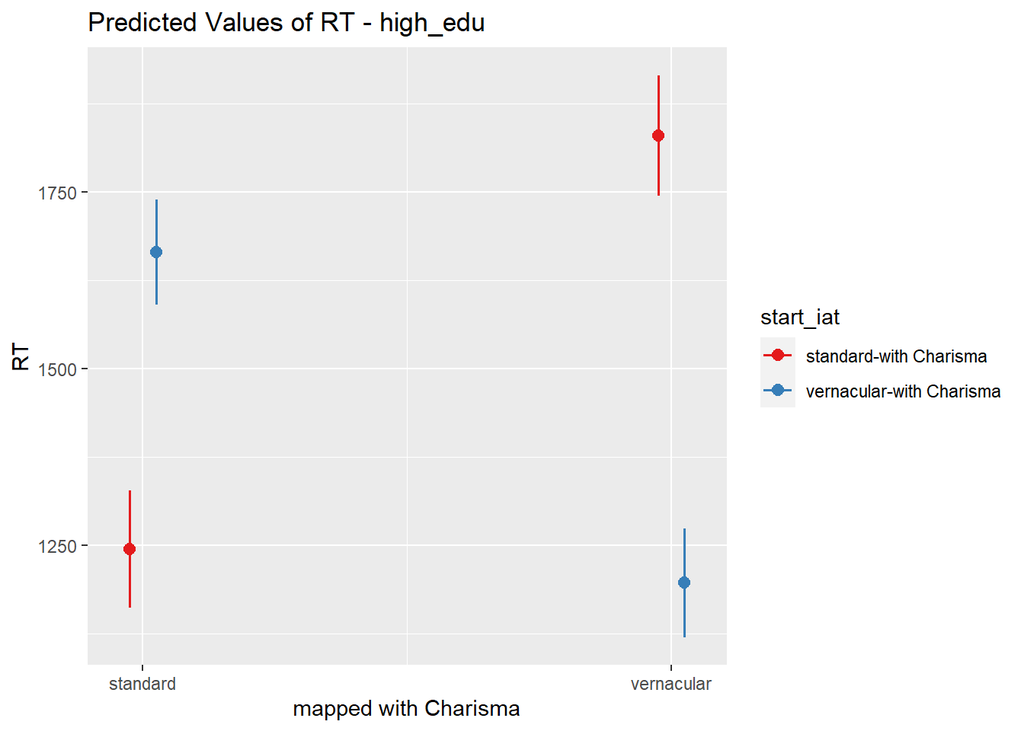

##### Subset: middle education convergence issues no impact of language variety, i.e. no difference in 2nd block

```
## boundary (singular) fit: see help('isSingular')
```

```
## Linear mixed model fit by REML. t-tests use Satterthwaite's method [
## lmerModLmerTest]
## Formula: penal_RTs ~ charisma_lang_var * start_iat + trialcount + age +
##     leadership_lang_var + stim_cat + (charisma_lang_var | bilendi_id) +
##     (start_iat | stimulus_ID)
##    Data: Four_Out_middle_edu
## Control: lmerControl(optimizer = "bobyqa", optCtrl = list(maxfun = 2e+05))
##
## REML criterion at convergence: 283003.6
##
## Scaled residuals:
##     Min      1Q  Median      3Q     Max
## -5.6364 -0.6379 -0.1039  0.5871 12.1213
##
## Random effects:
##  Groups      Name                              Variance Std.Dev. Corr
##  stimulus_ID (Intercept)                            0     0.0
##              start_iatvernacular-with Charisma  12318   111.0     NaN
##  bilendi_id  (Intercept)                       145797   381.8
##              charisma_lang_varvernacular       111171   333.4    0.01
##  Residual                                      305329   552.6
## Number of obs: 18223, groups:  stimulus_ID, 303; bilendi_id, 152
##
## Fixed effects:
##                                                                 Estimate
## (Intercept)                                                    1462.3848
## charisma_lang_varvernacular                                     495.9386
## start_iatvernacular-with Charisma                               497.5087
## trialcount                                                       -5.0524
## age                                                               5.3749
## leadership_lang_var2                                             98.1038
## stim_catleadership                                              148.8694
## charisma_lang_varvernacular:start_iatvernacular-with Charisma  -809.7669
##                                                               Std. Error
## (Intercept)                                                     126.1536
## charisma_lang_varvernacular                                      45.0720
## start_iatvernacular-with Charisma                                67.0723
## trialcount                                                        0.2371
## age                                                               2.1944
## leadership_lang_var2                                             64.6642
```

[output cut: 28 more lines]

```
## charisma_lang_varvernacular:start_iatvernacular-with Charisma ***
## ---
## Signif. codes:  0 '***' 0.001 '**' 0.01 '*' 0.05 '.' 0.1 ' ' 1
##
## Correlation of Fixed Effects:
##             (Intr) chrs__ str_-C trlcnt age    ldr__2 stm_ct
## chrsm_lng_v  0.055
## strt_tvrn-C -0.251  0.165
## trialcount  -0.132 -0.474 -0.318
## age         -0.902  0.000  0.066  0.000
## ldrshp_ln_2 -0.320  0.000  0.022  0.000  0.123
## stm_ctldrsh -0.039  0.001 -0.022 -0.003  0.000 -0.001
## chrsm__:_-C -0.075 -0.779 -0.211  0.602  0.000  0.000 -0.002
## optimizer (bobyqa) convergence code: 0 (OK)
## boundary (singular) fit: see help('isSingular')
```

```
## Type III Analysis of Variance Table with Satterthwaite's method
##                                Sum Sq   Mean Sq NumDF   DenDF  F value
## charisma_lang_var             3167827   3167827     1   149.8  10.3751
## start_iat                      551381    551381     1   149.6   1.8059
## trialcount                  138607500 138607500     1 17818.9 453.9607
## age                           1831722   1831722     1   148.0   5.9992
## leadership_lang_var            702770    702770     1   148.5   2.3017
## stim_cat                     69622247  69622247     1   830.6 228.0235
## charisma_lang_var:start_iat  39900834  39900834     1   368.2 130.6813
##                                Pr(>F)
## charisma_lang_var            0.001567 **
## start_iat                    0.181040
## trialcount                  < 2.2e-16 ***
## age                          0.015480 *
## leadership_lang_var          0.131360
## stim_cat                    < 2.2e-16 ***
## charisma_lang_var:start_iat < 2.2e-16 ***
## ---
## Signif. codes:  0 '***' 0.001 '**' 0.01 '*' 0.05 '.' 0.1 ' ' 1
```

```
## Note: D.f. calculations have been disabled because the number of observations exceeds 3000.
## To enable adjustments, add the argument 'pbkrtest.limit = 18223' (or larger)
## [or, globally, 'set emm_options(pbkrtest.limit = 18223)' or larger];
## but be warned that this may result in large computation time and memory use.
```

```
## Note: D.f. calculations have been disabled because the number of observations exceeds 3000.
## To enable adjustments, add the argument 'lmerTest.limit = 18223' (or larger)
## [or, globally, 'set emm_options(lmerTest.limit = 18223)' or larger];
## but be warned that this may result in large computation time and memory use.
```

```
## $emmeans
##  charisma_lang_var start_iat                emmean   SE  df asymp.LCL asymp.UCL
##  standard          standard-with Charisma     1268 45.9 Inf      1178      1358
##  vernacular        standard-with Charisma     1764 59.9 Inf      1646      1881
##  standard          vernacular-with Charisma   1765 47.2 Inf      1673      1858
##  vernacular        vernacular-with Charisma   1451 61.3 Inf      1331      1571
##
## Results are averaged over the levels of: leadership_lang_var, stim_cat
## Degrees-of-freedom method: asymptotic
## Confidence level used: 0.95
##
## $contrasts
##  contrast
##  (standard standard-with Charisma) - (vernacular standard-with Charisma)
##  (standard standard-with Charisma) - (standard vernacular-with Charisma)
##  (standard standard-with Charisma) - (vernacular vernacular-with Charisma)
##  (vernacular standard-with Charisma) - (standard vernacular-with Charisma)
##  (vernacular standard-with Charisma) - (vernacular vernacular-with Charisma)
##  (standard vernacular-with Charisma) - (vernacular vernacular-with Charisma)
##  estimate   SE  df z.ratio p.value
##   -495.94 45.1 Inf -11.003  <.0001
##   -497.51 67.1 Inf  -7.417  <.0001
##   -183.68 74.6 Inf  -2.461  0.0661
##     -1.57 74.4 Inf  -0.021  1.0000
##    312.26 86.7 Inf   3.603  0.0018
##    313.83 45.6 Inf   6.888  <.0001
##
## Results are averaged over the levels of: leadership_lang_var, stim_cat
## Degrees-of-freedom method: asymptotic
## P value adjustment: tukey method for comparing a family of 4 estimates
```

##### Subset: low education

```
## Linear mixed model fit by REML. t-tests use Satterthwaite's method [
## lmerModLmerTest]
## Formula: penal_RTs ~ charisma_lang_var * start_iat + trialcount + age +
##     leadership_lang_var + stim_cat + (charisma_lang_var | bilendi_id) +
##     (start_iat | stimulus_ID)
##    Data: Four_Out_low_edu
## Control: lmerControl(optimizer = "bobyqa", optCtrl = list(maxfun = 2e+05))
##
## REML criterion at convergence: 60287
##
## Scaled residuals:
##     Min      1Q  Median      3Q     Max
## -3.8023 -0.6564 -0.0805  0.6353 14.6289
##
## Random effects:
##  Groups      Name                              Variance Std.Dev. Corr
##  stimulus_ID (Intercept)                        21679   147.24
##              start_iatvernacular-with Charisma   6601    81.25   -0.90
##  bilendi_id  (Intercept)                        62653   250.31
##              charisma_lang_varvernacular        95953   309.76   -0.04
##  Residual                                      228382   477.89
## Number of obs: 3954, groups:  stimulus_ID, 300; bilendi_id, 33
##
## Fixed effects:
##                                                                 Estimate
## (Intercept)                                                    1941.1662
## charisma_lang_varvernacular                                     642.2933
## start_iatvernacular-with Charisma                               289.3520
## trialcount                                                       -5.0408
## age                                                              -1.9218
## leadership_lang_var2                                            -64.1765
## stim_catleadership                                              153.9444
## charisma_lang_varvernacular:start_iatvernacular-with Charisma -1005.9063
##                                                               Std. Error
## (Intercept)                                                     191.7271
## charisma_lang_varvernacular                                      98.0503
## start_iatvernacular-with Charisma                               110.2097
## trialcount                                                        0.4453
## age                                                               2.8420
## leadership_lang_var2                                            100.3514
```

[output cut: 26 more lines]

```
## leadership_lang_var2
## stim_catleadership                                            ***
## charisma_lang_varvernacular:start_iatvernacular-with Charisma ***
## ---
## Signif. codes:  0 '***' 0.001 '**' 0.01 '*' 0.05 '.' 0.1 ' ' 1
##
## Correlation of Fixed Effects:
##             (Intr) chrs__ str_-C trlcnt age    ldr__2 stm_ct
## chrsm_lng_v  0.038
## strt_tvrn-C -0.445  0.200
## trialcount  -0.164 -0.409 -0.365
## age         -0.905  0.000  0.309  0.001
## ldrshp_ln_2 -0.003  0.000 -0.293  0.000 -0.086
## stm_ctldrsh -0.067 -0.002  0.009  0.000  0.000 -0.004
## chrsm__:_-C -0.074 -0.817 -0.267  0.573  0.001  0.000  0.001
```

```
## Type III Analysis of Variance Table with Satterthwaite's method
##                               Sum Sq  Mean Sq NumDF  DenDF  F value    Pr(>F)
## charisma_lang_var            1344869  1344869     1   31.0   5.8887   0.02126
## start_iat                     805471   805471     1   31.0   3.5269   0.06981
## trialcount                  29266171 29266171     1 3818.8 128.1459 < 2.2e-16
## age                           104433   104433     1   29.0   0.4573   0.50426
## leadership_lang_var            93404    93404     1   29.2   0.4090   0.52748
## stim_cat                    12534987 12534987     1  216.1  54.8861 2.836e-12
## charisma_lang_var:start_iat 11777955 11777955     1   68.4  51.5714 6.505e-10
##
## charisma_lang_var           *
## start_iat                   .
## trialcount                  ***
## age
## leadership_lang_var
## stim_cat                    ***
## charisma_lang_var:start_iat ***
## ---
## Signif. codes:  0 '***' 0.001 '**' 0.01 '*' 0.05 '.' 0.1 ' ' 1
```

```
## Note: D.f. calculations have been disabled because the number of observations exceeds 3000.
## To enable adjustments, add the argument 'pbkrtest.limit = 3954' (or larger)
## [or, globally, 'set emm_options(pbkrtest.limit = 3954)' or larger];
## but be warned that this may result in large computation time and memory use.
```

```
## Note: D.f. calculations have been disabled because the number of observations exceeds 3000.
## To enable adjustments, add the argument 'lmerTest.limit = 3954' (or larger)
## [or, globally, 'set emm_options(lmerTest.limit = 3954)' or larger];
## but be warned that this may result in large computation time and memory use.
```

```
## $emmeans
##  charisma_lang_var start_iat                emmean    SE  df asymp.LCL
##  standard          standard-with Charisma     1298  85.6 Inf      1131
##  vernacular        standard-with Charisma     1941 119.3 Inf      1707
##  standard          vernacular-with Charisma   1588  62.7 Inf      1465
##  vernacular        vernacular-with Charisma   1224  91.8 Inf      1044
##  asymp.UCL
##       1466
##       2174
##       1711
##       1404
##
## Results are averaged over the levels of: leadership_lang_var, stim_cat
## Degrees-of-freedom method: asymptotic
## Confidence level used: 0.95
##
## $contrasts
##  contrast
##  (standard standard-with Charisma) - (vernacular standard-with Charisma)
##  (standard standard-with Charisma) - (standard vernacular-with Charisma)
##  (standard standard-with Charisma) - (vernacular vernacular-with Charisma)
##  (vernacular standard-with Charisma) - (standard vernacular-with Charisma)
##  (vernacular standard-with Charisma) - (vernacular vernacular-with Charisma)
##  (standard vernacular-with Charisma) - (vernacular vernacular-with Charisma)
##  estimate    SE  df z.ratio p.value
##    -642.3  98.1 Inf  -6.551  <.0001
##    -289.4 110.2 Inf  -2.625  0.0430
##      74.3 122.6 Inf   0.606  0.9303
##     352.9 132.1 Inf   2.672  0.0378
##     716.6 153.4 Inf   4.671  <.0001
##     363.6  82.4 Inf   4.413  0.0001
##
## Results are averaged over the levels of: leadership_lang_var, stim_cat
## Degrees-of-freedom method: asymptotic
## P value adjustment: tukey method for comparing a family of 4 estimates
```

##### Subset middle & low education

2nd block non-sig. difference

```
## Linear mixed model fit by REML. t-tests use Satterthwaite's method [
## lmerModLmerTest]
## Formula: penal_RTs ~ charisma_lang_var * start_iat + trialcount + age +
##     leadership_lang_var + stim_cat + (charisma_lang_var | bilendi_id) +
##     (start_iat | stimulus_ID)
##    Data: Four_Out_middle_low_edu
## Control: lmerControl(optimizer = "bobyqa", optCtrl = list(maxfun = 2e+05))
##
## REML criterion at convergence: 343262.7
##
## Scaled residuals:
##     Min      1Q  Median      3Q     Max
## -5.8012 -0.6297 -0.1037  0.5797 13.0225
##
## Random effects:
##  Groups      Name                              Variance Std.Dev. Corr
##  stimulus_ID (Intercept)                         9119    95.50
##              start_iatvernacular-with Charisma   3452    58.75   -0.20
##  bilendi_id  (Intercept)                       134239   366.39
##              charisma_lang_varvernacular       108441   329.30   0.01
##  Residual                                      288202   536.84
## Number of obs: 22177, groups:  stimulus_ID, 303; bilendi_id, 185
##
## Fixed effects:
##                                                                Estimate
## (Intercept)                                                    1562.666
## charisma_lang_varvernacular                                     515.844
## start_iatvernacular-with Charisma                               455.520
## trialcount                                                       -5.043
## age                                                               3.643
## leadership_lang_var2                                             62.301
## stim_catleadership                                              153.206
## charisma_lang_varvernacular:start_iatvernacular-with Charisma  -838.313
##                                                               Std. Error
## (Intercept)                                                      109.240
## charisma_lang_varvernacular                                       40.827
## start_iatvernacular-with Charisma                                 58.431
## trialcount                                                         0.209
## age                                                                1.840
## leadership_lang_var2                                              56.633
```

[output cut: 17 more lines]

```
## leadership_lang_var2                                            0.2727
## stim_catleadership                                             < 2e-16 ***
## charisma_lang_varvernacular:start_iatvernacular-with Charisma  < 2e-16 ***
## ---
## Signif. codes:  0 '***' 0.001 '**' 0.01 '*' 0.05 '.' 0.1 ' ' 1
##
## Correlation of Fixed Effects:
##             (Intr) chrs__ str_-C trlcnt age    ldr__2 stm_ct
## chrsm_lng_v  0.054
## strt_tvrn-C -0.279  0.163
## trialcount  -0.135 -0.461 -0.322
## age         -0.896  0.000  0.095  0.000
## ldrshp_ln_2 -0.289  0.000 -0.021  0.000  0.106
## stm_ctldrsh -0.091  0.001 -0.003 -0.001  0.000 -0.005
## chrsm__:_-C -0.075 -0.785 -0.210  0.597  0.000  0.000 -0.001
```

```
## Type III Analysis of Variance Table with Satterthwaite's method
##                                Sum Sq   Mean Sq NumDF   DenDF  F value
## charisma_lang_var             4214770   4214770     1   182.8  14.6244
## start_iat                      104898    104898     1   180.2   0.3640
## trialcount                  167833703 167833703     1 21616.5 582.3477
## age                           1129098   1129098     1   180.9   3.9177
## leadership_lang_var            348772    348772     1   183.3   1.2102
## stim_cat                     31351602  31351602     1   246.9 108.7835
## charisma_lang_var:start_iat  50992430  50992430     1   440.0 176.9330
##                                Pr(>F)
## charisma_lang_var           0.0001799 ***
## start_iat                   0.5470659
## trialcount                  < 2.2e-16 ***
## age                         0.0492962 *
## leadership_lang_var         0.2727422
## stim_cat                    < 2.2e-16 ***
## charisma_lang_var:start_iat < 2.2e-16 ***
## ---
## Signif. codes:  0 '***' 0.001 '**' 0.01 '*' 0.05 '.' 0.1 ' ' 1
```

```
## Note: D.f. calculations have been disabled because the number of observations exceeds 3000.
## To enable adjustments, add the argument 'pbkrtest.limit = 22177' (or larger)
## [or, globally, 'set emm_options(pbkrtest.limit = 22177)' or larger];
## but be warned that this may result in large computation time and memory use.
```

```
## Note: D.f. calculations have been disabled because the number of observations exceeds 3000.
## To enable adjustments, add the argument 'lmerTest.limit = 22177' (or larger)
## [or, globally, 'set emm_options(lmerTest.limit = 22177)' or larger];
## but be warned that this may result in large computation time and memory use.
```

```
## $emmeans
##  charisma_lang_var start_iat                emmean   SE  df asymp.LCL asymp.UCL
##  standard          standard-with Charisma     1271 41.6 Inf      1190      1353
##  vernacular        standard-with Charisma     1787 54.5 Inf      1680      1894
##  standard          vernacular-with Charisma   1727 40.5 Inf      1648      1806
##  vernacular        vernacular-with Charisma   1404 53.1 Inf      1300      1508
##
## Results are averaged over the levels of: leadership_lang_var, stim_cat
## Degrees-of-freedom method: asymptotic
## Confidence level used: 0.95
##
## $contrasts
##  contrast
##  (standard standard-with Charisma) - (vernacular standard-with Charisma)
##  (standard standard-with Charisma) - (standard vernacular-with Charisma)
##  (standard standard-with Charisma) - (vernacular vernacular-with Charisma)
##  (vernacular standard-with Charisma) - (standard vernacular-with Charisma)
##  (vernacular standard-with Charisma) - (vernacular vernacular-with Charisma)
##  (standard vernacular-with Charisma) - (vernacular vernacular-with Charisma)
##  estimate   SE  df z.ratio p.value
##    -515.8 40.8 Inf -12.635  <.0001
##    -455.5 58.4 Inf  -7.796  <.0001
##    -133.1 65.1 Inf  -2.043  0.1721
##      60.3 65.6 Inf   0.919  0.7945
##     382.8 76.4 Inf   5.010  <.0001
##     322.5 40.0 Inf   8.068  <.0001
##
## Results are averaged over the levels of: leadership_lang_var, stim_cat
## Degrees-of-freedom method: asymptotic
## P value adjustment: tukey method for comparing a family of 4 estimates
```

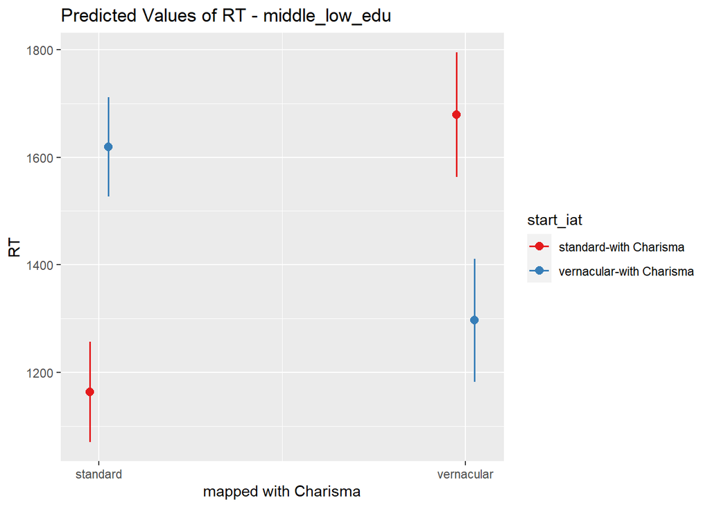

#### Focus sum training ##### Subset: high training no difference of 2nd blocks for no subsets

```
## boundary (singular) fit: see help('isSingular')
```

```
## Linear mixed model fit by REML. t-tests use Satterthwaite's method [
## lmerModLmerTest]
## Formula: penal_RTs ~ charisma_lang_var * start_iat + trialcount + age +
##     leadership_lang_var + stim_cat + (charisma_lang_var | bilendi_id) +
##     (start_iat | stimulus_ID)
##    Data: Four_Out_high_train
## Control: lmerControl(optimizer = "bobyqa", optCtrl = list(maxfun = 2e+05))
##
## REML criterion at convergence: 481904.7
##
## Scaled residuals:
##     Min      1Q  Median      3Q     Max
## -6.2125 -0.6238 -0.1344  0.5517 13.3664
##
## Random effects:
##  Groups      Name                              Variance Std.Dev. Corr
##  stimulus_ID (Intercept)                            0     0.00
##              start_iatvernacular-with Charisma   9647    98.22    NaN
##  bilendi_id  (Intercept)                       125008   353.56
##              charisma_lang_varvernacular       139173   373.06   -0.41
##  Residual                                      343013   585.67
## Number of obs: 30809, groups:  stimulus_ID, 303; bilendi_id, 257
##
## Fixed effects:
##                                                                 Estimate
## (Intercept)                                                    1586.7334
## charisma_lang_varvernacular                                     561.8938
## start_iatvernacular-with Charisma                               457.8610
## trialcount                                                       -5.8118
## age                                                               6.5078
## leadership_lang_var2                                             84.8654
## stim_catleadership                                              119.7413
## charisma_lang_varvernacular:start_iatvernacular-with Charisma  -997.7457
##                                                               Std. Error
## (Intercept)                                                      70.1489
## charisma_lang_varvernacular                                      40.4361
## start_iatvernacular-with Charisma                                49.3335
## trialcount                                                        0.1931
## age                                                               1.2380
## leadership_lang_var2                                             41.5537
```

[output cut: 28 more lines]

```
## charisma_lang_varvernacular:start_iatvernacular-with Charisma ***
## ---
## Signif. codes:  0 '***' 0.001 '**' 0.01 '*' 0.05 '.' 0.1 ' ' 1
##
## Correlation of Fixed Effects:
##             (Intr) chrs__ str_-C trlcnt age    ldr__2 stm_ct
## chrsm_lng_v -0.103
## strt_tvrn-C -0.253  0.417
## trialcount  -0.194 -0.430 -0.352
## age         -0.798  0.000 -0.048  0.000
## ldrshp_ln_2 -0.298  0.000  0.095  0.000  0.005
## stm_ctldrsh -0.061 -0.001 -0.031  0.002  0.000 -0.003
## chrsm__:_-C  0.013 -0.800 -0.524  0.580  0.000  0.000  0.001
## optimizer (bobyqa) convergence code: 0 (OK)
## boundary (singular) fit: see help('isSingular')
```

```
## Type III Analysis of Variance Table with Satterthwaite's method
##                                Sum Sq   Mean Sq NumDF   DenDF  F value
## charisma_lang_var             2289870   2289870     1   254.8   6.6758
## start_iat                      323879    323879     1   263.9   0.9442
## trialcount                  310652431 310652431     1 30171.6 905.6577
## age                           9478639   9478639     1   253.1  27.6335
## leadership_lang_var           1430716   1430716     1   255.1   4.1710
## stim_cat                     67557087  67557087     1  2006.6 196.9519
## charisma_lang_var:start_iat  95161213  95161213     1   578.0 277.4274
##                                Pr(>F)
## charisma_lang_var             0.01033 *
## start_iat                     0.33209
## trialcount                  < 2.2e-16 ***
## age                         3.118e-07 ***
## leadership_lang_var           0.04215 *
## stim_cat                    < 2.2e-16 ***
## charisma_lang_var:start_iat < 2.2e-16 ***
## ---
## Signif. codes:  0 '***' 0.001 '**' 0.01 '*' 0.05 '.' 0.1 ' ' 1
```

```
## Note: D.f. calculations have been disabled because the number of observations exceeds 3000.
## To enable adjustments, add the argument 'pbkrtest.limit = 30809' (or larger)
## [or, globally, 'set emm_options(pbkrtest.limit = 30809)' or larger];
## but be warned that this may result in large computation time and memory use.
```

```
## Note: D.f. calculations have been disabled because the number of observations exceeds 3000.
## To enable adjustments, add the argument 'lmerTest.limit = 30809' (or larger)
## [or, globally, 'set emm_options(lmerTest.limit = 30809)' or larger];
## but be warned that this may result in large computation time and memory use.
```

```
## $emmeans
##  charisma_lang_var start_iat                emmean   SE  df asymp.LCL asymp.UCL
##  standard          standard-with Charisma     1319 35.1 Inf      1250      1388
##  vernacular        standard-with Charisma     1881 38.8 Inf      1805      1957
##  standard          vernacular-with Charisma   1777 32.4 Inf      1713      1840
##  vernacular        vernacular-with Charisma   1341 35.5 Inf      1271      1410
##
## Results are averaged over the levels of: leadership_lang_var, stim_cat
## Degrees-of-freedom method: asymptotic
## Confidence level used: 0.95
##
## $contrasts
##  contrast
##  (standard standard-with Charisma) - (vernacular standard-with Charisma)
##  (standard standard-with Charisma) - (standard vernacular-with Charisma)
##  (standard standard-with Charisma) - (vernacular vernacular-with Charisma)
##  (vernacular standard-with Charisma) - (standard vernacular-with Charisma)
##  (vernacular standard-with Charisma) - (vernacular vernacular-with Charisma)
##  (standard vernacular-with Charisma) - (vernacular vernacular-with Charisma)
##  estimate   SE  df z.ratio p.value
##      -562 40.4 Inf -13.896  <.0001
##      -458 49.3 Inf  -9.281  <.0001
##       -22 48.4 Inf  -0.454  0.9688
##       104 49.0 Inf   2.121  0.1464
##       540 54.1 Inf   9.986  <.0001
##       436 36.7 Inf  11.867  <.0001
##
## Results are averaged over the levels of: leadership_lang_var, stim_cat
## Degrees-of-freedom method: asymptotic
## P value adjustment: tukey method for comparing a family of 4 estimates
```

##### Subset: middle training

```
## boundary (singular) fit: see help('isSingular')
```

```
## Linear mixed model fit by REML. t-tests use Satterthwaite's method [
## lmerModLmerTest]
## Formula: penal_RTs ~ charisma_lang_var * start_iat + trialcount + age +
##     leadership_lang_var + stim_cat + (charisma_lang_var | bilendi_id) +
##     (start_iat | stimulus_ID)
##    Data: Four_Out_middle_train
## Control: lmerControl(optimizer = "bobyqa", optCtrl = list(maxfun = 2e+05))
##
## REML criterion at convergence: 315078.8
##
## Scaled residuals:
##     Min      1Q  Median      3Q     Max
## -6.3795 -0.6377 -0.1180  0.5831 12.5784
##
## Random effects:
##  Groups      Name                              Variance Std.Dev. Corr
##  stimulus_ID (Intercept)                            0     0.00
##              start_iatvernacular-with Charisma   9871    99.35    NaN
##  bilendi_id  (Intercept)                       233568   483.29
##              charisma_lang_varvernacular        83515   288.99   -0.07
##  Residual                                      313228   559.67
## Number of obs: 20256, groups:  stimulus_ID, 303; bilendi_id, 169
##
## Fixed effects:
##                                                                 Estimate
## (Intercept)                                                    1894.6308
## charisma_lang_varvernacular                                     567.5688
## start_iatvernacular-with Charisma                               416.6993
## trialcount                                                       -6.0316
## age                                                               0.8176
## leadership_lang_var2                                             11.3051
## stim_catleadership                                              142.1488
## charisma_lang_varvernacular:start_iatvernacular-with Charisma  -957.1033
##                                                               Std. Error
## (Intercept)                                                     148.0938
## charisma_lang_varvernacular                                      38.7291
## start_iatvernacular-with Charisma                                78.4017
## trialcount                                                        0.2276
## age                                                               2.6245
## leadership_lang_var2                                             76.8720
```

[output cut: 28 more lines]

```
## charisma_lang_varvernacular:start_iatvernacular-with Charisma ***
## ---
## Signif. codes:  0 '***' 0.001 '**' 0.01 '*' 0.05 '.' 0.1 ' ' 1
##
## Correlation of Fixed Effects:
##             (Intr) chrs__ str_-C trlcnt age    ldr__2 stm_ct
## chrsm_lng_v  0.027
## strt_tvrn-C -0.230  0.195
## trialcount  -0.108 -0.529 -0.261
## age         -0.908  0.000  0.037  0.000
## ldrshp_ln_2 -0.306  0.000 -0.053  0.000  0.123
## stm_ctldrsh -0.031  0.002 -0.016 -0.004  0.000 -0.001
## chrsm__:_-C -0.052 -0.793 -0.244  0.656  0.000  0.000 -0.002
## optimizer (bobyqa) convergence code: 0 (OK)
## boundary (singular) fit: see help('isSingular')
```

```
## Type III Analysis of Variance Table with Satterthwaite's method
##                                Sum Sq   Mean Sq NumDF   DenDF  F value
## charisma_lang_var             4455976   4455976     1   166.7  14.2260
## start_iat                      202134    202134     1   167.0   0.6453
## trialcount                  219943368 219943368     1 19808.6 702.1826
## age                             30397     30397     1   165.0   0.0970
## leadership_lang_var              6774      6774     1   165.4   0.0216
## stim_cat                     72990021  72990021     1   347.2 233.0251
## charisma_lang_var:start_iat  73439583  73439583     1   510.2 234.4604
##                                Pr(>F)
## charisma_lang_var           0.0002249 ***
## start_iat                   0.4229307
## trialcount                  < 2.2e-16 ***
## age                         0.7557972
## leadership_lang_var         0.8832611
## stim_cat                    < 2.2e-16 ***
## charisma_lang_var:start_iat < 2.2e-16 ***
## ---
## Signif. codes:  0 '***' 0.001 '**' 0.01 '*' 0.05 '.' 0.1 ' ' 1
```

```
## Note: D.f. calculations have been disabled because the number of observations exceeds 3000.
## To enable adjustments, add the argument 'pbkrtest.limit = 20256' (or larger)
## [or, globally, 'set emm_options(pbkrtest.limit = 20256)' or larger];
## but be warned that this may result in large computation time and memory use.
```

```
## Note: D.f. calculations have been disabled because the number of observations exceeds 3000.
## To enable adjustments, add the argument 'lmerTest.limit = 20256' (or larger)
## [or, globally, 'set emm_options(lmerTest.limit = 20256)' or larger];
## but be warned that this may result in large computation time and memory use.
```

```
## $emmeans
##  charisma_lang_var start_iat                emmean   SE  df asymp.LCL asymp.UCL
##  standard          standard-with Charisma     1315 54.2 Inf      1209      1421
##  vernacular        standard-with Charisma     1883 60.6 Inf      1764      2001
##  standard          vernacular-with Charisma   1732 55.5 Inf      1623      1841
##  vernacular        vernacular-with Charisma   1342 62.2 Inf      1220      1464
##
## Results are averaged over the levels of: leadership_lang_var, stim_cat
## Degrees-of-freedom method: asymptotic
## Confidence level used: 0.95
##
## $contrasts
##  contrast
##  (standard standard-with Charisma) - (vernacular standard-with Charisma)
##  (standard standard-with Charisma) - (standard vernacular-with Charisma)
##  (standard standard-with Charisma) - (vernacular vernacular-with Charisma)
##  (vernacular standard-with Charisma) - (standard vernacular-with Charisma)
##  (vernacular standard-with Charisma) - (vernacular vernacular-with Charisma)
##  (standard vernacular-with Charisma) - (vernacular vernacular-with Charisma)
##  estimate   SE  df z.ratio p.value
##    -567.6 38.7 Inf -14.655  <.0001
##    -416.7 78.4 Inf  -5.315  <.0001
##     -27.2 80.7 Inf  -0.337  0.9869
##     150.9 80.4 Inf   1.877  0.2381
##     540.4 87.5 Inf   6.173  <.0001
##     389.5 39.6 Inf   9.838  <.0001
##
## Results are averaged over the levels of: leadership_lang_var, stim_cat
## Degrees-of-freedom method: asymptotic
## P value adjustment: tukey method for comparing a family of 4 estimates
```

##### Subset: low training summary variable

```
## boundary (singular) fit: see help('isSingular')
```

```
## Linear mixed model fit by REML. t-tests use Satterthwaite's method [
## lmerModLmerTest]
## Formula: penal_RTs ~ charisma_lang_var * start_iat + trialcount + age +
##     leadership_lang_var + stim_cat + (charisma_lang_var | bilendi_id) +
##     (start_iat | stimulus_ID)
##    Data: Four_Out_low_train
## Control: lmerControl(optimizer = "bobyqa", optCtrl = list(maxfun = 2e+05))
##
## REML criterion at convergence: 205762
##
## Scaled residuals:
##     Min      1Q  Median      3Q     Max
## -4.2917 -0.6124 -0.0931  0.5609 11.8843
##
## Random effects:
##  Groups      Name                              Variance Std.Dev. Corr
##  stimulus_ID (Intercept)                            0     0.00
##              start_iatvernacular-with Charisma   9574    97.85    NaN
##  bilendi_id  (Intercept)                       153802   392.18
##              charisma_lang_varvernacular        96059   309.93   -0.10
##  Residual                                      332694   576.80
## Number of obs: 13180, groups:  stimulus_ID, 303; bilendi_id, 110
##
## Fixed effects:
##                                                                 Estimate
## (Intercept)                                                    1648.7360
## charisma_lang_varvernacular                                     553.6844
## start_iatvernacular-with Charisma                               419.5189
## trialcount                                                       -5.3542
## age                                                               4.4212
## leadership_lang_var2                                             68.1833
## stim_catleadership                                              131.7601
## charisma_lang_varvernacular:start_iatvernacular-with Charisma  -968.9904
##                                                               Std. Error
## (Intercept)                                                     113.7250
## charisma_lang_varvernacular                                      54.4734
## start_iatvernacular-with Charisma                                82.2369
## trialcount                                                        0.2913
## age                                                               2.1292
## leadership_lang_var2                                             76.3320
```

[output cut: 28 more lines]

```
## charisma_lang_varvernacular:start_iatvernacular-with Charisma ***
## ---
## Signif. codes:  0 '***' 0.001 '**' 0.01 '*' 0.05 '.' 0.1 ' ' 1
##
## Correlation of Fixed Effects:
##             (Intr) chrs__ str_-C trlcnt age    ldr__2 stm_ct
## chrsm_lng_v  0.026
## strt_tvrn-C -0.385  0.238
## trialcount  -0.180 -0.481 -0.318
## age         -0.793  0.000  0.119  0.000
## ldrshp_ln_2 -0.230  0.000 -0.058  0.000 -0.051
## stm_ctldrsh -0.052  0.001 -0.017 -0.003  0.000  0.000
## chrsm__:_-C -0.075 -0.818 -0.302  0.639  0.000  0.000 -0.002
## optimizer (bobyqa) convergence code: 0 (OK)
## boundary (singular) fit: see help('isSingular')
```

```
## Type III Analysis of Variance Table with Satterthwaite's method
##                                Sum Sq   Mean Sq NumDF   DenDF  F value  Pr(>F)
## charisma_lang_var             1599151   1599151     1   108.0   4.8067 0.03050
## start_iat                      219086    219086     1   106.9   0.6585 0.41889
## trialcount                  112432681 112432681     1 12884.2 337.9466 < 2e-16
## age                           1434468   1434468     1   105.9   4.3117 0.04027
## leadership_lang_var            265453    265453     1   106.2   0.7979 0.37374
## stim_cat                     40620133  40620133     1   319.0 122.0947 < 2e-16
## charisma_lang_var:start_iat  46406614  46406614     1   307.1 139.4876 < 2e-16
##
## charisma_lang_var           *
## start_iat
## trialcount                  ***
## age                         *
## leadership_lang_var
## stim_cat                    ***
## charisma_lang_var:start_iat ***
## ---
## Signif. codes:  0 '***' 0.001 '**' 0.01 '*' 0.05 '.' 0.1 ' ' 1
```

```
## Note: D.f. calculations have been disabled because the number of observations exceeds 3000.
## To enable adjustments, add the argument 'pbkrtest.limit = 13180' (or larger)
## [or, globally, 'set emm_options(pbkrtest.limit = 13180)' or larger];
## but be warned that this may result in large computation time and memory use.
```

```
## Note: D.f. calculations have been disabled because the number of observations exceeds 3000.
## To enable adjustments, add the argument 'lmerTest.limit = 13180' (or larger)
## [or, globally, 'set emm_options(lmerTest.limit = 13180)' or larger];
## but be warned that this may result in large computation time and memory use.
```

```
## $emmeans
##  charisma_lang_var start_iat                emmean   SE  df asymp.LCL asymp.UCL
##  standard          standard-with Charisma     1310 60.4 Inf      1191      1428
##  vernacular        standard-with Charisma     1863 71.9 Inf      1722      2004
##  standard          vernacular-with Charisma   1729 52.6 Inf      1626      1832
##  vernacular        vernacular-with Charisma   1314 62.5 Inf      1191      1436
##
## Results are averaged over the levels of: leadership_lang_var, stim_cat
## Degrees-of-freedom method: asymptotic
## Confidence level used: 0.95
##
## $contrasts
##  contrast
##  (standard standard-with Charisma) - (vernacular standard-with Charisma)
##  (standard standard-with Charisma) - (standard vernacular-with Charisma)
##  (standard standard-with Charisma) - (vernacular vernacular-with Charisma)
##  (vernacular standard-with Charisma) - (standard vernacular-with Charisma)
##  (vernacular standard-with Charisma) - (vernacular vernacular-with Charisma)
##  (standard vernacular-with Charisma) - (vernacular vernacular-with Charisma)
##  estimate   SE  df z.ratio p.value
##   -553.68 54.5 Inf -10.164  <.0001
##   -419.52 82.2 Inf  -5.101  <.0001
##     -4.21 84.9 Inf  -0.050  1.0000
##    134.17 87.2 Inf   1.539  0.4141
##    549.47 97.1 Inf   5.660  <.0001
##    415.31 48.9 Inf   8.495  <.0001
##
## Results are averaged over the levels of: leadership_lang_var, stim_cat
## Degrees-of-freedom method: asymptotic
## P value adjustment: tukey method for comparing a family of 4 estimates
```

##### Subset: middle & low training

```
## Linear mixed model fit by REML. t-tests use Satterthwaite's method [
## lmerModLmerTest]
## Formula: penal_RTs ~ charisma_lang_var * start_iat + trialcount + age +
##     leadership_lang_var + stim_cat + (charisma_lang_var | bilendi_id) +
##     (start_iat | stimulus_ID)
##    Data: Four_Out_middle_low_train
## Control: lmerControl(optimizer = "bobyqa", optCtrl = list(maxfun = 2e+05))
##
## REML criterion at convergence: 520526.4
##
## Scaled residuals:
##     Min      1Q  Median      3Q     Max
## -6.1195 -0.6222 -0.1084  0.5615 12.4420
##
## Random effects:
##  Groups      Name                              Variance Std.Dev. Corr
##  stimulus_ID (Intercept)                         8957.2  94.64
##              start_iatvernacular-with Charisma    557.6  23.61   -0.38
##  bilendi_id  (Intercept)                       200255.4 447.50
##              charisma_lang_varvernacular        88891.0 298.15   -0.08
##  Residual                                      316575.6 562.65
## Number of obs: 33436, groups:  stimulus_ID, 303; bilendi_id, 279
##
## Fixed effects:
##                                                                 Estimate
## (Intercept)                                                    1764.6873
## charisma_lang_varvernacular                                     557.2030
## start_iatvernacular-with Charisma                               412.8259
## trialcount                                                       -5.7330
## age                                                               2.5782
## leadership_lang_var2                                             41.4633
## stim_catleadership                                              145.3495
## charisma_lang_varvernacular:start_iatvernacular-with Charisma  -957.2347
##                                                               Std. Error
## (Intercept)                                                      92.8457
## charisma_lang_varvernacular                                      31.6189
## start_iatvernacular-with Charisma                                57.0103
## trialcount                                                        0.1781
## age                                                               1.6552
## leadership_lang_var2                                             55.0092
```

[output cut: 26 more lines]

```
## leadership_lang_var2
## stim_catleadership                                            ***
## charisma_lang_varvernacular:start_iatvernacular-with Charisma ***
## ---
## Signif. codes:  0 '***' 0.001 '**' 0.01 '*' 0.05 '.' 0.1 ' ' 1
##
## Correlation of Fixed Effects:
##             (Intr) chrs__ str_-C trlcnt age    ldr__2 stm_ct
## chrsm_lng_v  0.029
## strt_tvrn-C -0.319  0.207
## trialcount  -0.135 -0.507 -0.281
## age         -0.858  0.000  0.092  0.000
## ldrshp_ln_2 -0.272  0.000 -0.053  0.000  0.049
## stm_ctldrsh -0.105  0.001  0.004 -0.001  0.000 -0.003
## chrsm__:_-C -0.062 -0.802 -0.261  0.647  0.000  0.000 -0.001
```

```
## Type III Analysis of Variance Table with Satterthwaite's method
##                                Sum Sq   Mean Sq NumDF DenDF   F value    Pr(>F)
## charisma_lang_var             5471849   5471849     1   277   17.2845 4.296e-05
## start_iat                      438248    438248     1   275    1.3843    0.2404
## trialcount                  328124922 328124922     1 32681 1036.4819 < 2.2e-16
## age                            768051    768051     1   275    2.4261    0.1205
## leadership_lang_var            179859    179859     1   278    0.5681    0.4516
## stim_cat                     35538896  35538896     1   249  112.2604 < 2.2e-16
## charisma_lang_var:start_iat 118082658 118082658     1   814  372.9998 < 2.2e-16
##
## charisma_lang_var           ***
## start_iat
## trialcount                  ***
## age
## leadership_lang_var
## stim_cat                    ***
## charisma_lang_var:start_iat ***
## ---
## Signif. codes:  0 '***' 0.001 '**' 0.01 '*' 0.05 '.' 0.1 ' ' 1
```

```
## Note: D.f. calculations have been disabled because the number of observations exceeds 3000.
## To enable adjustments, add the argument 'pbkrtest.limit = 33436' (or larger)
## [or, globally, 'set emm_options(pbkrtest.limit = 33436)' or larger];
## but be warned that this may result in large computation time and memory use.
```

```
## Note: D.f. calculations have been disabled because the number of observations exceeds 3000.
## To enable adjustments, add the argument 'lmerTest.limit = 33436' (or larger)
## [or, globally, 'set emm_options(lmerTest.limit = 33436)' or larger];
## but be warned that this may result in large computation time and memory use.
```

```
## $emmeans
##  charisma_lang_var start_iat                emmean   SE  df asymp.LCL asymp.UCL
##  standard          standard-with Charisma     1314 41.0 Inf      1234      1395
##  vernacular        standard-with Charisma     1871 46.8 Inf      1780      1963
##  standard          vernacular-with Charisma   1727 39.2 Inf      1650      1804
##  vernacular        vernacular-with Charisma   1327 44.8 Inf      1239      1415
##
## Results are averaged over the levels of: leadership_lang_var, stim_cat
## Degrees-of-freedom method: asymptotic
## Confidence level used: 0.95
##
## $contrasts
##  contrast
##  (standard standard-with Charisma) - (vernacular standard-with Charisma)
##  (standard standard-with Charisma) - (standard vernacular-with Charisma)
##  (standard standard-with Charisma) - (vernacular vernacular-with Charisma)
##  (vernacular standard-with Charisma) - (standard vernacular-with Charisma)
##  (vernacular standard-with Charisma) - (vernacular vernacular-with Charisma)
##  (standard vernacular-with Charisma) - (vernacular vernacular-with Charisma)
##  estimate   SE  df z.ratio p.value
##    -557.2 31.6 Inf -17.622  <.0001
##    -412.8 57.0 Inf  -7.241  <.0001
##     -12.8 58.9 Inf  -0.217  0.9964
##     144.4 59.2 Inf   2.439  0.0699
##     544.4 65.1 Inf   8.369  <.0001
##     400.0 30.7 Inf  13.026  <.0001
##
## Results are averaged over the levels of: leadership_lang_var, stim_cat
## Degrees-of-freedom method: asymptotic
## P value adjustment: tukey method for comparing a family of 4 estimates
```

## 2.6. SES & Populism

### all data

Impact of language variety in high education subset might be due to correlation of education with populism. -> sum_education/ sum_training positive slopes: the lower educated the higher populism scores, biggest difference between high and middle educated -> income less clear pattern

```
##  [1] "Bundesfreiwilligendienst, Freiwilliges Soziales Jahr (FSJ), Freiwilliges Ökologisches Jahr (FÖJ)"
##  [2] "geringfügig erwerbstätig, 450-Euro-Job, Minijob"
##  [3] "in Mutterschutz, Elternzeit"
##  [4] "Lehrling/Azubi"
##  [5] "nicht berufstätig (Hausfrau/Hausmann)"
##  [6] "Pensionär/in, Rentner/in (früher berufstätig)"
##  [7] "Schüler/in"
##  [8] "Student/in"
##  [9] "Teilzeit berufstätig (bis 30 Stunden/Woche)"
## [10] "Vollzeit berufstätig (mehr als 30 Stunden/Woche)"
## [11] "zurzeit arbeitslos"
```

```
##  [1] "1000 bis unter 1250 Euro"       "10000 Euro und mehr"
##  [3] "1250 bis unter 1500 Euro"       "1500 bis unter 2000 Euro"
##  [5] "2000 bis unter 2500 Euro"       "2500 bis unter 3000 Euro"
##  [7] "3000 bis unter 4000 Euro"       "4000 bis unter 5000 Euro"
##  [9] "500 bis unter 750 Euro"         "5000 bis unter 7500 Euro"
## [11] "750 bis unter 1000 Euro"        "7500 bis unter 10000 Euro"
## [13] "möchte Frage nicht beantworten" "unter 500 Euro"
## [15] "weiß nicht"
```

```
##
## Call:
## lm(formula = populism_all ~ sum_education + sum_training + employment_status +
##     monthly_income, data = Four_Out)
##
## Residuals:
##      Min       1Q   Median       3Q      Max
## -2.91412 -0.61819  0.06176  0.61288  2.36576
##
## Coefficients:
##                                                                                                                    Estimate
## (Intercept)                                                                                                        0.175841
## sum_educationlow                                                                                                   0.340368
## sum_educationmiddle                                                                                                0.398038
## sum_educationother                                                                                                 1.173134
## sum_educationstill at school                                                                                      -0.646486
## sum_traininghigh                                                                                                  -0.171047
## sum_traininglow                                                                                                   -0.034453
## employment_statusBundesfreiwilligendienst, Freiwilliges Soziales Jahr (FSJ), Freiwilliges Ökologisches Jahr (FÖJ) -1.158912
## employment_statusgeringfügig erwerbstätig, 450-Euro-Job, Minijob                                                  -0.509327
## employment_statusin Mutterschutz, Elternzeit                                                                       0.807036
## employment_statusLehrling/Azubi                                                                                   -0.639005
## employment_statusnicht berufstätig (Hausfrau/Hausmann)                                                            -0.540983
## employment_statusPensionär/in, Rentner/in (früher berufstätig)                                                    -0.153425
## employment_statusSchüler/in                                                                                        0.459813
## employment_statusStudent/in                                                                                        0.006661
## employment_statusTeilzeit berufstätig (bis 30 Stunden/Woche)                                                      -0.141926
## employment_statuszurzeit arbeitslos                                                                               -0.101383
## monthly_income1000 bis unter 1250 Euro                                                                             0.008589
## monthly_income10000 Euro und mehr                                                                                 -0.616642
## monthly_income1250 bis unter 1500 Euro                                                                            -0.048711
## monthly_income1500 bis unter 2000 Euro                                                                            -0.168825
## monthly_income2000 bis unter 2500 Euro                                                                            -0.139390
## monthly_income2500 bis unter 3000 Euro                                                                            -0.117333
## monthly_income3000 bis unter 4000 Euro                                                                            -0.192401
## monthly_income4000 bis unter 5000 Euro                                                                            -0.087493
## monthly_income500 bis unter 750 Euro                                                                               0.041760
## monthly_income5000 bis unter 7500 Euro                                                                            -0.379129
## monthly_income750 bis unter 1000 Euro                                                                             -0.109904
## monthly_income7500 bis unter 10000 Euro                                                                           -0.022476
```

[output cut: 122 more lines]

```
## monthly_income3000 bis unter 4000 Euro                                                                            ***
## monthly_income4000 bis unter 5000 Euro                                                                            **
## monthly_income500 bis unter 750 Euro
## monthly_income5000 bis unter 7500 Euro                                                                            ***
## monthly_income750 bis unter 1000 Euro                                                                             **
## monthly_income7500 bis unter 10000 Euro
## monthly_incomemöchte Frage nicht beantworten                                                                      *
## monthly_incomeweiß nicht                                                                                          ***
## ---
## Signif. codes:  0 '***' 0.001 '**' 0.01 '*' 0.05 '.' 0.1 ' ' 1
##
## Residual standard error: 0.947 on 64214 degrees of freedom
##   (120 Beobachtungen als fehlend gelöscht)
## Multiple R-squared:  0.09445,    Adjusted R-squared:  0.09403
## F-statistic: 223.2 on 30 and 64214 DF,  p-value: < 2.2e-16
```

```
## Analysis of Variance Table
##
## Response: populism_all
##                      Df Sum Sq Mean Sq F value    Pr(>F)
## sum_education         4   3337  834.37 930.468 < 2.2e-16 ***
## sum_training          2    376  187.93 209.577 < 2.2e-16 ***
## employment_status    10   1393  139.34 155.387 < 2.2e-16 ***
## monthly_income       14    899   64.22  71.614 < 2.2e-16 ***
## Residuals         64214  57582    0.90
## ---
## Signif. codes:  0 '***' 0.001 '**' 0.01 '*' 0.05 '.' 0.1 ' ' 1
```

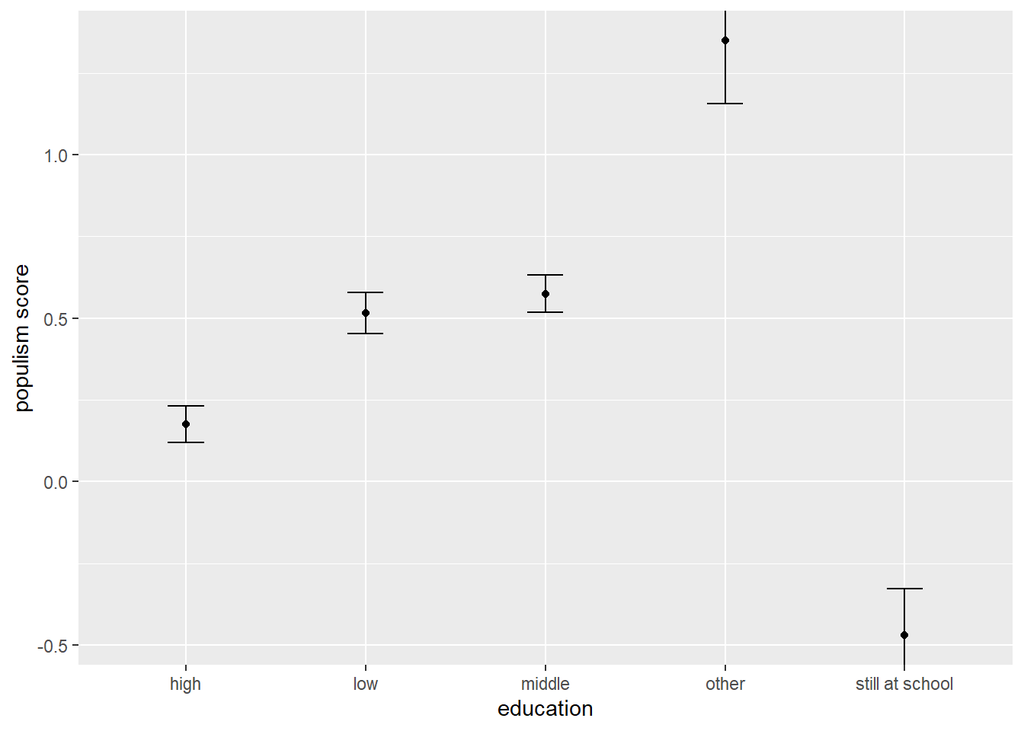

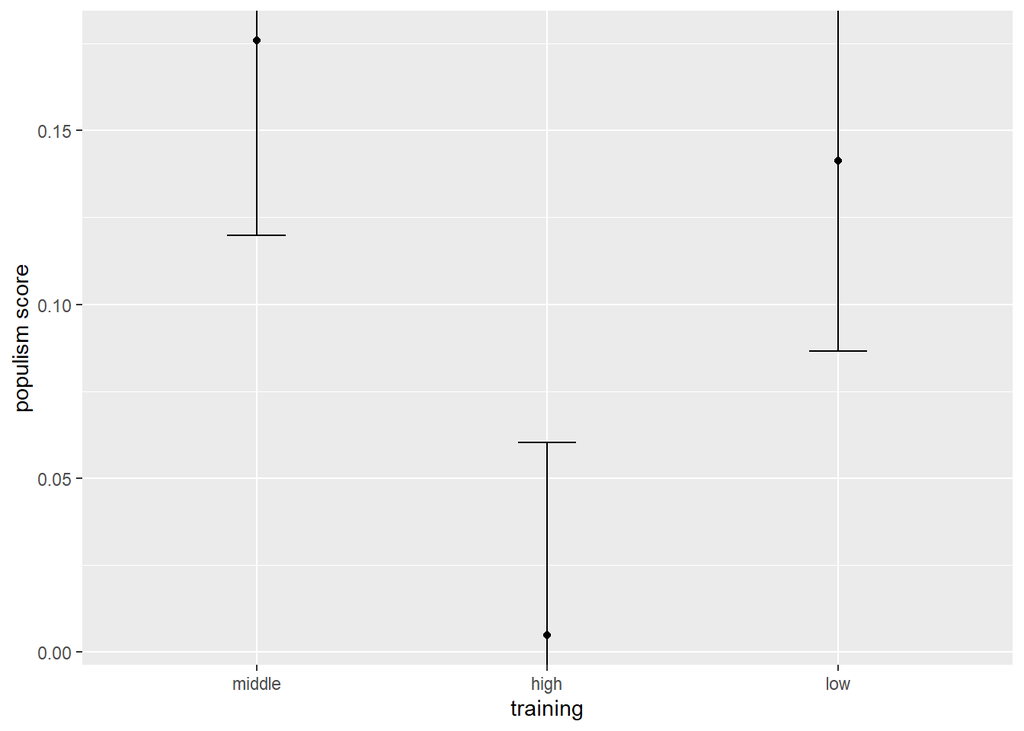

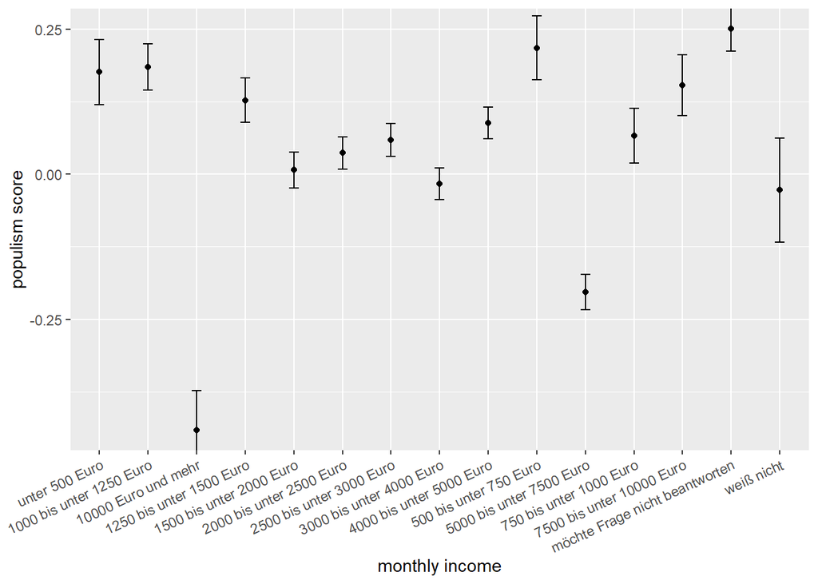

## 2.7. MC Social Desirebility SCale Interaction charisma_lang_var standard:start_iat standard-with Charisma:score_MCSD sig. and negative => the stronger the socially desirable behaviour the stronger the association of standard & charisma (standard language ideology?)

```
## Linear mixed model fit by REML. t-tests use Satterthwaite's method [
## lmerModLmerTest]
## Formula: penal_RTs ~ charisma_lang_var:start_iat:score_MCSD + trialcount +
##     age + leadership_lang_var + stim_cat + (charisma_lang_var |
##     bilendi_id) + (1 | stimulus_ID)
##    Data: Four_Out
## Control: lmerControl(optimizer = "bobyqa", optCtrl = list(maxfun = 2e+05))
##
## REML criterion at convergence: 1004416
##
## Scaled residuals:
##     Min      1Q  Median      3Q     Max
## -6.4072 -0.6194 -0.1248  0.5484 13.4635
##
## Random effects:
##  Groups      Name                        Variance Std.Dev. Corr
##  bilendi_id  (Intercept)                 190930   436.96
##              charisma_lang_varvernacular 258559   508.49   -0.43
##  stimulus_ID (Intercept)                   8221    90.67
##  Residual                                327624   572.38
## Number of obs: 64365, groups:  bilendi_id, 537; stimulus_ID, 303
##
## Fixed effects:
##                                                                           Estimate
## (Intercept)                                                              1996.9900
## trialcount                                                                 -4.6202
## age                                                                        83.7285
## leadership_lang_var2                                                       61.7678
## stim_catleadership                                                        135.0048
## charisma_lang_varstandard:start_iatstandard-with Charisma:score_MCSD      -57.1645
## charisma_lang_varvernacular:start_iatstandard-with Charisma:score_MCSD     40.3457
## charisma_lang_varstandard:start_iatvernacular-with Charisma:score_MCSD    -12.3376
## charisma_lang_varvernacular:start_iatvernacular-with Charisma:score_MCSD   18.8027
##                                                                          Std. Error
## (Intercept)                                                                 28.7308
## trialcount                                                                   0.1153
## age                                                                         17.8907
## leadership_lang_var2                                                        35.0985
## stim_catleadership                                                          13.0687
## charisma_lang_varstandard:start_iatstandard-with Charisma:score_MCSD        28.7188
```

[output cut: 68 more lines]

```
## ldrshp_ln_2
## stm_ctldrsh
## chrsm_lng_vrstndrd:strt_ts-C:_MCSD
## chrsm_lng_vrvrnclr:strt_ts-C:_MCSD
## chrsm_lng_vrstndrd:strt_tv-C:_MCSD  0.023
## chrsm_lng_vrvrnclr:strt_tv-C:_MCSD  0.020
##                                    chrsm_lng_vrstndrd:strt_tv-C:_MCSD
## trialcount
## age
## ldrshp_ln_2
## stm_ctldrsh
## chrsm_lng_vrstndrd:strt_ts-C:_MCSD
## chrsm_lng_vrvrnclr:strt_ts-C:_MCSD
## chrsm_lng_vrstndrd:strt_tv-C:_MCSD
## chrsm_lng_vrvrnclr:strt_tv-C:_MCSD  0.433
```

```
## Type III Analysis of Variance Table with Satterthwaite's method
##                                           Sum Sq   Mean Sq NumDF  DenDF
## trialcount                             525862695 525862695     1 8051.8
## age                                      7175724   7175724     1  531.8
## leadership_lang_var                      1014669   1014669     1  541.7
## stim_cat                                34963263  34963263     1  263.4
## charisma_lang_var:start_iat:score_MCSD   3441248    860312     4  468.2
##                                          F value    Pr(>F)
## trialcount                             1605.0793 < 2.2e-16 ***
## age                                      21.9023 3.645e-06 ***
## leadership_lang_var                       3.0971   0.07900 .
## stim_cat                                106.7176 < 2.2e-16 ***
## charisma_lang_var:start_iat:score_MCSD    2.6259   0.03406 *
## ---
## Signif. codes:  0 '***' 0.001 '**' 0.01 '*' 0.05 '.' 0.1 ' ' 1
```

```
## Note: D.f. calculations have been disabled because the number of observations exceeds 3000.
## To enable adjustments, add the argument 'pbkrtest.limit = 64365' (or larger)
## [or, globally, 'set emm_options(pbkrtest.limit = 64365)' or larger];
## but be warned that this may result in large computation time and memory use.
```

```
## Note: D.f. calculations have been disabled because the number of observations exceeds 3000.
## To enable adjustments, add the argument 'lmerTest.limit = 64365' (or larger)
## [or, globally, 'set emm_options(lmerTest.limit = 64365)' or larger];
## but be warned that this may result in large computation time and memory use.
```

```
## start_iat = standard-with Charisma:
##  charisma_lang_var score_MCSD.trend   SE  df asymp.LCL asymp.UCL
##  standard                     -57.2 28.7 Inf    -113.5    -0.877
##  vernacular                    40.3 33.2 Inf     -24.7   105.347
##
## start_iat = vernacular-with Charisma:
##  charisma_lang_var score_MCSD.trend   SE  df asymp.LCL asymp.UCL
##  standard                     -12.3 26.5 Inf     -64.3    39.642
##  vernacular                    18.8 30.7 Inf     -41.4    79.031
##
## Results are averaged over the levels of: leadership_lang_var, stim_cat
## Degrees-of-freedom method: asymptotic
## Confidence level used: 0.95
```

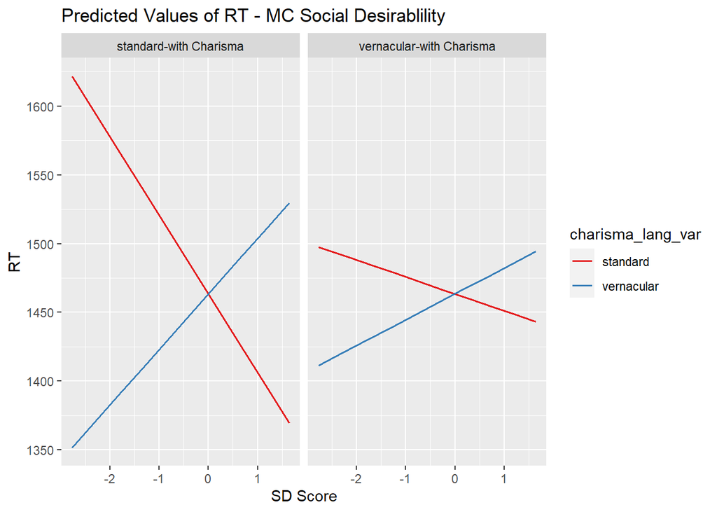

# 4. Ingroup convergence issues, 2nd block diff. Hochdeutsch Dialect-w/oCharisma) - (Dialekt Hochdeutsch-w/oCharisma not sign, 1st block neither

```
## Linear mixed model fit by REML. t-tests use Satterthwaite's method [
## lmerModLmerTest]
## Formula: penal_RTs ~ charisma_lang_var * start_iat + trialcount + age +
##     (1 | bilendi_id) + (1 | stimulus_ID)
##    Data: Four_In
## Control: lmerControl(optimizer = "bobyqa", optCtrl = list(maxfun = 2e+05))
##
## REML criterion at convergence: 68527.6
##
## Scaled residuals:
##     Min      1Q  Median      3Q     Max
## -2.5081 -0.6194 -0.1732  0.4721  7.5383
##
## Random effects:
##  Groups      Name        Variance Std.Dev.
##  stimulus_ID (Intercept)  31166   176.5
##  bilendi_id  (Intercept)  81401   285.3
##  Residual                434217   659.0
## Number of obs: 4316, groups:  stimulus_ID, 301; bilendi_id, 36
##
## Fixed effects:
##                                                                 Estimate
## (Intercept)                                                    1944.0118
## charisma_lang_varvernacular                                     628.6198
## start_iatvernacular-with Charisma                               637.5670
## trialcount                                                       -5.3698
## age                                                             180.1340
## charisma_lang_varvernacular:start_iatvernacular-with Charisma -1086.5480
##                                                               Std. Error
## (Intercept)                                                      79.3470
## charisma_lang_varvernacular                                      59.3109
## start_iatvernacular-with Charisma                               113.7212
## trialcount                                                        0.5843
## age                                                              49.0303
## charisma_lang_varvernacular:start_iatvernacular-with Charisma   112.8716
##                                                                       df
## (Intercept)                                                      70.8468
## charisma_lang_varvernacular                                    4173.6160
## start_iatvernacular-with Charisma                                58.2270
## trialcount                                                     4145.3909
```

[output cut: 11 more lines]

```
## charisma_lang_varvernacular                                   ***
## start_iatvernacular-with Charisma                             ***
## trialcount                                                    ***
## age                                                           ***
## charisma_lang_varvernacular:start_iatvernacular-with Charisma ***
## ---
## Signif. codes:  0 '***' 0.001 '**' 0.01 '*' 0.05 '.' 0.1 ' ' 1
##
## Correlation of Fixed Effects:
##             (Intr) chrs__ str_-C trlcnt age
## chrsm_lng_v  0.380
## strt_tvrn-C -0.261  0.466
## trialcount  -0.519 -0.887 -0.462
## age          0.065  0.000 -0.102  0.000
## chrsm__:_-C -0.441 -0.938 -0.497  0.931  0.000
```

```
## Note: D.f. calculations have been disabled because the number of observations exceeds 3000.
## To enable adjustments, add the argument 'pbkrtest.limit = 4316' (or larger)
## [or, globally, 'set emm_options(pbkrtest.limit = 4316)' or larger];
## but be warned that this may result in large computation time and memory use.
```

```
## Note: D.f. calculations have been disabled because the number of observations exceeds 3000.
## To enable adjustments, add the argument 'lmerTest.limit = 4316' (or larger)
## [or, globally, 'set emm_options(lmerTest.limit = 4316)' or larger];
## but be warned that this may result in large computation time and memory use.
```

```
## $emmeans
##  charisma_lang_var start_iat                emmean   SE  df asymp.LCL asymp.UCL
##  standard          standard-with Charisma     1324 72.8 Inf      1181      1466
##  vernacular        standard-with Charisma     1952 72.7 Inf      1810      2095
##  standard          vernacular-with Charisma   1961 80.1 Inf      1804      2118
##  vernacular        vernacular-with Charisma   1503 80.2 Inf      1346      1660
##
## Degrees-of-freedom method: asymptotic
## Confidence level used: 0.95
##
## $contrasts
##  contrast
##  (standard standard-with Charisma) - (vernacular standard-with Charisma)
##  (standard standard-with Charisma) - (standard vernacular-with Charisma)
##  (standard standard-with Charisma) - (vernacular vernacular-with Charisma)
##  (vernacular standard-with Charisma) - (standard vernacular-with Charisma)
##  (vernacular standard-with Charisma) - (vernacular vernacular-with Charisma)
##  (standard vernacular-with Charisma) - (vernacular vernacular-with Charisma)
##  estimate    SE  df z.ratio p.value
##   -628.62  59.3 Inf -10.599  <.0001
##   -637.57 113.7 Inf  -5.606  <.0001
##   -179.64 100.8 Inf  -1.781  0.2823
##     -8.95 100.8 Inf  -0.089  0.9997
##    448.98 113.7 Inf   3.949  0.0005
##    457.93  60.8 Inf   7.532  <.0001
##
## Degrees-of-freedom method: asymptotic
## P value adjustment: tukey method for comparing a family of 4 estimates
```

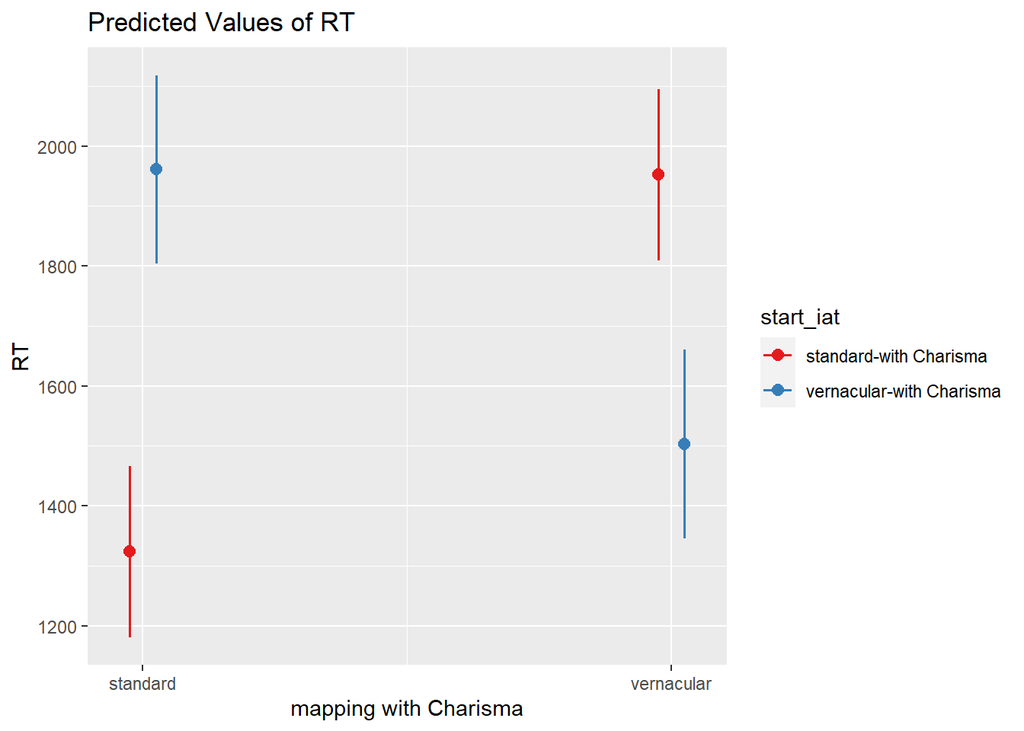